# SICVIR: variables presentes en comunas

### Quinta De Tilcoco

*Mixta*

Variables presentes: 9 de 9

Porcentaje de variables presentes: 100%

| bs03 | Tiempo mediano en minutos al recinto de educación básica más cercano | 2021 |
| --- | --- | --- |
| bs04 | Tiempo mediano en minutos al recinto de educación media más cercano | 2021 |
| bs07 | Tiempo mediano en minutos al hospital o clínica más cercana | 2021 |
| bs10 | Tiempo mediano en minutos al cuartel de Carabineros más cercano | 2018 |
| bs12 | Porcentaje de viviendas particulares no conectadas a la red de agua potable | 2017 |
| bs21 | Tiempo mediano en minutos al centro de salud primaria más cercano | 2021 |
| ci04 | Porcentaje de viviendas particulares con cobertura de radiodifusión comunitaria ciudadana | 2021 |
| ci06 | Número de espacios culturales por cada 1.000 habitantes | 2021 |
| sm03 | Cantidad de residuos eliminados con disposición final per cápita | 2022 |

### Rengo

*Urbana*

Variables presentes: 9 de 9

Porcentaje de variables presentes: 100%

| bs03 | Tiempo mediano en minutos al recinto de educación básica más cercano | 2021 |
| --- | --- | --- |
| bs04 | Tiempo mediano en minutos al recinto de educación media más cercano | 2021 |
| bs07 | Tiempo mediano en minutos al hospital o clínica más cercana | 2021 |
| bs10 | Tiempo mediano en minutos al cuartel de Carabineros más cercano | 2018 |
| bs12 | Porcentaje de viviendas particulares no conectadas a la red de agua potable | 2017 |
| bs21 | Tiempo mediano en minutos al centro de salud primaria más cercano | 2021 |
| ci04 | Porcentaje de viviendas particulares con cobertura de radiodifusión comunitaria ciudadana | 2021 |
| ci06 | Número de espacios culturales por cada 1.000 habitantes | 2021 |
| sm03 | Cantidad de residuos eliminados con disposición final per cápita | 2022 |

### Requínoa

*Mixta*

Variables presentes: 8 de 9

Porcentaje de variables presentes: 89%

| bs03 | Tiempo mediano en minutos al recinto de educación básica más cercano | 2021 |
| --- | --- | --- |
| bs04 | Tiempo mediano en minutos al recinto de educación media más cercano | 2021 |
| bs07 | Tiempo mediano en minutos al hospital o clínica más cercana | 2021 |
| bs10 | Tiempo mediano en minutos al cuartel de Carabineros más cercano | 2018 |
| bs12 | Porcentaje de viviendas particulares no conectadas a la red de agua potable | 2017 |
| bs21 | Tiempo mediano en minutos al centro de salud primaria más cercano | 2021 |
| ci04 | Porcentaje de viviendas particulares con cobertura de radiodifusión comunitaria ciudadana | 2021 |
| ci06 | Número de espacios culturales por cada 1.000 habitantes | 2021 |
| sm03 | Cantidad de residuos eliminados con disposición final per cápita | 2022 |

### San Vicente

*Mixta*

Variables presentes: 9 de 9

Porcentaje de variables presentes: 100%

| bs03 | Tiempo mediano en minutos al recinto de educación básica más cercano | 2021 |
| --- | --- | --- |
| bs04 | Tiempo mediano en minutos al recinto de educación media más cercano | 2021 |
| bs07 | Tiempo mediano en minutos al hospital o clínica más cercana | 2021 |
| bs10 | Tiempo mediano en minutos al cuartel de Carabineros más cercano | 2018 |
| bs12 | Porcentaje de viviendas particulares no conectadas a la red de agua potable | 2017 |
| bs21 | Tiempo mediano en minutos al centro de salud primaria más cercano | 2021 |
| ci04 | Porcentaje de viviendas particulares con cobertura de radiodifusión comunitaria ciudadana | 2021 |
| ci06 | Número de espacios culturales por cada 1.000 habitantes | 2021 |
| sm03 | Cantidad de residuos eliminados con disposición final per cápita | 2022 |

### Pichilemu

*Rural*

Variables presentes: 9 de 9

Porcentaje de variables presentes: 100%

| bs03 | Tiempo mediano en minutos al recinto de educación básica más cercano | 2021 |
| --- | --- | --- |
| bs04 | Tiempo mediano en minutos al recinto de educación media más cercano | 2021 |
| bs07 | Tiempo mediano en minutos al hospital o clínica más cercana | 2021 |
| bs10 | Tiempo mediano en minutos al cuartel de Carabineros más cercano | 2018 |
| bs12 | Porcentaje de viviendas particulares no conectadas a la red de agua potable | 2017 |
| bs21 | Tiempo mediano en minutos al centro de salud primaria más cercano | 2021 |
| ci04 | Porcentaje de viviendas particulares con cobertura de radiodifusión comunitaria ciudadana | 2021 |
| ci06 | Número de espacios culturales por cada 1.000 habitantes | 2021 |
| sm03 | Cantidad de residuos eliminados con disposición final per cápita | 2022 |

### La Estrella

*Rural*

Variables presentes: 9 de 9

Porcentaje de variables presentes: 100%

| bs03 | Tiempo mediano en minutos al recinto de educación básica más cercano | 2021 |
| --- | --- | --- |
| bs04 | Tiempo mediano en minutos al recinto de educación media más cercano | 2021 |
| bs07 | Tiempo mediano en minutos al hospital o clínica más cercana | 2021 |
| bs10 | Tiempo mediano en minutos al cuartel de Carabineros más cercano | 2018 |
| bs12 | Porcentaje de viviendas particulares no conectadas a la red de agua potable | 2017 |
| bs21 | Tiempo mediano en minutos al centro de salud primaria más cercano | 2021 |
| ci04 | Porcentaje de viviendas particulares con cobertura de radiodifusión comunitaria ciudadana | 2021 |
| ci06 | Número de espacios culturales por cada 1.000 habitantes | 2021 |
| sm03 | Cantidad de residuos eliminados con disposición final per cápita | 2022 |

### Litueche

*Rural*

Variables presentes: 9 de 9

Porcentaje de variables presentes: 100%

| bs03 | Tiempo mediano en minutos al recinto de educación básica más cercano | 2021 |
| --- | --- | --- |
| bs04 | Tiempo mediano en minutos al recinto de educación media más cercano | 2021 |
| bs07 | Tiempo mediano en minutos al hospital o clínica más cercana | 2021 |
| bs10 | Tiempo mediano en minutos al cuartel de Carabineros más cercano | 2018 |
| bs12 | Porcentaje de viviendas particulares no conectadas a la red de agua potable | 2017 |
| bs21 | Tiempo mediano en minutos al centro de salud primaria más cercano | 2021 |
| ci04 | Porcentaje de viviendas particulares con cobertura de radiodifusión comunitaria ciudadana | 2021 |
| ci06 | Número de espacios culturales por cada 1.000 habitantes | 2021 |
| sm03 | Cantidad de residuos eliminados con disposición final per cápita | 2022 |

### Marchihue

*Rural*

Variables presentes: 9 de 9

Porcentaje de variables presentes: 100%

| bs03 | Tiempo mediano en minutos al recinto de educación básica más cercano | 2021 |
| --- | --- | --- |
| bs04 | Tiempo mediano en minutos al recinto de educación media más cercano | 2021 |
| bs07 | Tiempo mediano en minutos al hospital o clínica más cercana | 2021 |
| bs10 | Tiempo mediano en minutos al cuartel de Carabineros más cercano | 2018 |
| bs12 | Porcentaje de viviendas particulares no conectadas a la red de agua potable | 2017 |
| bs21 | Tiempo mediano en minutos al centro de salud primaria más cercano | 2021 |
| ci04 | Porcentaje de viviendas particulares con cobertura de radiodifusión comunitaria ciudadana | 2021 |
| ci06 | Número de espacios culturales por cada 1.000 habitantes | 2021 |
| sm03 | Cantidad de residuos eliminados con disposición final per cápita | 2022 |

### Navidad

*Rural*

Variables presentes: 9 de 9

Porcentaje de variables presentes: 100%

| bs03 | Tiempo mediano en minutos al recinto de educación básica más cercano | 2021 |
| --- | --- | --- |
| bs04 | Tiempo mediano en minutos al recinto de educación media más cercano | 2021 |
| bs07 | Tiempo mediano en minutos al hospital o clínica más cercana | 2021 |
| bs10 | Tiempo mediano en minutos al cuartel de Carabineros más cercano | 2018 |
| bs12 | Porcentaje de viviendas particulares no conectadas a la red de agua potable | 2017 |
| bs21 | Tiempo mediano en minutos al centro de salud primaria más cercano | 2021 |
| ci04 | Porcentaje de viviendas particulares con cobertura de radiodifusión comunitaria ciudadana | 2021 |
| ci06 | Número de espacios culturales por cada 1.000 habitantes | 2021 |
| sm03 | Cantidad de residuos eliminados con disposición final per cápita | 2022 |

### Paredones

*Rural*

Variables presentes: 9 de 9

Porcentaje de variables presentes: 100%

| bs03 | Tiempo mediano en minutos al recinto de educación básica más cercano | 2021 |
| --- | --- | --- |
| bs04 | Tiempo mediano en minutos al recinto de educación media más cercano | 2021 |
| bs07 | Tiempo mediano en minutos al hospital o clínica más cercana | 2021 |
| bs10 | Tiempo mediano en minutos al cuartel de Carabineros más cercano | 2018 |
| bs12 | Porcentaje de viviendas particulares no conectadas a la red de agua potable | 2017 |
| bs21 | Tiempo mediano en minutos al centro de salud primaria más cercano | 2021 |
| ci04 | Porcentaje de viviendas particulares con cobertura de radiodifusión comunitaria ciudadana | 2021 |
| ci06 | Número de espacios culturales por cada 1.000 habitantes | 2021 |
| sm03 | Cantidad de residuos eliminados con disposición final per cápita | 2022 |

### San Fernando

*Urbana*

Variables presentes: 9 de 9

Porcentaje de variables presentes: 100%

| bs03 | Tiempo mediano en minutos al recinto de educación básica más cercano | 2021 |
| --- | --- | --- |
| bs04 | Tiempo mediano en minutos al recinto de educación media más cercano | 2021 |
| bs07 | Tiempo mediano en minutos al hospital o clínica más cercana | 2021 |
| bs10 | Tiempo mediano en minutos al cuartel de Carabineros más cercano | 2018 |
| bs12 | Porcentaje de viviendas particulares no conectadas a la red de agua potable | 2017 |
| bs21 | Tiempo mediano en minutos al centro de salud primaria más cercano | 2021 |
| ci04 | Porcentaje de viviendas particulares con cobertura de radiodifusión comunitaria ciudadana | 2021 |
| ci06 | Número de espacios culturales por cada 1.000 habitantes | 2021 |
| sm03 | Cantidad de residuos eliminados con disposición final per cápita | 2022 |

### Chépica

*Mixta*

Variables presentes: 9 de 9

Porcentaje de variables presentes: 100%

| bs03 | Tiempo mediano en minutos al recinto de educación básica más cercano | 2021 |
| --- | --- | --- |
| bs04 | Tiempo mediano en minutos al recinto de educación media más cercano | 2021 |
| bs07 | Tiempo mediano en minutos al hospital o clínica más cercana | 2021 |
| bs10 | Tiempo mediano en minutos al cuartel de Carabineros más cercano | 2018 |
| bs12 | Porcentaje de viviendas particulares no conectadas a la red de agua potable | 2017 |
| bs21 | Tiempo mediano en minutos al centro de salud primaria más cercano | 2021 |
| ci04 | Porcentaje de viviendas particulares con cobertura de radiodifusión comunitaria ciudadana | 2021 |
| ci06 | Número de espacios culturales por cada 1.000 habitantes | 2021 |
| sm03 | Cantidad de residuos eliminados con disposición final per cápita | 2022 |

### Chimbarongo

*Rural*

Variables presentes: 9 de 9

Porcentaje de variables presentes: 100%

| bs03 | Tiempo mediano en minutos al recinto de educación básica más cercano | 2021 |
| --- | --- | --- |
| bs04 | Tiempo mediano en minutos al recinto de educación media más cercano | 2021 |
| bs07 | Tiempo mediano en minutos al hospital o clínica más cercana | 2021 |
| bs10 | Tiempo mediano en minutos al cuartel de Carabineros más cercano | 2018 |
| bs12 | Porcentaje de viviendas particulares no conectadas a la red de agua potable | 2017 |
| bs21 | Tiempo mediano en minutos al centro de salud primaria más cercano | 2021 |
| ci04 | Porcentaje de viviendas particulares con cobertura de radiodifusión comunitaria ciudadana | 2021 |
| ci06 | Número de espacios culturales por cada 1.000 habitantes | 2021 |
| sm03 | Cantidad de residuos eliminados con disposición final per cápita | 2022 |

### Lolol

*Rural*

Variables presentes: 9 de 9

Porcentaje de variables presentes: 100%

| bs03 | Tiempo mediano en minutos al recinto de educación básica más cercano | 2021 |
| --- | --- | --- |
| bs04 | Tiempo mediano en minutos al recinto de educación media más cercano | 2021 |
| bs07 | Tiempo mediano en minutos al hospital o clínica más cercana | 2021 |
| bs10 | Tiempo mediano en minutos al cuartel de Carabineros más cercano | 2018 |
| bs12 | Porcentaje de viviendas particulares no conectadas a la red de agua potable | 2017 |
| bs21 | Tiempo mediano en minutos al centro de salud primaria más cercano | 2021 |
| ci04 | Porcentaje de viviendas particulares con cobertura de radiodifusión comunitaria ciudadana | 2021 |
| ci06 | Número de espacios culturales por cada 1.000 habitantes | 2021 |
| sm03 | Cantidad de residuos eliminados con disposición final per cápita | 2022 |

### Nancagua

*Mixta*

Variables presentes: 8 de 9

Porcentaje de variables presentes: 89%

| bs03 | Tiempo mediano en minutos al recinto de educación básica más cercano | 2021 |
| --- | --- | --- |
| bs04 | Tiempo mediano en minutos al recinto de educación media más cercano | 2021 |
| bs07 | Tiempo mediano en minutos al hospital o clínica más cercana | 2021 |
| bs10 | Tiempo mediano en minutos al cuartel de Carabineros más cercano | 2018 |
| bs12 | Porcentaje de viviendas particulares no conectadas a la red de agua potable | 2017 |
| bs21 | Tiempo mediano en minutos al centro de salud primaria más cercano | 2021 |
| ci04 | Porcentaje de viviendas particulares con cobertura de radiodifusión comunitaria ciudadana | 2021 |
| ci06 | Número de espacios culturales por cada 1.000 habitantes | 2021 |
| sm03 | Cantidad de residuos eliminados con disposición final per cápita | 2022 |

### Palmilla

*Rural*

Variables presentes: 8 de 9

Porcentaje de variables presentes: 89%

| bs03 | Tiempo mediano en minutos al recinto de educación básica más cercano | 2021 |
| --- | --- | --- |
| bs04 | Tiempo mediano en minutos al recinto de educación media más cercano | 2021 |
| bs07 | Tiempo mediano en minutos al hospital o clínica más cercana | 2021 |
| bs10 | Tiempo mediano en minutos al cuartel de Carabineros más cercano | 2018 |
| bs12 | Porcentaje de viviendas particulares no conectadas a la red de agua potable | 2017 |
| bs21 | Tiempo mediano en minutos al centro de salud primaria más cercano | 2021 |
| ci04 | Porcentaje de viviendas particulares con cobertura de radiodifusión comunitaria ciudadana | 2021 |
| ci06 | Número de espacios culturales por cada 1.000 habitantes | 2021 |
| sm03 | Cantidad de residuos eliminados con disposición final per cápita | 2022 |

### Peralillo

*Rural*

Variables presentes: 9 de 9

Porcentaje de variables presentes: 100%

| bs03 | Tiempo mediano en minutos al recinto de educación básica más cercano | 2021 |
| --- | --- | --- |
| bs04 | Tiempo mediano en minutos al recinto de educación media más cercano | 2021 |
| bs07 | Tiempo mediano en minutos al hospital o clínica más cercana | 2021 |
| bs10 | Tiempo mediano en minutos al cuartel de Carabineros más cercano | 2018 |
| bs12 | Porcentaje de viviendas particulares no conectadas a la red de agua potable | 2017 |
| bs21 | Tiempo mediano en minutos al centro de salud primaria más cercano | 2021 |
| ci04 | Porcentaje de viviendas particulares con cobertura de radiodifusión comunitaria ciudadana | 2021 |
| ci06 | Número de espacios culturales por cada 1.000 habitantes | 2021 |
| sm03 | Cantidad de residuos eliminados con disposición final per cápita | 2022 |

### Placilla

*Rural*

Variables presentes: 8 de 9

Porcentaje de variables presentes: 89%

| bs03 | Tiempo mediano en minutos al recinto de educación básica más cercano | 2021 |
| --- | --- | --- |
| bs04 | Tiempo mediano en minutos al recinto de educación media más cercano | 2021 |
| bs07 | Tiempo mediano en minutos al hospital o clínica más cercana | 2021 |
| bs10 | Tiempo mediano en minutos al cuartel de Carabineros más cercano | 2018 |
| bs12 | Porcentaje de viviendas particulares no conectadas a la red de agua potable | 2017 |
| bs21 | Tiempo mediano en minutos al centro de salud primaria más cercano | 2021 |
| ci04 | Porcentaje de viviendas particulares con cobertura de radiodifusión comunitaria ciudadana | 2021 |
| ci06 | Número de espacios culturales por cada 1.000 habitantes | 2021 |
| sm03 | Cantidad de residuos eliminados con disposición final per cápita | 2022 |

### Pumanque

*Rural*

Variables presentes: 9 de 9

Porcentaje de variables presentes: 100%

| bs03 | Tiempo mediano en minutos al recinto de educación básica más cercano | 2021 |
| --- | --- | --- |
| bs04 | Tiempo mediano en minutos al recinto de educación media más cercano | 2021 |
| bs07 | Tiempo mediano en minutos al hospital o clínica más cercana | 2021 |
| bs10 | Tiempo mediano en minutos al cuartel de Carabineros más cercano | 2018 |
| bs12 | Porcentaje de viviendas particulares no conectadas a la red de agua potable | 2017 |
| bs21 | Tiempo mediano en minutos al centro de salud primaria más cercano | 2021 |
| ci04 | Porcentaje de viviendas particulares con cobertura de radiodifusión comunitaria ciudadana | 2021 |
| ci06 | Número de espacios culturales por cada 1.000 habitantes | 2021 |
| sm03 | Cantidad de residuos eliminados con disposición final per cápita | 2022 |

### Santa Cruz

*Mixta*

Variables presentes: 9 de 9

Porcentaje de variables presentes: 100%

| bs03 | Tiempo mediano en minutos al recinto de educación básica más cercano | 2021 |
| --- | --- | --- |
| bs04 | Tiempo mediano en minutos al recinto de educación media más cercano | 2021 |
| bs07 | Tiempo mediano en minutos al hospital o clínica más cercana | 2021 |
| bs10 | Tiempo mediano en minutos al cuartel de Carabineros más cercano | 2018 |
| bs12 | Porcentaje de viviendas particulares no conectadas a la red de agua potable | 2017 |
| bs21 | Tiempo mediano en minutos al centro de salud primaria más cercano | 2021 |
| ci04 | Porcentaje de viviendas particulares con cobertura de radiodifusión comunitaria ciudadana | 2021 |
| ci06 | Número de espacios culturales por cada 1.000 habitantes | 2021 |
| sm03 | Cantidad de residuos eliminados con disposición final per cápita | 2022 |

## Maule

### Talca

*Urbana*

Variables presentes: 9 de 9

Porcentaje de variables presentes: 100%

| bs03 | Tiempo mediano en minutos al recinto de educación básica más cercano | 2021 |
| --- | --- | --- |
| bs04 | Tiempo mediano en minutos al recinto de educación media más cercano | 2021 |
| bs07 | Tiempo mediano en minutos al hospital o clínica más cercana | 2021 |
| bs10 | Tiempo mediano en minutos al cuartel de Carabineros más cercano | 2018 |
| bs12 | Porcentaje de viviendas particulares no conectadas a la red de agua potable | 2017 |
| bs21 | Tiempo mediano en minutos al centro de salud primaria más cercano | 2021 |
| ci04 | Porcentaje de viviendas particulares con cobertura de radiodifusión comunitaria ciudadana | 2021 |
| ci06 | Número de espacios culturales por cada 1.000 habitantes | 2021 |
| sm03 | Cantidad de residuos eliminados con disposición final per cápita | 2022 |

### Constitución

*Mixta*

Variables presentes: 9 de 9

Porcentaje de variables presentes: 100%

| bs03 | Tiempo mediano en minutos al recinto de educación básica más cercano | 2021 |
| --- | --- | --- |
| bs04 | Tiempo mediano en minutos al recinto de educación media más cercano | 2021 |
| bs07 | Tiempo mediano en minutos al hospital o clínica más cercana | 2021 |
| bs10 | Tiempo mediano en minutos al cuartel de Carabineros más cercano | 2018 |
| bs12 | Porcentaje de viviendas particulares no conectadas a la red de agua potable | 2017 |
| bs21 | Tiempo mediano en minutos al centro de salud primaria más cercano | 2021 |
| ci04 | Porcentaje de viviendas particulares con cobertura de radiodifusión comunitaria ciudadana | 2021 |
| ci06 | Número de espacios culturales por cada 1.000 habitantes | 2021 |
| sm03 | Cantidad de residuos eliminados con disposición final per cápita | 2022 |

### Curepto

*Rural*

Variables presentes: 8 de 9

Porcentaje de variables presentes: 89%

| bs03 | Tiempo mediano en minutos al recinto de educación básica más cercano | 2021 |
| --- | --- | --- |
| bs04 | Tiempo mediano en minutos al recinto de educación media más cercano | 2021 |
| bs07 | Tiempo mediano en minutos al hospital o clínica más cercana | 2021 |
| bs10 | Tiempo mediano en minutos al cuartel de Carabineros más cercano | 2018 |
| bs12 | Porcentaje de viviendas particulares no conectadas a la red de agua potable | 2017 |
| bs21 | Tiempo mediano en minutos al centro de salud primaria más cercano | 2021 |
| ci04 | Porcentaje de viviendas particulares con cobertura de radiodifusión comunitaria ciudadana | 2021 |
| ci06 | Número de espacios culturales por cada 1.000 habitantes | 2021 |
| sm03 | Cantidad de residuos eliminados con disposición final per cápita | 2022 |

### Empedrado

*Rural*

Variables presentes: 9 de 9

Porcentaje de variables presentes: 100%

| bs03 | Tiempo mediano en minutos al recinto de educación básica más cercano | 2021 |
| --- | --- | --- |
| bs04 | Tiempo mediano en minutos al recinto de educación media más cercano | 2021 |
| bs07 | Tiempo mediano en minutos al hospital o clínica más cercana | 2021 |
| bs10 | Tiempo mediano en minutos al cuartel de Carabineros más cercano | 2018 |
| bs12 | Porcentaje de viviendas particulares no conectadas a la red de agua potable | 2017 |
| bs21 | Tiempo mediano en minutos al centro de salud primaria más cercano | 2021 |
| ci04 | Porcentaje de viviendas particulares con cobertura de radiodifusión comunitaria ciudadana | 2021 |
| ci06 | Número de espacios culturales por cada 1.000 habitantes | 2021 |
| sm03 | Cantidad de residuos eliminados con disposición final per cápita | 2022 |

### Maule

*Mixta*

Variables presentes: 8 de 9

Porcentaje de variables presentes: 89%

| bs03 | Tiempo mediano en minutos al recinto de educación básica más cercano | 2021 |
| --- | --- | --- |
| bs04 | Tiempo mediano en minutos al recinto de educación media más cercano | 2021 |
| bs07 | Tiempo mediano en minutos al hospital o clínica más cercana | 2021 |
| bs10 | Tiempo mediano en minutos al cuartel de Carabineros más cercano | 2018 |
| bs12 | Porcentaje de viviendas particulares no conectadas a la red de agua potable | 2017 |
| bs21 | Tiempo mediano en minutos al centro de salud primaria más cercano | 2021 |
| ci04 | Porcentaje de viviendas particulares con cobertura de radiodifusión comunitaria ciudadana | 2021 |
| ci06 | Número de espacios culturales por cada 1.000 habitantes | 2021 |
| sm03 | Cantidad de residuos eliminados con disposición final per cápita | 2022 |

### Pelarco

*Rural*

Variables presentes: 8 de 9

Porcentaje de variables presentes: 89%

| bs03 | Tiempo mediano en minutos al recinto de educación básica más cercano | 2021 |
| --- | --- | --- |
| bs04 | Tiempo mediano en minutos al recinto de educación media más cercano | 2021 |
| bs07 | Tiempo mediano en minutos al hospital o clínica más cercana | 2021 |
| bs10 | Tiempo mediano en minutos al cuartel de Carabineros más cercano | 2018 |
| bs12 | Porcentaje de viviendas particulares no conectadas a la red de agua potable | 2017 |
| bs21 | Tiempo mediano en minutos al centro de salud primaria más cercano | 2021 |
| ci04 | Porcentaje de viviendas particulares con cobertura de radiodifusión comunitaria ciudadana | 2021 |
| ci06 | Número de espacios culturales por cada 1.000 habitantes | 2021 |
| sm03 | Cantidad de residuos eliminados con disposición final per cápita | 2022 |

### Pencahue

*Rural*

Variables presentes: 8 de 9

Porcentaje de variables presentes: 89%

| bs03 | Tiempo mediano en minutos al recinto de educación básica más cercano | 2021 |
| --- | --- | --- |
| bs04 | Tiempo mediano en minutos al recinto de educación media más cercano | 2021 |
| bs07 | Tiempo mediano en minutos al hospital o clínica más cercana | 2021 |
| bs10 | Tiempo mediano en minutos al cuartel de Carabineros más cercano | 2018 |
| bs12 | Porcentaje de viviendas particulares no conectadas a la red de agua potable | 2017 |
| bs21 | Tiempo mediano en minutos al centro de salud primaria más cercano | 2021 |
| ci04 | Porcentaje de viviendas particulares con cobertura de radiodifusión comunitaria ciudadana | 2021 |
| ci06 | Número de espacios culturales por cada 1.000 habitantes | 2021 |
| sm03 | Cantidad de residuos eliminados con disposición final per cápita | 2022 |

### Río Claro

*Rural*

Variables presentes: 9 de 9

Porcentaje de variables presentes: 100%

| bs03 | Tiempo mediano en minutos al recinto de educación básica más cercano | 2021 |
| --- | --- | --- |
| bs04 | Tiempo mediano en minutos al recinto de educación media más cercano | 2021 |
| bs07 | Tiempo mediano en minutos al hospital o clínica más cercana | 2021 |
| bs10 | Tiempo mediano en minutos al cuartel de Carabineros más cercano | 2018 |
| bs12 | Porcentaje de viviendas particulares no conectadas a la red de agua potable | 2017 |
| bs21 | Tiempo mediano en minutos al centro de salud primaria más cercano | 2021 |
| ci04 | Porcentaje de viviendas particulares con cobertura de radiodifusión comunitaria ciudadana | 2021 |
| ci06 | Número de espacios culturales por cada 1.000 habitantes | 2021 |
| sm03 | Cantidad de residuos eliminados con disposición final per cápita | 2022 |

### San Clemente

*Rural*

Variables presentes: 8 de 9

Porcentaje de variables presentes: 89%

| bs03 | Tiempo mediano en minutos al recinto de educación básica más cercano | 2021 |
| --- | --- | --- |
| bs04 | Tiempo mediano en minutos al recinto de educación media más cercano | 2021 |
| bs07 | Tiempo mediano en minutos al hospital o clínica más cercana | 2021 |
| bs10 | Tiempo mediano en minutos al cuartel de Carabineros más cercano | 2018 |
| bs12 | Porcentaje de viviendas particulares no conectadas a la red de agua potable | 2017 |
| bs21 | Tiempo mediano en minutos al centro de salud primaria más cercano | 2021 |
| ci04 | Porcentaje de viviendas particulares con cobertura de radiodifusión comunitaria ciudadana | 2021 |
| ci06 | Número de espacios culturales por cada 1.000 habitantes | 2021 |
| sm03 | Cantidad de residuos eliminados con disposición final per cápita | 2022 |

### San Rafael

*Rural*

Variables presentes: 9 de 9

Porcentaje de variables presentes: 100%

| bs03 | Tiempo mediano en minutos al recinto de educación básica más cercano | 2021 |
| --- | --- | --- |
| bs04 | Tiempo mediano en minutos al recinto de educación media más cercano | 2021 |
| bs07 | Tiempo mediano en minutos al hospital o clínica más cercana | 2021 |
| bs10 | Tiempo mediano en minutos al cuartel de Carabineros más cercano | 2018 |
| bs12 | Porcentaje de viviendas particulares no conectadas a la red de agua potable | 2017 |
| bs21 | Tiempo mediano en minutos al centro de salud primaria más cercano | 2021 |
| ci04 | Porcentaje de viviendas particulares con cobertura de radiodifusión comunitaria ciudadana | 2021 |
| ci06 | Número de espacios culturales por cada 1.000 habitantes | 2021 |
| sm03 | Cantidad de residuos eliminados con disposición final per cápita | 2022 |

### Cauquenes

*Rural*

Variables presentes: 9 de 9

Porcentaje de variables presentes: 100%

| bs03 | Tiempo mediano en minutos al recinto de educación básica más cercano | 2021 |
| --- | --- | --- |
| bs04 | Tiempo mediano en minutos al recinto de educación media más cercano | 2021 |
| bs07 | Tiempo mediano en minutos al hospital o clínica más cercana | 2021 |
| bs10 | Tiempo mediano en minutos al cuartel de Carabineros más cercano | 2018 |
| bs12 | Porcentaje de viviendas particulares no conectadas a la red de agua potable | 2017 |
| bs21 | Tiempo mediano en minutos al centro de salud primaria más cercano | 2021 |
| ci04 | Porcentaje de viviendas particulares con cobertura de radiodifusión comunitaria ciudadana | 2021 |
| ci06 | Número de espacios culturales por cada 1.000 habitantes | 2021 |
| sm03 | Cantidad de residuos eliminados con disposición final per cápita | 2022 |

### Chanco

*Rural*

Variables presentes: 9 de 9

Porcentaje de variables presentes: 100%

| bs03 | Tiempo mediano en minutos al recinto de educación básica más cercano | 2021 |
| --- | --- | --- |
| bs04 | Tiempo mediano en minutos al recinto de educación media más cercano | 2021 |
| bs07 | Tiempo mediano en minutos al hospital o clínica más cercana | 2021 |
| bs10 | Tiempo mediano en minutos al cuartel de Carabineros más cercano | 2018 |
| bs12 | Porcentaje de viviendas particulares no conectadas a la red de agua potable | 2017 |
| bs21 | Tiempo mediano en minutos al centro de salud primaria más cercano | 2021 |
| ci04 | Porcentaje de viviendas particulares con cobertura de radiodifusión comunitaria ciudadana | 2021 |
| ci06 | Número de espacios culturales por cada 1.000 habitantes | 2021 |
| sm03 | Cantidad de residuos eliminados con disposición final per cápita | 2022 |

### Pelluhue

*Rural*

Variables presentes: 9 de 9

Porcentaje de variables presentes: 100%

| bs03 | Tiempo mediano en minutos al recinto de educación básica más cercano | 2021 |
| --- | --- | --- |
| bs04 | Tiempo mediano en minutos al recinto de educación media más cercano | 2021 |
| bs07 | Tiempo mediano en minutos al hospital o clínica más cercana | 2021 |
| bs10 | Tiempo mediano en minutos al cuartel de Carabineros más cercano | 2018 |
| bs12 | Porcentaje de viviendas particulares no conectadas a la red de agua potable | 2017 |
| bs21 | Tiempo mediano en minutos al centro de salud primaria más cercano | 2021 |
| ci04 | Porcentaje de viviendas particulares con cobertura de radiodifusión comunitaria ciudadana | 2021 |
| ci06 | Número de espacios culturales por cada 1.000 habitantes | 2021 |
| sm03 | Cantidad de residuos eliminados con disposición final per cápita | 2022 |

### Curicó

*Urbana*

Variables presentes: 9 de 9

Porcentaje de variables presentes: 100%

| bs03 | Tiempo mediano en minutos al recinto de educación básica más cercano | 2021 |
| --- | --- | --- |
| bs04 | Tiempo mediano en minutos al recinto de educación media más cercano | 2021 |
| bs07 | Tiempo mediano en minutos al hospital o clínica más cercana | 2021 |
| bs10 | Tiempo mediano en minutos al cuartel de Carabineros más cercano | 2018 |
| bs12 | Porcentaje de viviendas particulares no conectadas a la red de agua potable | 2017 |
| bs21 | Tiempo mediano en minutos al centro de salud primaria más cercano | 2021 |
| ci04 | Porcentaje de viviendas particulares con cobertura de radiodifusión comunitaria ciudadana | 2021 |
| ci06 | Número de espacios culturales por cada 1.000 habitantes | 2021 |
| sm03 | Cantidad de residuos eliminados con disposición final per cápita | 2022 |

### Hualañé

*Rural*

Variables presentes: 9 de 9

Porcentaje de variables presentes: 100%

| bs03 | Tiempo mediano en minutos al recinto de educación básica más cercano | 2021 |
| --- | --- | --- |
| bs04 | Tiempo mediano en minutos al recinto de educación media más cercano | 2021 |
| bs07 | Tiempo mediano en minutos al hospital o clínica más cercana | 2021 |
| bs10 | Tiempo mediano en minutos al cuartel de Carabineros más cercano | 2018 |
| bs12 | Porcentaje de viviendas particulares no conectadas a la red de agua potable | 2017 |
| bs21 | Tiempo mediano en minutos al centro de salud primaria más cercano | 2021 |
| ci04 | Porcentaje de viviendas particulares con cobertura de radiodifusión comunitaria ciudadana | 2021 |
| ci06 | Número de espacios culturales por cada 1.000 habitantes | 2021 |
| sm03 | Cantidad de residuos eliminados con disposición final per cápita | 2022 |

### Licantén

*Rural*

Variables presentes: 9 de 9

Porcentaje de variables presentes: 100%

| bs03 | Tiempo mediano en minutos al recinto de educación básica más cercano | 2021 |
| --- | --- | --- |
| bs04 | Tiempo mediano en minutos al recinto de educación media más cercano | 2021 |
| bs07 | Tiempo mediano en minutos al hospital o clínica más cercana | 2021 |
| bs10 | Tiempo mediano en minutos al cuartel de Carabineros más cercano | 2018 |
| bs12 | Porcentaje de viviendas particulares no conectadas a la red de agua potable | 2017 |
| bs21 | Tiempo mediano en minutos al centro de salud primaria más cercano | 2021 |
| ci04 | Porcentaje de viviendas particulares con cobertura de radiodifusión comunitaria ciudadana | 2021 |
| ci06 | Número de espacios culturales por cada 1.000 habitantes | 2021 |
| sm03 | Cantidad de residuos eliminados con disposición final per cápita | 2022 |

### Molina

*Mixta*

Variables presentes: 9 de 9

Porcentaje de variables presentes: 100%

| bs03 | Tiempo mediano en minutos al recinto de educación básica más cercano | 2021 |
| --- | --- | --- |
| bs04 | Tiempo mediano en minutos al recinto de educación media más cercano | 2021 |
| bs07 | Tiempo mediano en minutos al hospital o clínica más cercana | 2021 |
| bs10 | Tiempo mediano en minutos al cuartel de Carabineros más cercano | 2018 |
| bs12 | Porcentaje de viviendas particulares no conectadas a la red de agua potable | 2017 |
| bs21 | Tiempo mediano en minutos al centro de salud primaria más cercano | 2021 |
| ci04 | Porcentaje de viviendas particulares con cobertura de radiodifusión comunitaria ciudadana | 2021 |
| ci06 | Número de espacios culturales por cada 1.000 habitantes | 2021 |
| sm03 | Cantidad de residuos eliminados con disposición final per cápita | 2022 |

### Rauco

*Rural*

Variables presentes: 9 de 9

Porcentaje de variables presentes: 100%

| bs03 | Tiempo mediano en minutos al recinto de educación básica más cercano | 2021 |
| --- | --- | --- |
| bs04 | Tiempo mediano en minutos al recinto de educación media más cercano | 2021 |
| bs07 | Tiempo mediano en minutos al hospital o clínica más cercana | 2021 |
| bs10 | Tiempo mediano en minutos al cuartel de Carabineros más cercano | 2018 |
| bs12 | Porcentaje de viviendas particulares no conectadas a la red de agua potable | 2017 |
| bs21 | Tiempo mediano en minutos al centro de salud primaria más cercano | 2021 |
| ci04 | Porcentaje de viviendas particulares con cobertura de radiodifusión comunitaria ciudadana | 2021 |
| ci06 | Número de espacios culturales por cada 1.000 habitantes | 2021 |
| sm03 | Cantidad de residuos eliminados con disposición final per cápita | 2022 |

### Romeral

*Mixta*

Variables presentes: 9 de 9

Porcentaje de variables presentes: 100%

| bs03 | Tiempo mediano en minutos al recinto de educación básica más cercano | 2021 |
| --- | --- | --- |
| bs04 | Tiempo mediano en minutos al recinto de educación media más cercano | 2021 |
| bs07 | Tiempo mediano en minutos al hospital o clínica más cercana | 2021 |
| bs10 | Tiempo mediano en minutos al cuartel de Carabineros más cercano | 2018 |
| bs12 | Porcentaje de viviendas particulares no conectadas a la red de agua potable | 2017 |
| bs21 | Tiempo mediano en minutos al centro de salud primaria más cercano | 2021 |
| ci04 | Porcentaje de viviendas particulares con cobertura de radiodifusión comunitaria ciudadana | 2021 |
| ci06 | Número de espacios culturales por cada 1.000 habitantes | 2021 |
| sm03 | Cantidad de residuos eliminados con disposición final per cápita | 2022 |

### Sagrada Familia

*Rural*

Variables presentes: 9 de 9

Porcentaje de variables presentes: 100%

| bs03 | Tiempo mediano en minutos al recinto de educación básica más cercano | 2021 |
| --- | --- | --- |
| bs04 | Tiempo mediano en minutos al recinto de educación media más cercano | 2021 |
| bs07 | Tiempo mediano en minutos al hospital o clínica más cercana | 2021 |
| bs10 | Tiempo mediano en minutos al cuartel de Carabineros más cercano | 2018 |
| bs12 | Porcentaje de viviendas particulares no conectadas a la red de agua potable | 2017 |
| bs21 | Tiempo mediano en minutos al centro de salud primaria más cercano | 2021 |
| ci04 | Porcentaje de viviendas particulares con cobertura de radiodifusión comunitaria ciudadana | 2021 |
| ci06 | Número de espacios culturales por cada 1.000 habitantes | 2021 |
| sm03 | Cantidad de residuos eliminados con disposición final per cápita | 2022 |

### Teno

*Rural*

Variables presentes: 8 de 9

Porcentaje de variables presentes: 89%

| bs03 | Tiempo mediano en minutos al recinto de educación básica más cercano | 2021 |
| --- | --- | --- |
| bs04 | Tiempo mediano en minutos al recinto de educación media más cercano | 2021 |
| bs07 | Tiempo mediano en minutos al hospital o clínica más cercana | 2021 |
| bs10 | Tiempo mediano en minutos al cuartel de Carabineros más cercano | 2018 |
| bs12 | Porcentaje de viviendas particulares no conectadas a la red de agua potable | 2017 |
| bs21 | Tiempo mediano en minutos al centro de salud primaria más cercano | 2021 |
| ci04 | Porcentaje de viviendas particulares con cobertura de radiodifusión comunitaria ciudadana | 2021 |
| ci06 | Número de espacios culturales por cada 1.000 habitantes | 2021 |
| sm03 | Cantidad de residuos eliminados con disposición final per cápita | 2022 |

### Vichuquén

*Rural*

Variables presentes: 9 de 9

Porcentaje de variables presentes: 100%

| bs03 | Tiempo mediano en minutos al recinto de educación básica más cercano | 2021 |
| --- | --- | --- |
| bs04 | Tiempo mediano en minutos al recinto de educación media más cercano | 2021 |
| bs07 | Tiempo mediano en minutos al hospital o clínica más cercana | 2021 |
| bs10 | Tiempo mediano en minutos al cuartel de Carabineros más cercano | 2018 |
| bs12 | Porcentaje de viviendas particulares no conectadas a la red de agua potable | 2017 |
| bs21 | Tiempo mediano en minutos al centro de salud primaria más cercano | 2021 |
| ci04 | Porcentaje de viviendas particulares con cobertura de radiodifusión comunitaria ciudadana | 2021 |
| ci06 | Número de espacios culturales por cada 1.000 habitantes | 2021 |
| sm03 | Cantidad de residuos eliminados con disposición final per cápita | 2022 |

### Linares

*Urbana*

Variables presentes: 9 de 9

Porcentaje de variables presentes: 100%

| bs03 | Tiempo mediano en minutos al recinto de educación básica más cercano | 2021 |
| --- | --- | --- |
| bs04 | Tiempo mediano en minutos al recinto de educación media más cercano | 2021 |
| bs07 | Tiempo mediano en minutos al hospital o clínica más cercana | 2021 |
| bs10 | Tiempo mediano en minutos al cuartel de Carabineros más cercano | 2018 |
| bs12 | Porcentaje de viviendas particulares no conectadas a la red de agua potable | 2017 |
| bs21 | Tiempo mediano en minutos al centro de salud primaria más cercano | 2021 |
| ci04 | Porcentaje de viviendas particulares con cobertura de radiodifusión comunitaria ciudadana | 2021 |
| ci06 | Número de espacios culturales por cada 1.000 habitantes | 2021 |
| sm03 | Cantidad de residuos eliminados con disposición final per cápita | 2022 |

### Colbún

*Rural*

Variables presentes: 9 de 9

Porcentaje de variables presentes: 100%

| bs03 | Tiempo mediano en minutos al recinto de educación básica más cercano | 2021 |
| --- | --- | --- |
| bs04 | Tiempo mediano en minutos al recinto de educación media más cercano | 2021 |
| bs07 | Tiempo mediano en minutos al hospital o clínica más cercana | 2021 |
| bs10 | Tiempo mediano en minutos al cuartel de Carabineros más cercano | 2018 |
| bs12 | Porcentaje de viviendas particulares no conectadas a la red de agua potable | 2017 |
| bs21 | Tiempo mediano en minutos al centro de salud primaria más cercano | 2021 |
| ci04 | Porcentaje de viviendas particulares con cobertura de radiodifusión comunitaria ciudadana | 2021 |
| ci06 | Número de espacios culturales por cada 1.000 habitantes | 2021 |
| sm03 | Cantidad de residuos eliminados con disposición final per cápita | 2022 |

### Longaví

*Rural*

Variables presentes: 8 de 9

Porcentaje de variables presentes: 89%

| bs03 | Tiempo mediano en minutos al recinto de educación básica más cercano | 2021 |
| --- | --- | --- |
| bs04 | Tiempo mediano en minutos al recinto de educación media más cercano | 2021 |
| bs07 | Tiempo mediano en minutos al hospital o clínica más cercana | 2021 |
| bs10 | Tiempo mediano en minutos al cuartel de Carabineros más cercano | 2018 |
| bs12 | Porcentaje de viviendas particulares no conectadas a la red de agua potable | 2017 |
| bs21 | Tiempo mediano en minutos al centro de salud primaria más cercano | 2021 |
| ci04 | Porcentaje de viviendas particulares con cobertura de radiodifusión comunitaria ciudadana | 2021 |
| ci06 | Número de espacios culturales por cada 1.000 habitantes | 2021 |
| sm03 | Cantidad de residuos eliminados con disposición final per cápita | 2022 |

### Parral

*Mixta*

Variables presentes: 9 de 9

Porcentaje de variables presentes: 100%

| bs03 | Tiempo mediano en minutos al recinto de educación básica más cercano | 2021 |
| --- | --- | --- |
| bs04 | Tiempo mediano en minutos al recinto de educación media más cercano | 2021 |
| bs07 | Tiempo mediano en minutos al hospital o clínica más cercana | 2021 |
| bs10 | Tiempo mediano en minutos al cuartel de Carabineros más cercano | 2018 |
| bs12 | Porcentaje de viviendas particulares no conectadas a la red de agua potable | 2017 |
| bs21 | Tiempo mediano en minutos al centro de salud primaria más cercano | 2021 |
| ci04 | Porcentaje de viviendas particulares con cobertura de radiodifusión comunitaria ciudadana | 2021 |
| ci06 | Número de espacios culturales por cada 1.000 habitantes | 2021 |
| sm03 | Cantidad de residuos eliminados con disposición final per cápita | 2022 |

### Retiro

*Rural*

Variables presentes: 8 de 9

Porcentaje de variables presentes: 89%

| bs03 | Tiempo mediano en minutos al recinto de educación básica más cercano | 2021 |
| --- | --- | --- |
| bs04 | Tiempo mediano en minutos al recinto de educación media más cercano | 2021 |
| bs07 | Tiempo mediano en minutos al hospital o clínica más cercana | 2021 |
| bs10 | Tiempo mediano en minutos al cuartel de Carabineros más cercano | 2018 |
| bs12 | Porcentaje de viviendas particulares no conectadas a la red de agua potable | 2017 |
| bs21 | Tiempo mediano en minutos al centro de salud primaria más cercano | 2021 |
| ci04 | Porcentaje de viviendas particulares con cobertura de radiodifusión comunitaria ciudadana | 2021 |
| ci06 | Número de espacios culturales por cada 1.000 habitantes | 2021 |
| sm03 | Cantidad de residuos eliminados con disposición final per cápita | 2022 |

### San Javier

*Mixta*

Variables presentes: 8 de 9

Porcentaje de variables presentes: 89%

| bs03 | Tiempo mediano en minutos al recinto de educación básica más cercano | 2021 |
| --- | --- | --- |
| bs04 | Tiempo mediano en minutos al recinto de educación media más cercano | 2021 |
| bs07 | Tiempo mediano en minutos al hospital o clínica más cercana | 2021 |
| bs10 | Tiempo mediano en minutos al cuartel de Carabineros más cercano | 2018 |
| bs12 | Porcentaje de viviendas particulares no conectadas a la red de agua potable | 2017 |
| bs21 | Tiempo mediano en minutos al centro de salud primaria más cercano | 2021 |
| ci04 | Porcentaje de viviendas particulares con cobertura de radiodifusión comunitaria ciudadana | 2021 |
| ci06 | Número de espacios culturales por cada 1.000 habitantes | 2021 |
| sm03 | Cantidad de residuos eliminados con disposición final per cápita | 2022 |

### Villa Alegre

*Mixta*

Variables presentes: 9 de 9

Porcentaje de variables presentes: 100%

| bs03 | Tiempo mediano en minutos al recinto de educación básica más cercano | 2021 |
| --- | --- | --- |
| bs04 | Tiempo mediano en minutos al recinto de educación media más cercano | 2021 |
| bs07 | Tiempo mediano en minutos al hospital o clínica más cercana | 2021 |
| bs10 | Tiempo mediano en minutos al cuartel de Carabineros más cercano | 2018 |
| bs12 | Porcentaje de viviendas particulares no conectadas a la red de agua potable | 2017 |
| bs21 | Tiempo mediano en minutos al centro de salud primaria más cercano | 2021 |
| ci04 | Porcentaje de viviendas particulares con cobertura de radiodifusión comunitaria ciudadana | 2021 |
| ci06 | Número de espacios culturales por cada 1.000 habitantes | 2021 |
| sm03 | Cantidad de residuos eliminados con disposición final per cápita | 2022 |

### Yerbas Buenas

*Rural*

Variables presentes: 9 de 9

Porcentaje de variables presentes: 100%

| bs03 | Tiempo mediano en minutos al recinto de educación básica más cercano | 2021 |
| --- | --- | --- |
| bs04 | Tiempo mediano en minutos al recinto de educación media más cercano | 2021 |
| bs07 | Tiempo mediano en minutos al hospital o clínica más cercana | 2021 |
| bs10 | Tiempo mediano en minutos al cuartel de Carabineros más cercano | 2018 |
| bs12 | Porcentaje de viviendas particulares no conectadas a la red de agua potable | 2017 |
| bs21 | Tiempo mediano en minutos al centro de salud primaria más cercano | 2021 |
| ci04 | Porcentaje de viviendas particulares con cobertura de radiodifusión comunitaria ciudadana | 2021 |
| ci06 | Número de espacios culturales por cada 1.000 habitantes | 2021 |
| sm03 | Cantidad de residuos eliminados con disposición final per cápita | 2022 |

## Biobío

### Concepción

*Urbana*

Variables presentes: 9 de 9

Porcentaje de variables presentes: 100%

| bs03 | Tiempo mediano en minutos al recinto de educación básica más cercano | 2021 |
| --- | --- | --- |
| bs04 | Tiempo mediano en minutos al recinto de educación media más cercano | 2021 |
| bs07 | Tiempo mediano en minutos al hospital o clínica más cercana | 2021 |
| bs10 | Tiempo mediano en minutos al cuartel de Carabineros más cercano | 2018 |
| bs12 | Porcentaje de viviendas particulares no conectadas a la red de agua potable | 2017 |
| bs21 | Tiempo mediano en minutos al centro de salud primaria más cercano | 2021 |
| ci04 | Porcentaje de viviendas particulares con cobertura de radiodifusión comunitaria ciudadana | 2021 |
| ci06 | Número de espacios culturales por cada 1.000 habitantes | 2021 |
| sm03 | Cantidad de residuos eliminados con disposición final per cápita | 2022 |

### Coronel

*Urbana*

Variables presentes: 9 de 9

Porcentaje de variables presentes: 100%

| bs03 | Tiempo mediano en minutos al recinto de educación básica más cercano | 2021 |
| --- | --- | --- |
| bs04 | Tiempo mediano en minutos al recinto de educación media más cercano | 2021 |
| bs07 | Tiempo mediano en minutos al hospital o clínica más cercana | 2021 |
| bs10 | Tiempo mediano en minutos al cuartel de Carabineros más cercano | 2018 |
| bs12 | Porcentaje de viviendas particulares no conectadas a la red de agua potable | 2017 |
| bs21 | Tiempo mediano en minutos al centro de salud primaria más cercano | 2021 |
| ci04 | Porcentaje de viviendas particulares con cobertura de radiodifusión comunitaria ciudadana | 2021 |
| ci06 | Número de espacios culturales por cada 1.000 habitantes | 2021 |
| sm03 | Cantidad de residuos eliminados con disposición final per cápita | 2022 |

### Chiguayante

*Urbana*

Variables presentes: 9 de 9

Porcentaje de variables presentes: 100%

| bs03 | Tiempo mediano en minutos al recinto de educación básica más cercano | 2021 |
| --- | --- | --- |
| bs04 | Tiempo mediano en minutos al recinto de educación media más cercano | 2021 |
| bs07 | Tiempo mediano en minutos al hospital o clínica más cercana | 2021 |
| bs10 | Tiempo mediano en minutos al cuartel de Carabineros más cercano | 2018 |
| bs12 | Porcentaje de viviendas particulares no conectadas a la red de agua potable | 2017 |
| bs21 | Tiempo mediano en minutos al centro de salud primaria más cercano | 2021 |
| ci04 | Porcentaje de viviendas particulares con cobertura de radiodifusión comunitaria ciudadana | 2021 |
| ci06 | Número de espacios culturales por cada 1.000 habitantes | 2021 |
| sm03 | Cantidad de residuos eliminados con disposición final per cápita | 2022 |

### Florida

*Rural*

Variables presentes: 8 de 9

Porcentaje de variables presentes: 89%

| bs03 | Tiempo mediano en minutos al recinto de educación básica más cercano | 2021 |
| --- | --- | --- |
| bs04 | Tiempo mediano en minutos al recinto de educación media más cercano | 2021 |
| bs07 | Tiempo mediano en minutos al hospital o clínica más cercana | 2021 |
| bs10 | Tiempo mediano en minutos al cuartel de Carabineros más cercano | 2018 |
| bs12 | Porcentaje de viviendas particulares no conectadas a la red de agua potable | 2017 |
| bs21 | Tiempo mediano en minutos al centro de salud primaria más cercano | 2021 |
| ci04 | Porcentaje de viviendas particulares con cobertura de radiodifusión comunitaria ciudadana | 2021 |
| ci06 | Número de espacios culturales por cada 1.000 habitantes | 2021 |
| sm03 | Cantidad de residuos eliminados con disposición final per cápita | 2022 |

### Hualqui

*Mixta*

Variables presentes: 7 de 9

Porcentaje de variables presentes: 78%

| bs03 | Tiempo mediano en minutos al recinto de educación básica más cercano | 2021 |
| --- | --- | --- |
| bs04 | Tiempo mediano en minutos al recinto de educación media más cercano | 2021 |
| bs07 | Tiempo mediano en minutos al hospital o clínica más cercana | 2021 |
| bs10 | Tiempo mediano en minutos al cuartel de Carabineros más cercano | 2018 |
| bs12 | Porcentaje de viviendas particulares no conectadas a la red de agua potable | 2017 |
| bs21 | Tiempo mediano en minutos al centro de salud primaria más cercano | 2021 |
| ci04 | Porcentaje de viviendas particulares con cobertura de radiodifusión comunitaria ciudadana | 2021 |
| ci06 | Número de espacios culturales por cada 1.000 habitantes | 2021 |
| sm03 | Cantidad de residuos eliminados con disposición final per cápita | 2022 |

### Lota

*Mixta*

Variables presentes: 8 de 9

Porcentaje de variables presentes: 89%

| bs03 | Tiempo mediano en minutos al recinto de educación básica más cercano | 2021 |
| --- | --- | --- |
| bs04 | Tiempo mediano en minutos al recinto de educación media más cercano | 2021 |
| bs07 | Tiempo mediano en minutos al hospital o clínica más cercana | 2021 |
| bs10 | Tiempo mediano en minutos al cuartel de Carabineros más cercano | 2018 |
| bs12 | Porcentaje de viviendas particulares no conectadas a la red de agua potable | 2017 |
| bs21 | Tiempo mediano en minutos al centro de salud primaria más cercano | 2021 |
| ci04 | Porcentaje de viviendas particulares con cobertura de radiodifusión comunitaria ciudadana | 2021 |
| ci06 | Número de espacios culturales por cada 1.000 habitantes | 2021 |
| sm03 | Cantidad de residuos eliminados con disposición final per cápita | 2022 |

### Penco

*Mixta*

Variables presentes: 9 de 9

Porcentaje de variables presentes: 100%

| bs03 | Tiempo mediano en minutos al recinto de educación básica más cercano | 2021 |
| --- | --- | --- |
| bs04 | Tiempo mediano en minutos al recinto de educación media más cercano | 2021 |
| bs07 | Tiempo mediano en minutos al hospital o clínica más cercana | 2021 |
| bs10 | Tiempo mediano en minutos al cuartel de Carabineros más cercano | 2018 |
| bs12 | Porcentaje de viviendas particulares no conectadas a la red de agua potable | 2017 |
| bs21 | Tiempo mediano en minutos al centro de salud primaria más cercano | 2021 |
| ci04 | Porcentaje de viviendas particulares con cobertura de radiodifusión comunitaria ciudadana | 2021 |
| ci06 | Número de espacios culturales por cada 1.000 habitantes | 2021 |
| sm03 | Cantidad de residuos eliminados con disposición final per cápita | 2022 |

### San Pedro De La Paz

*Urbana*

Variables presentes: 9 de 9

Porcentaje de variables presentes: 100%

| bs03 | Tiempo mediano en minutos al recinto de educación básica más cercano | 2021 |
| --- | --- | --- |
| bs04 | Tiempo mediano en minutos al recinto de educación media más cercano | 2021 |
| bs07 | Tiempo mediano en minutos al hospital o clínica más cercana | 2021 |
| bs10 | Tiempo mediano en minutos al cuartel de Carabineros más cercano | 2018 |
| bs12 | Porcentaje de viviendas particulares no conectadas a la red de agua potable | 2017 |
| bs21 | Tiempo mediano en minutos al centro de salud primaria más cercano | 2021 |
| ci04 | Porcentaje de viviendas particulares con cobertura de radiodifusión comunitaria ciudadana | 2021 |
| ci06 | Número de espacios culturales por cada 1.000 habitantes | 2021 |
| sm03 | Cantidad de residuos eliminados con disposición final per cápita | 2022 |

### Santa Juana

*Mixta*

Variables presentes: 8 de 9

Porcentaje de variables presentes: 89%

| bs03 | Tiempo mediano en minutos al recinto de educación básica más cercano | 2021 |
| --- | --- | --- |
| bs04 | Tiempo mediano en minutos al recinto de educación media más cercano | 2021 |
| bs07 | Tiempo mediano en minutos al hospital o clínica más cercana | 2021 |
| bs10 | Tiempo mediano en minutos al cuartel de Carabineros más cercano | 2018 |
| bs12 | Porcentaje de viviendas particulares no conectadas a la red de agua potable | 2017 |
| bs21 | Tiempo mediano en minutos al centro de salud primaria más cercano | 2021 |
| ci04 | Porcentaje de viviendas particulares con cobertura de radiodifusión comunitaria ciudadana | 2021 |
| ci06 | Número de espacios culturales por cada 1.000 habitantes | 2021 |
| sm03 | Cantidad de residuos eliminados con disposición final per cápita | 2022 |

### Talcahuano

*Urbana*

Variables presentes: 9 de 9

Porcentaje de variables presentes: 100%

| bs03 | Tiempo mediano en minutos al recinto de educación básica más cercano | 2021 |
| --- | --- | --- |
| bs04 | Tiempo mediano en minutos al recinto de educación media más cercano | 2021 |
| bs07 | Tiempo mediano en minutos al hospital o clínica más cercana | 2021 |
| bs10 | Tiempo mediano en minutos al cuartel de Carabineros más cercano | 2018 |
| bs12 | Porcentaje de viviendas particulares no conectadas a la red de agua potable | 2017 |
| bs21 | Tiempo mediano en minutos al centro de salud primaria más cercano | 2021 |
| ci04 | Porcentaje de viviendas particulares con cobertura de radiodifusión comunitaria ciudadana | 2021 |
| ci06 | Número de espacios culturales por cada 1.000 habitantes | 2021 |
| sm03 | Cantidad de residuos eliminados con disposición final per cápita | 2022 |

### Tomé

*Urbana*

Variables presentes: 9 de 9

Porcentaje de variables presentes: 100%

| bs03 | Tiempo mediano en minutos al recinto de educación básica más cercano | 2021 |
| --- | --- | --- |
| bs04 | Tiempo mediano en minutos al recinto de educación media más cercano | 2021 |
| bs07 | Tiempo mediano en minutos al hospital o clínica más cercana | 2021 |
| bs10 | Tiempo mediano en minutos al cuartel de Carabineros más cercano | 2018 |
| bs12 | Porcentaje de viviendas particulares no conectadas a la red de agua potable | 2017 |
| bs21 | Tiempo mediano en minutos al centro de salud primaria más cercano | 2021 |
| ci04 | Porcentaje de viviendas particulares con cobertura de radiodifusión comunitaria ciudadana | 2021 |
| ci06 | Número de espacios culturales por cada 1.000 habitantes | 2021 |
| sm03 | Cantidad de residuos eliminados con disposición final per cápita | 2022 |

### Hualpén

*Urbana*

Variables presentes: 9 de 9

Porcentaje de variables presentes: 100%

| bs03 | Tiempo mediano en minutos al recinto de educación básica más cercano | 2021 |
| --- | --- | --- |
| bs04 | Tiempo mediano en minutos al recinto de educación media más cercano | 2021 |
| bs07 | Tiempo mediano en minutos al hospital o clínica más cercana | 2021 |
| bs10 | Tiempo mediano en minutos al cuartel de Carabineros más cercano | 2018 |
| bs12 | Porcentaje de viviendas particulares no conectadas a la red de agua potable | 2017 |
| bs21 | Tiempo mediano en minutos al centro de salud primaria más cercano | 2021 |
| ci04 | Porcentaje de viviendas particulares con cobertura de radiodifusión comunitaria ciudadana | 2021 |
| ci06 | Número de espacios culturales por cada 1.000 habitantes | 2021 |
| sm03 | Cantidad de residuos eliminados con disposición final per cápita | 2022 |

### Lebu

*Mixta*

Variables presentes: 8 de 9

Porcentaje de variables presentes: 89%

| bs03 | Tiempo mediano en minutos al recinto de educación básica más cercano | 2021 |
| --- | --- | --- |
| bs04 | Tiempo mediano en minutos al recinto de educación media más cercano | 2021 |
| bs07 | Tiempo mediano en minutos al hospital o clínica más cercana | 2021 |
| bs10 | Tiempo mediano en minutos al cuartel de Carabineros más cercano | 2018 |
| bs12 | Porcentaje de viviendas particulares no conectadas a la red de agua potable | 2017 |
| bs21 | Tiempo mediano en minutos al centro de salud primaria más cercano | 2021 |
| ci04 | Porcentaje de viviendas particulares con cobertura de radiodifusión comunitaria ciudadana | 2021 |
| ci06 | Número de espacios culturales por cada 1.000 habitantes | 2021 |
| sm03 | Cantidad de residuos eliminados con disposición final per cápita | 2022 |

### Arauco

*Rural*

Variables presentes: 9 de 9

Porcentaje de variables presentes: 100%

| bs03 | Tiempo mediano en minutos al recinto de educación básica más cercano | 2021 |
| --- | --- | --- |
| bs04 | Tiempo mediano en minutos al recinto de educación media más cercano | 2021 |
| bs07 | Tiempo mediano en minutos al hospital o clínica más cercana | 2021 |
| bs10 | Tiempo mediano en minutos al cuartel de Carabineros más cercano | 2018 |
| bs12 | Porcentaje de viviendas particulares no conectadas a la red de agua potable | 2017 |
| bs21 | Tiempo mediano en minutos al centro de salud primaria más cercano | 2021 |
| ci04 | Porcentaje de viviendas particulares con cobertura de radiodifusión comunitaria ciudadana | 2021 |
| ci06 | Número de espacios culturales por cada 1.000 habitantes | 2021 |
| sm03 | Cantidad de residuos eliminados con disposición final per cápita | 2022 |

### Cañete

*Rural*

Variables presentes: 8 de 9

Porcentaje de variables presentes: 89%

| bs03 | Tiempo mediano en minutos al recinto de educación básica más cercano | 2021 |
| --- | --- | --- |
| bs04 | Tiempo mediano en minutos al recinto de educación media más cercano | 2021 |
| bs07 | Tiempo mediano en minutos al hospital o clínica más cercana | 2021 |
| bs10 | Tiempo mediano en minutos al cuartel de Carabineros más cercano | 2018 |
| bs12 | Porcentaje de viviendas particulares no conectadas a la red de agua potable | 2017 |
| bs21 | Tiempo mediano en minutos al centro de salud primaria más cercano | 2021 |
| ci04 | Porcentaje de viviendas particulares con cobertura de radiodifusión comunitaria ciudadana | 2021 |
| ci06 | Número de espacios culturales por cada 1.000 habitantes | 2021 |
| sm03 | Cantidad de residuos eliminados con disposición final per cápita | 2022 |

### Contulmo

*Rural*

Variables presentes: 8 de 9

Porcentaje de variables presentes: 89%

| bs03 | Tiempo mediano en minutos al recinto de educación básica más cercano | 2021 |
| --- | --- | --- |
| bs04 | Tiempo mediano en minutos al recinto de educación media más cercano | 2021 |
| bs07 | Tiempo mediano en minutos al hospital o clínica más cercana | 2021 |
| bs10 | Tiempo mediano en minutos al cuartel de Carabineros más cercano | 2018 |
| bs12 | Porcentaje de viviendas particulares no conectadas a la red de agua potable | 2017 |
| bs21 | Tiempo mediano en minutos al centro de salud primaria más cercano | 2021 |
| ci04 | Porcentaje de viviendas particulares con cobertura de radiodifusión comunitaria ciudadana | 2021 |
| ci06 | Número de espacios culturales por cada 1.000 habitantes | 2021 |
| sm03 | Cantidad de residuos eliminados con disposición final per cápita | 2022 |

### Curanilahue

*Mixta*

Variables presentes: 9 de 9

Porcentaje de variables presentes: 100%

| bs03 | Tiempo mediano en minutos al recinto de educación básica más cercano | 2021 |
| --- | --- | --- |
| bs04 | Tiempo mediano en minutos al recinto de educación media más cercano | 2021 |
| bs07 | Tiempo mediano en minutos al hospital o clínica más cercana | 2021 |
| bs10 | Tiempo mediano en minutos al cuartel de Carabineros más cercano | 2018 |
| bs12 | Porcentaje de viviendas particulares no conectadas a la red de agua potable | 2017 |
| bs21 | Tiempo mediano en minutos al centro de salud primaria más cercano | 2021 |
| ci04 | Porcentaje de viviendas particulares con cobertura de radiodifusión comunitaria ciudadana | 2021 |
| ci06 | Número de espacios culturales por cada 1.000 habitantes | 2021 |
| sm03 | Cantidad de residuos eliminados con disposición final per cápita | 2022 |

### Los Alamos

*Rural*

Variables presentes: 8 de 9

Porcentaje de variables presentes: 89%

| bs03 | Tiempo mediano en minutos al recinto de educación básica más cercano | 2021 |
| --- | --- | --- |
| bs04 | Tiempo mediano en minutos al recinto de educación media más cercano | 2021 |
| bs07 | Tiempo mediano en minutos al hospital o clínica más cercana | 2021 |
| bs10 | Tiempo mediano en minutos al cuartel de Carabineros más cercano | 2018 |
| bs12 | Porcentaje de viviendas particulares no conectadas a la red de agua potable | 2017 |
| bs21 | Tiempo mediano en minutos al centro de salud primaria más cercano | 2021 |
| ci04 | Porcentaje de viviendas particulares con cobertura de radiodifusión comunitaria ciudadana | 2021 |
| ci06 | Número de espacios culturales por cada 1.000 habitantes | 2021 |
| sm03 | Cantidad de residuos eliminados con disposición final per cápita | 2022 |

### Tirúa

*Rural*

Variables presentes: 8 de 9

Porcentaje de variables presentes: 89%

| bs03 | Tiempo mediano en minutos al recinto de educación básica más cercano | 2021 |
| --- | --- | --- |
| bs04 | Tiempo mediano en minutos al recinto de educación media más cercano | 2021 |
| bs07 | Tiempo mediano en minutos al hospital o clínica más cercana | 2021 |
| bs10 | Tiempo mediano en minutos al cuartel de Carabineros más cercano | 2018 |
| bs12 | Porcentaje de viviendas particulares no conectadas a la red de agua potable | 2017 |
| bs21 | Tiempo mediano en minutos al centro de salud primaria más cercano | 2021 |
| ci04 | Porcentaje de viviendas particulares con cobertura de radiodifusión comunitaria ciudadana | 2021 |
| ci06 | Número de espacios culturales por cada 1.000 habitantes | 2021 |
| sm03 | Cantidad de residuos eliminados con disposición final per cápita | 2022 |

### Los Angeles

*Urbana*

Variables presentes: 9 de 9

Porcentaje de variables presentes: 100%

| bs03 | Tiempo mediano en minutos al recinto de educación básica más cercano | 2021 |
| --- | --- | --- |
| bs04 | Tiempo mediano en minutos al recinto de educación media más cercano | 2021 |
| bs07 | Tiempo mediano en minutos al hospital o clínica más cercana | 2021 |
| bs10 | Tiempo mediano en minutos al cuartel de Carabineros más cercano | 2018 |
| bs12 | Porcentaje de viviendas particulares no conectadas a la red de agua potable | 2017 |
| bs21 | Tiempo mediano en minutos al centro de salud primaria más cercano | 2021 |
| ci04 | Porcentaje de viviendas particulares con cobertura de radiodifusión comunitaria ciudadana | 2021 |
| ci06 | Número de espacios culturales por cada 1.000 habitantes | 2021 |
| sm03 | Cantidad de residuos eliminados con disposición final per cápita | 2022 |

### Antuco

*Rural*

Variables presentes: 9 de 9

Porcentaje de variables presentes: 100%

| bs03 | Tiempo mediano en minutos al recinto de educación básica más cercano | 2021 |
| --- | --- | --- |
| bs04 | Tiempo mediano en minutos al recinto de educación media más cercano | 2021 |
| bs07 | Tiempo mediano en minutos al hospital o clínica más cercana | 2021 |
| bs10 | Tiempo mediano en minutos al cuartel de Carabineros más cercano | 2018 |
| bs12 | Porcentaje de viviendas particulares no conectadas a la red de agua potable | 2017 |
| bs21 | Tiempo mediano en minutos al centro de salud primaria más cercano | 2021 |
| ci04 | Porcentaje de viviendas particulares con cobertura de radiodifusión comunitaria ciudadana | 2021 |
| ci06 | Número de espacios culturales por cada 1.000 habitantes | 2021 |
| sm03 | Cantidad de residuos eliminados con disposición final per cápita | 2022 |

### Cabrero

*Rural*

Variables presentes: 9 de 9

Porcentaje de variables presentes: 100%

| bs03 | Tiempo mediano en minutos al recinto de educación básica más cercano | 2021 |
| --- | --- | --- |
| bs04 | Tiempo mediano en minutos al recinto de educación media más cercano | 2021 |
| bs07 | Tiempo mediano en minutos al hospital o clínica más cercana | 2021 |
| bs10 | Tiempo mediano en minutos al cuartel de Carabineros más cercano | 2018 |
| bs12 | Porcentaje de viviendas particulares no conectadas a la red de agua potable | 2017 |
| bs21 | Tiempo mediano en minutos al centro de salud primaria más cercano | 2021 |
| ci04 | Porcentaje de viviendas particulares con cobertura de radiodifusión comunitaria ciudadana | 2021 |
| ci06 | Número de espacios culturales por cada 1.000 habitantes | 2021 |
| sm03 | Cantidad de residuos eliminados con disposición final per cápita | 2022 |

### Laja

*Mixta*

Variables presentes: 9 de 9

Porcentaje de variables presentes: 100%

| bs03 | Tiempo mediano en minutos al recinto de educación básica más cercano | 2021 |
| --- | --- | --- |
| bs04 | Tiempo mediano en minutos al recinto de educación media más cercano | 2021 |
| bs07 | Tiempo mediano en minutos al hospital o clínica más cercana | 2021 |
| bs10 | Tiempo mediano en minutos al cuartel de Carabineros más cercano | 2018 |
| bs12 | Porcentaje de viviendas particulares no conectadas a la red de agua potable | 2017 |
| bs21 | Tiempo mediano en minutos al centro de salud primaria más cercano | 2021 |
| ci04 | Porcentaje de viviendas particulares con cobertura de radiodifusión comunitaria ciudadana | 2021 |
| ci06 | Número de espacios culturales por cada 1.000 habitantes | 2021 |
| sm03 | Cantidad de residuos eliminados con disposición final per cápita | 2022 |

### Mulchén

*Mixta*

Variables presentes: 7 de 9

Porcentaje de variables presentes: 78%

| bs03 | Tiempo mediano en minutos al recinto de educación básica más cercano | 2021 |
| --- | --- | --- |
| bs04 | Tiempo mediano en minutos al recinto de educación media más cercano | 2021 |
| bs07 | Tiempo mediano en minutos al hospital o clínica más cercana | 2021 |
| bs10 | Tiempo mediano en minutos al cuartel de Carabineros más cercano | 2018 |
| bs12 | Porcentaje de viviendas particulares no conectadas a la red de agua potable | 2017 |
| bs21 | Tiempo mediano en minutos al centro de salud primaria más cercano | 2021 |
| ci04 | Porcentaje de viviendas particulares con cobertura de radiodifusión comunitaria ciudadana | 2021 |
| ci06 | Número de espacios culturales por cada 1.000 habitantes | 2021 |
| sm03 | Cantidad de residuos eliminados con disposición final per cápita | 2022 |

### Nacimiento

*Mixta*

Variables presentes: 9 de 9

Porcentaje de variables presentes: 100%

| bs03 | Tiempo mediano en minutos al recinto de educación básica más cercano | 2021 |
| --- | --- | --- |
| bs04 | Tiempo mediano en minutos al recinto de educación media más cercano | 2021 |
| bs07 | Tiempo mediano en minutos al hospital o clínica más cercana | 2021 |
| bs10 | Tiempo mediano en minutos al cuartel de Carabineros más cercano | 2018 |
| bs12 | Porcentaje de viviendas particulares no conectadas a la red de agua potable | 2017 |
| bs21 | Tiempo mediano en minutos al centro de salud primaria más cercano | 2021 |
| ci04 | Porcentaje de viviendas particulares con cobertura de radiodifusión comunitaria ciudadana | 2021 |
| ci06 | Número de espacios culturales por cada 1.000 habitantes | 2021 |
| sm03 | Cantidad de residuos eliminados con disposición final per cápita | 2022 |

### Negrete

*Rural*

Variables presentes: 8 de 9

Porcentaje de variables presentes: 89%

| bs03 | Tiempo mediano en minutos al recinto de educación básica más cercano | 2021 |
| --- | --- | --- |
| bs04 | Tiempo mediano en minutos al recinto de educación media más cercano | 2021 |
| bs07 | Tiempo mediano en minutos al hospital o clínica más cercana | 2021 |
| bs10 | Tiempo mediano en minutos al cuartel de Carabineros más cercano | 2018 |
| bs12 | Porcentaje de viviendas particulares no conectadas a la red de agua potable | 2017 |
| bs21 | Tiempo mediano en minutos al centro de salud primaria más cercano | 2021 |
| ci04 | Porcentaje de viviendas particulares con cobertura de radiodifusión comunitaria ciudadana | 2021 |
| ci06 | Número de espacios culturales por cada 1.000 habitantes | 2021 |
| sm03 | Cantidad de residuos eliminados con disposición final per cápita | 2022 |

### Quilaco

*Rural*

Variables presentes: 8 de 9

Porcentaje de variables presentes: 89%

| bs03 | Tiempo mediano en minutos al recinto de educación básica más cercano | 2021 |
| --- | --- | --- |
| bs04 | Tiempo mediano en minutos al recinto de educación media más cercano | 2021 |
| bs07 | Tiempo mediano en minutos al hospital o clínica más cercana | 2021 |
| bs10 | Tiempo mediano en minutos al cuartel de Carabineros más cercano | 2018 |
| bs12 | Porcentaje de viviendas particulares no conectadas a la red de agua potable | 2017 |
| bs21 | Tiempo mediano en minutos al centro de salud primaria más cercano | 2021 |
| ci04 | Porcentaje de viviendas particulares con cobertura de radiodifusión comunitaria ciudadana | 2021 |
| ci06 | Número de espacios culturales por cada 1.000 habitantes | 2021 |
| sm03 | Cantidad de residuos eliminados con disposición final per cápita | 2022 |

### Quilleco

*Rural*

Variables presentes: 7 de 9

Porcentaje de variables presentes: 78%

| bs03 | Tiempo mediano en minutos al recinto de educación básica más cercano | 2021 |
| --- | --- | --- |
| bs04 | Tiempo mediano en minutos al recinto de educación media más cercano | 2021 |
| bs07 | Tiempo mediano en minutos al hospital o clínica más cercana | 2021 |
| bs10 | Tiempo mediano en minutos al cuartel de Carabineros más cercano | 2018 |
| bs12 | Porcentaje de viviendas particulares no conectadas a la red de agua potable | 2017 |
| bs21 | Tiempo mediano en minutos al centro de salud primaria más cercano | 2021 |
| ci04 | Porcentaje de viviendas particulares con cobertura de radiodifusión comunitaria ciudadana | 2021 |
| ci06 | Número de espacios culturales por cada 1.000 habitantes | 2021 |
| sm03 | Cantidad de residuos eliminados con disposición final per cápita | 2022 |

### San Rosendo

*Rural*

Variables presentes: 9 de 9

Porcentaje de variables presentes: 100%

| bs03 | Tiempo mediano en minutos al recinto de educación básica más cercano | 2021 |
| --- | --- | --- |
| bs04 | Tiempo mediano en minutos al recinto de educación media más cercano | 2021 |
| bs07 | Tiempo mediano en minutos al hospital o clínica más cercana | 2021 |
| bs10 | Tiempo mediano en minutos al cuartel de Carabineros más cercano | 2018 |
| bs12 | Porcentaje de viviendas particulares no conectadas a la red de agua potable | 2017 |
| bs21 | Tiempo mediano en minutos al centro de salud primaria más cercano | 2021 |
| ci04 | Porcentaje de viviendas particulares con cobertura de radiodifusión comunitaria ciudadana | 2021 |
| ci06 | Número de espacios culturales por cada 1.000 habitantes | 2021 |
| sm03 | Cantidad de residuos eliminados con disposición final per cápita | 2022 |

### Santa Bárbara

*Rural*

Variables presentes: 8 de 9

Porcentaje de variables presentes: 89%

| bs03 | Tiempo mediano en minutos al recinto de educación básica más cercano | 2021 |
| --- | --- | --- |
| bs04 | Tiempo mediano en minutos al recinto de educación media más cercano | 2021 |
| bs07 | Tiempo mediano en minutos al hospital o clínica más cercana | 2021 |
| bs10 | Tiempo mediano en minutos al cuartel de Carabineros más cercano | 2018 |
| bs12 | Porcentaje de viviendas particulares no conectadas a la red de agua potable | 2017 |
| bs21 | Tiempo mediano en minutos al centro de salud primaria más cercano | 2021 |
| ci04 | Porcentaje de viviendas particulares con cobertura de radiodifusión comunitaria ciudadana | 2021 |
| ci06 | Número de espacios culturales por cada 1.000 habitantes | 2021 |
| sm03 | Cantidad de residuos eliminados con disposición final per cápita | 2022 |

### Tucapel

*Rural*

Variables presentes: 9 de 9

Porcentaje de variables presentes: 100%

| bs03 | Tiempo mediano en minutos al recinto de educación básica más cercano | 2021 |
| --- | --- | --- |
| bs04 | Tiempo mediano en minutos al recinto de educación media más cercano | 2021 |
| bs07 | Tiempo mediano en minutos al hospital o clínica más cercana | 2021 |
| bs10 | Tiempo mediano en minutos al cuartel de Carabineros más cercano | 2018 |
| bs12 | Porcentaje de viviendas particulares no conectadas a la red de agua potable | 2017 |
| bs21 | Tiempo mediano en minutos al centro de salud primaria más cercano | 2021 |
| ci04 | Porcentaje de viviendas particulares con cobertura de radiodifusión comunitaria ciudadana | 2021 |
| ci06 | Número de espacios culturales por cada 1.000 habitantes | 2021 |
| sm03 | Cantidad de residuos eliminados con disposición final per cápita | 2022 |

### Yumbel

*Mixta*

Variables presentes: 7 de 9

Porcentaje de variables presentes: 78%

| bs03 | Tiempo mediano en minutos al recinto de educación básica más cercano | 2021 |
| --- | --- | --- |
| bs04 | Tiempo mediano en minutos al recinto de educación media más cercano | 2021 |
| bs07 | Tiempo mediano en minutos al hospital o clínica más cercana | 2021 |
| bs10 | Tiempo mediano en minutos al cuartel de Carabineros más cercano | 2018 |
| bs12 | Porcentaje de viviendas particulares no conectadas a la red de agua potable | 2017 |
| bs21 | Tiempo mediano en minutos al centro de salud primaria más cercano | 2021 |
| ci04 | Porcentaje de viviendas particulares con cobertura de radiodifusión comunitaria ciudadana | 2021 |
| ci06 | Número de espacios culturales por cada 1.000 habitantes | 2021 |
| sm03 | Cantidad de residuos eliminados con disposición final per cápita | 2022 |

### Alto Biobío

*Rural*

Variables presentes: 8 de 9

Porcentaje de variables presentes: 89%

| bs03 | Tiempo mediano en minutos al recinto de educación básica más cercano | 2021 |
| --- | --- | --- |
| bs04 | Tiempo mediano en minutos al recinto de educación media más cercano | 2021 |
| bs07 | Tiempo mediano en minutos al hospital o clínica más cercana | 2021 |
| bs10 | Tiempo mediano en minutos al cuartel de Carabineros más cercano | 2018 |
| bs12 | Porcentaje de viviendas particulares no conectadas a la red de agua potable | 2017 |
| bs21 | Tiempo mediano en minutos al centro de salud primaria más cercano | 2021 |
| ci04 | Porcentaje de viviendas particulares con cobertura de radiodifusión comunitaria ciudadana | 2021 |
| ci06 | Número de espacios culturales por cada 1.000 habitantes | 2021 |
| sm03 | Cantidad de residuos eliminados con disposición final per cápita | 2022 |

## La Araucanía

### Temuco

*Urbana*

Variables presentes: 9 de 9

Porcentaje de variables presentes: 100%

| bs03 | Tiempo mediano en minutos al recinto de educación básica más cercano | 2021 |
| --- | --- | --- |
| bs04 | Tiempo mediano en minutos al recinto de educación media más cercano | 2021 |
| bs07 | Tiempo mediano en minutos al hospital o clínica más cercana | 2021 |
| bs10 | Tiempo mediano en minutos al cuartel de Carabineros más cercano | 2018 |
| bs12 | Porcentaje de viviendas particulares no conectadas a la red de agua potable | 2017 |
| bs21 | Tiempo mediano en minutos al centro de salud primaria más cercano | 2021 |
| ci04 | Porcentaje de viviendas particulares con cobertura de radiodifusión comunitaria ciudadana | 2021 |
| ci06 | Número de espacios culturales por cada 1.000 habitantes | 2021 |
| sm03 | Cantidad de residuos eliminados con disposición final per cápita | 2022 |

### Carahue

*Rural*

Variables presentes: 8 de 9

Porcentaje de variables presentes: 89%

| bs03 | Tiempo mediano en minutos al recinto de educación básica más cercano | 2021 |
| --- | --- | --- |
| bs04 | Tiempo mediano en minutos al recinto de educación media más cercano | 2021 |
| bs07 | Tiempo mediano en minutos al hospital o clínica más cercana | 2021 |
| bs10 | Tiempo mediano en minutos al cuartel de Carabineros más cercano | 2018 |
| bs12 | Porcentaje de viviendas particulares no conectadas a la red de agua potable | 2017 |
| bs21 | Tiempo mediano en minutos al centro de salud primaria más cercano | 2021 |
| ci04 | Porcentaje de viviendas particulares con cobertura de radiodifusión comunitaria ciudadana | 2021 |
| ci06 | Número de espacios culturales por cada 1.000 habitantes | 2021 |
| sm03 | Cantidad de residuos eliminados con disposición final per cápita | 2022 |

### Cunco

*Rural*

Variables presentes: 9 de 9

Porcentaje de variables presentes: 100%

| bs03 | Tiempo mediano en minutos al recinto de educación básica más cercano | 2021 |
| --- | --- | --- |
| bs04 | Tiempo mediano en minutos al recinto de educación media más cercano | 2021 |
| bs07 | Tiempo mediano en minutos al hospital o clínica más cercana | 2021 |
| bs10 | Tiempo mediano en minutos al cuartel de Carabineros más cercano | 2018 |
| bs12 | Porcentaje de viviendas particulares no conectadas a la red de agua potable | 2017 |
| bs21 | Tiempo mediano en minutos al centro de salud primaria más cercano | 2021 |
| ci04 | Porcentaje de viviendas particulares con cobertura de radiodifusión comunitaria ciudadana | 2021 |
| ci06 | Número de espacios culturales por cada 1.000 habitantes | 2021 |
| sm03 | Cantidad de residuos eliminados con disposición final per cápita | 2022 |

### Curarrehue

*Rural*

Variables presentes: 8 de 9

Porcentaje de variables presentes: 89%

| bs03 | Tiempo mediano en minutos al recinto de educación básica más cercano | 2021 |
| --- | --- | --- |
| bs04 | Tiempo mediano en minutos al recinto de educación media más cercano | 2021 |
| bs07 | Tiempo mediano en minutos al hospital o clínica más cercana | 2021 |
| bs10 | Tiempo mediano en minutos al cuartel de Carabineros más cercano | 2018 |
| bs12 | Porcentaje de viviendas particulares no conectadas a la red de agua potable | 2017 |
| bs21 | Tiempo mediano en minutos al centro de salud primaria más cercano | 2021 |
| ci04 | Porcentaje de viviendas particulares con cobertura de radiodifusión comunitaria ciudadana | 2021 |
| ci06 | Número de espacios culturales por cada 1.000 habitantes | 2021 |
| sm03 | Cantidad de residuos eliminados con disposición final per cápita | 2022 |

### Freire

*Rural*

Variables presentes: 9 de 9

Porcentaje de variables presentes: 100%

| bs03 | Tiempo mediano en minutos al recinto de educación básica más cercano | 2021 |
| --- | --- | --- |
| bs04 | Tiempo mediano en minutos al recinto de educación media más cercano | 2021 |
| bs07 | Tiempo mediano en minutos al hospital o clínica más cercana | 2021 |
| bs10 | Tiempo mediano en minutos al cuartel de Carabineros más cercano | 2018 |
| bs12 | Porcentaje de viviendas particulares no conectadas a la red de agua potable | 2017 |
| bs21 | Tiempo mediano en minutos al centro de salud primaria más cercano | 2021 |
| ci04 | Porcentaje de viviendas particulares con cobertura de radiodifusión comunitaria ciudadana | 2021 |
| ci06 | Número de espacios culturales por cada 1.000 habitantes | 2021 |
| sm03 | Cantidad de residuos eliminados con disposición final per cápita | 2022 |

### Galvarino

*Rural*

Variables presentes: 9 de 9

Porcentaje de variables presentes: 100%

| bs03 | Tiempo mediano en minutos al recinto de educación básica más cercano | 2021 |
| --- | --- | --- |
| bs04 | Tiempo mediano en minutos al recinto de educación media más cercano | 2021 |
| bs07 | Tiempo mediano en minutos al hospital o clínica más cercana | 2021 |
| bs10 | Tiempo mediano en minutos al cuartel de Carabineros más cercano | 2018 |
| bs12 | Porcentaje de viviendas particulares no conectadas a la red de agua potable | 2017 |
| bs21 | Tiempo mediano en minutos al centro de salud primaria más cercano | 2021 |
| ci04 | Porcentaje de viviendas particulares con cobertura de radiodifusión comunitaria ciudadana | 2021 |
| ci06 | Número de espacios culturales por cada 1.000 habitantes | 2021 |
| sm03 | Cantidad de residuos eliminados con disposición final per cápita | 2022 |

### Gorbea

*Mixta*

Variables presentes: 8 de 9

Porcentaje de variables presentes: 89%

| bs03 | Tiempo mediano en minutos al recinto de educación básica más cercano | 2021 |
| --- | --- | --- |
| bs04 | Tiempo mediano en minutos al recinto de educación media más cercano | 2021 |
| bs07 | Tiempo mediano en minutos al hospital o clínica más cercana | 2021 |
| bs10 | Tiempo mediano en minutos al cuartel de Carabineros más cercano | 2018 |
| bs12 | Porcentaje de viviendas particulares no conectadas a la red de agua potable | 2017 |
| bs21 | Tiempo mediano en minutos al centro de salud primaria más cercano | 2021 |
| ci04 | Porcentaje de viviendas particulares con cobertura de radiodifusión comunitaria ciudadana | 2021 |
| ci06 | Número de espacios culturales por cada 1.000 habitantes | 2021 |
| sm03 | Cantidad de residuos eliminados con disposición final per cápita | 2022 |

### Lautaro

*Mixta*

Variables presentes: 9 de 9

Porcentaje de variables presentes: 100%

| bs03 | Tiempo mediano en minutos al recinto de educación básica más cercano | 2021 |
| --- | --- | --- |
| bs04 | Tiempo mediano en minutos al recinto de educación media más cercano | 2021 |
| bs07 | Tiempo mediano en minutos al hospital o clínica más cercana | 2021 |
| bs10 | Tiempo mediano en minutos al cuartel de Carabineros más cercano | 2018 |
| bs12 | Porcentaje de viviendas particulares no conectadas a la red de agua potable | 2017 |
| bs21 | Tiempo mediano en minutos al centro de salud primaria más cercano | 2021 |
| ci04 | Porcentaje de viviendas particulares con cobertura de radiodifusión comunitaria ciudadana | 2021 |
| ci06 | Número de espacios culturales por cada 1.000 habitantes | 2021 |
| sm03 | Cantidad de residuos eliminados con disposición final per cápita | 2022 |

### Loncoche

*Mixta*

Variables presentes: 9 de 9

Porcentaje de variables presentes: 100%

| bs03 | Tiempo mediano en minutos al recinto de educación básica más cercano | 2021 |
| --- | --- | --- |
| bs04 | Tiempo mediano en minutos al recinto de educación media más cercano | 2021 |
| bs07 | Tiempo mediano en minutos al hospital o clínica más cercana | 2021 |
| bs10 | Tiempo mediano en minutos al cuartel de Carabineros más cercano | 2018 |
| bs12 | Porcentaje de viviendas particulares no conectadas a la red de agua potable | 2017 |
| bs21 | Tiempo mediano en minutos al centro de salud primaria más cercano | 2021 |
| ci04 | Porcentaje de viviendas particulares con cobertura de radiodifusión comunitaria ciudadana | 2021 |
| ci06 | Número de espacios culturales por cada 1.000 habitantes | 2021 |
| sm03 | Cantidad de residuos eliminados con disposición final per cápita | 2022 |

### Melipeuco

*Rural*

Variables presentes: 8 de 9

Porcentaje de variables presentes: 89%

| bs03 | Tiempo mediano en minutos al recinto de educación básica más cercano | 2021 |
| --- | --- | --- |
| bs04 | Tiempo mediano en minutos al recinto de educación media más cercano | 2021 |
| bs07 | Tiempo mediano en minutos al hospital o clínica más cercana | 2021 |
| bs10 | Tiempo mediano en minutos al cuartel de Carabineros más cercano | 2018 |
| bs12 | Porcentaje de viviendas particulares no conectadas a la red de agua potable | 2017 |
| bs21 | Tiempo mediano en minutos al centro de salud primaria más cercano | 2021 |
| ci04 | Porcentaje de viviendas particulares con cobertura de radiodifusión comunitaria ciudadana | 2021 |
| ci06 | Número de espacios culturales por cada 1.000 habitantes | 2021 |
| sm03 | Cantidad de residuos eliminados con disposición final per cápita | 2022 |

### Nueva Imperial

*Mixta*

Variables presentes: 9 de 9

Porcentaje de variables presentes: 100%

| bs03 | Tiempo mediano en minutos al recinto de educación básica más cercano | 2021 |
| --- | --- | --- |
| bs04 | Tiempo mediano en minutos al recinto de educación media más cercano | 2021 |
| bs07 | Tiempo mediano en minutos al hospital o clínica más cercana | 2021 |
| bs10 | Tiempo mediano en minutos al cuartel de Carabineros más cercano | 2018 |
| bs12 | Porcentaje de viviendas particulares no conectadas a la red de agua potable | 2017 |
| bs21 | Tiempo mediano en minutos al centro de salud primaria más cercano | 2021 |
| ci04 | Porcentaje de viviendas particulares con cobertura de radiodifusión comunitaria ciudadana | 2021 |
| ci06 | Número de espacios culturales por cada 1.000 habitantes | 2021 |
| sm03 | Cantidad de residuos eliminados con disposición final per cápita | 2022 |

### Padre Las Casas

*Mixta*

Variables presentes: 9 de 9

Porcentaje de variables presentes: 100%

| bs03 | Tiempo mediano en minutos al recinto de educación básica más cercano | 2021 |
| --- | --- | --- |
| bs04 | Tiempo mediano en minutos al recinto de educación media más cercano | 2021 |
| bs07 | Tiempo mediano en minutos al hospital o clínica más cercana | 2021 |
| bs10 | Tiempo mediano en minutos al cuartel de Carabineros más cercano | 2018 |
| bs12 | Porcentaje de viviendas particulares no conectadas a la red de agua potable | 2017 |
| bs21 | Tiempo mediano en minutos al centro de salud primaria más cercano | 2021 |
| ci04 | Porcentaje de viviendas particulares con cobertura de radiodifusión comunitaria ciudadana | 2021 |
| ci06 | Número de espacios culturales por cada 1.000 habitantes | 2021 |
| sm03 | Cantidad de residuos eliminados con disposición final per cápita | 2022 |

### Perquenco

*Rural*

Variables presentes: 9 de 9

Porcentaje de variables presentes: 100%

| bs03 | Tiempo mediano en minutos al recinto de educación básica más cercano | 2021 |
| --- | --- | --- |
| bs04 | Tiempo mediano en minutos al recinto de educación media más cercano | 2021 |
| bs07 | Tiempo mediano en minutos al hospital o clínica más cercana | 2021 |
| bs10 | Tiempo mediano en minutos al cuartel de Carabineros más cercano | 2018 |
| bs12 | Porcentaje de viviendas particulares no conectadas a la red de agua potable | 2017 |
| bs21 | Tiempo mediano en minutos al centro de salud primaria más cercano | 2021 |
| ci04 | Porcentaje de viviendas particulares con cobertura de radiodifusión comunitaria ciudadana | 2021 |
| ci06 | Número de espacios culturales por cada 1.000 habitantes | 2021 |
| sm03 | Cantidad de residuos eliminados con disposición final per cápita | 2022 |

### Pitrufquén

*Mixta*

Variables presentes: 9 de 9

Porcentaje de variables presentes: 100%

| bs03 | Tiempo mediano en minutos al recinto de educación básica más cercano | 2021 |
| --- | --- | --- |
| bs04 | Tiempo mediano en minutos al recinto de educación media más cercano | 2021 |
| bs07 | Tiempo mediano en minutos al hospital o clínica más cercana | 2021 |
| bs10 | Tiempo mediano en minutos al cuartel de Carabineros más cercano | 2018 |
| bs12 | Porcentaje de viviendas particulares no conectadas a la red de agua potable | 2017 |
| bs21 | Tiempo mediano en minutos al centro de salud primaria más cercano | 2021 |
| ci04 | Porcentaje de viviendas particulares con cobertura de radiodifusión comunitaria ciudadana | 2021 |
| ci06 | Número de espacios culturales por cada 1.000 habitantes | 2021 |
| sm03 | Cantidad de residuos eliminados con disposición final per cápita | 2022 |

### Pucón

*Rural*

Variables presentes: 9 de 9

Porcentaje de variables presentes: 100%

| bs03 | Tiempo mediano en minutos al recinto de educación básica más cercano | 2021 |
| --- | --- | --- |
| bs04 | Tiempo mediano en minutos al recinto de educación media más cercano | 2021 |
| bs07 | Tiempo mediano en minutos al hospital o clínica más cercana | 2021 |
| bs10 | Tiempo mediano en minutos al cuartel de Carabineros más cercano | 2018 |
| bs12 | Porcentaje de viviendas particulares no conectadas a la red de agua potable | 2017 |
| bs21 | Tiempo mediano en minutos al centro de salud primaria más cercano | 2021 |
| ci04 | Porcentaje de viviendas particulares con cobertura de radiodifusión comunitaria ciudadana | 2021 |
| ci06 | Número de espacios culturales por cada 1.000 habitantes | 2021 |
| sm03 | Cantidad de residuos eliminados con disposición final per cápita | 2022 |

### Saavedra

*Rural*

Variables presentes: 9 de 9

Porcentaje de variables presentes: 100%

| bs03 | Tiempo mediano en minutos al recinto de educación básica más cercano | 2021 |
| --- | --- | --- |
| bs04 | Tiempo mediano en minutos al recinto de educación media más cercano | 2021 |
| bs07 | Tiempo mediano en minutos al hospital o clínica más cercana | 2021 |
| bs10 | Tiempo mediano en minutos al cuartel de Carabineros más cercano | 2018 |
| bs12 | Porcentaje de viviendas particulares no conectadas a la red de agua potable | 2017 |
| bs21 | Tiempo mediano en minutos al centro de salud primaria más cercano | 2021 |
| ci04 | Porcentaje de viviendas particulares con cobertura de radiodifusión comunitaria ciudadana | 2021 |
| ci06 | Número de espacios culturales por cada 1.000 habitantes | 2021 |
| sm03 | Cantidad de residuos eliminados con disposición final per cápita | 2022 |

### Teodoro Schmidt

*Rural*

Variables presentes: 9 de 9

Porcentaje de variables presentes: 100%

| bs03 | Tiempo mediano en minutos al recinto de educación básica más cercano | 2021 |
| --- | --- | --- |
| bs04 | Tiempo mediano en minutos al recinto de educación media más cercano | 2021 |
| bs07 | Tiempo mediano en minutos al hospital o clínica más cercana | 2021 |
| bs10 | Tiempo mediano en minutos al cuartel de Carabineros más cercano | 2018 |
| bs12 | Porcentaje de viviendas particulares no conectadas a la red de agua potable | 2017 |
| bs21 | Tiempo mediano en minutos al centro de salud primaria más cercano | 2021 |
| ci04 | Porcentaje de viviendas particulares con cobertura de radiodifusión comunitaria ciudadana | 2021 |
| ci06 | Número de espacios culturales por cada 1.000 habitantes | 2021 |
| sm03 | Cantidad de residuos eliminados con disposición final per cápita | 2022 |

### Toltén

*Rural*

Variables presentes: 7 de 9

Porcentaje de variables presentes: 78%

| bs03 | Tiempo mediano en minutos al recinto de educación básica más cercano | 2021 |
| --- | --- | --- |
| bs04 | Tiempo mediano en minutos al recinto de educación media más cercano | 2021 |
| bs07 | Tiempo mediano en minutos al hospital o clínica más cercana | 2021 |
| bs10 | Tiempo mediano en minutos al cuartel de Carabineros más cercano | 2018 |
| bs12 | Porcentaje de viviendas particulares no conectadas a la red de agua potable | 2017 |
| bs21 | Tiempo mediano en minutos al centro de salud primaria más cercano | 2021 |
| ci04 | Porcentaje de viviendas particulares con cobertura de radiodifusión comunitaria ciudadana | 2021 |
| ci06 | Número de espacios culturales por cada 1.000 habitantes | 2021 |
| sm03 | Cantidad de residuos eliminados con disposición final per cápita | 2022 |

### Vilcún

*Rural*

Variables presentes: 9 de 9

Porcentaje de variables presentes: 100%

| bs03 | Tiempo mediano en minutos al recinto de educación básica más cercano | 2021 |
| --- | --- | --- |
| bs04 | Tiempo mediano en minutos al recinto de educación media más cercano | 2021 |
| bs07 | Tiempo mediano en minutos al hospital o clínica más cercana | 2021 |
| bs10 | Tiempo mediano en minutos al cuartel de Carabineros más cercano | 2018 |
| bs12 | Porcentaje de viviendas particulares no conectadas a la red de agua potable | 2017 |
| bs21 | Tiempo mediano en minutos al centro de salud primaria más cercano | 2021 |
| ci04 | Porcentaje de viviendas particulares con cobertura de radiodifusión comunitaria ciudadana | 2021 |
| ci06 | Número de espacios culturales por cada 1.000 habitantes | 2021 |
| sm03 | Cantidad de residuos eliminados con disposición final per cápita | 2022 |

### Villarrica

*Mixta*

Variables presentes: 9 de 9

Porcentaje de variables presentes: 100%

| bs03 | Tiempo mediano en minutos al recinto de educación básica más cercano | 2021 |
| --- | --- | --- |
| bs04 | Tiempo mediano en minutos al recinto de educación media más cercano | 2021 |
| bs07 | Tiempo mediano en minutos al hospital o clínica más cercana | 2021 |
| bs10 | Tiempo mediano en minutos al cuartel de Carabineros más cercano | 2018 |
| bs12 | Porcentaje de viviendas particulares no conectadas a la red de agua potable | 2017 |
| bs21 | Tiempo mediano en minutos al centro de salud primaria más cercano | 2021 |
| ci04 | Porcentaje de viviendas particulares con cobertura de radiodifusión comunitaria ciudadana | 2021 |
| ci06 | Número de espacios culturales por cada 1.000 habitantes | 2021 |
| sm03 | Cantidad de residuos eliminados con disposición final per cápita | 2022 |

### Cholchol

*Rural*

Variables presentes: 9 de 9

Porcentaje de variables presentes: 100%

| bs03 | Tiempo mediano en minutos al recinto de educación básica más cercano | 2021 |
| --- | --- | --- |
| bs04 | Tiempo mediano en minutos al recinto de educación media más cercano | 2021 |
| bs07 | Tiempo mediano en minutos al hospital o clínica más cercana | 2021 |
| bs10 | Tiempo mediano en minutos al cuartel de Carabineros más cercano | 2018 |
| bs12 | Porcentaje de viviendas particulares no conectadas a la red de agua potable | 2017 |
| bs21 | Tiempo mediano en minutos al centro de salud primaria más cercano | 2021 |
| ci04 | Porcentaje de viviendas particulares con cobertura de radiodifusión comunitaria ciudadana | 2021 |
| ci06 | Número de espacios culturales por cada 1.000 habitantes | 2021 |
| sm03 | Cantidad de residuos eliminados con disposición final per cápita | 2022 |

### Angol

*Urbana*

Variables presentes: 9 de 9

Porcentaje de variables presentes: 100%

| bs03 | Tiempo mediano en minutos al recinto de educación básica más cercano | 2021 |
| --- | --- | --- |
| bs04 | Tiempo mediano en minutos al recinto de educación media más cercano | 2021 |
| bs07 | Tiempo mediano en minutos al hospital o clínica más cercana | 2021 |
| bs10 | Tiempo mediano en minutos al cuartel de Carabineros más cercano | 2018 |
| bs12 | Porcentaje de viviendas particulares no conectadas a la red de agua potable | 2017 |
| bs21 | Tiempo mediano en minutos al centro de salud primaria más cercano | 2021 |
| ci04 | Porcentaje de viviendas particulares con cobertura de radiodifusión comunitaria ciudadana | 2021 |
| ci06 | Número de espacios culturales por cada 1.000 habitantes | 2021 |
| sm03 | Cantidad de residuos eliminados con disposición final per cápita | 2022 |

### Collipulli

*Rural*

Variables presentes: 9 de 9

Porcentaje de variables presentes: 100%

| bs03 | Tiempo mediano en minutos al recinto de educación básica más cercano | 2021 |
| --- | --- | --- |
| bs04 | Tiempo mediano en minutos al recinto de educación media más cercano | 2021 |
| bs07 | Tiempo mediano en minutos al hospital o clínica más cercana | 2021 |
| bs10 | Tiempo mediano en minutos al cuartel de Carabineros más cercano | 2018 |
| bs12 | Porcentaje de viviendas particulares no conectadas a la red de agua potable | 2017 |
| bs21 | Tiempo mediano en minutos al centro de salud primaria más cercano | 2021 |
| ci04 | Porcentaje de viviendas particulares con cobertura de radiodifusión comunitaria ciudadana | 2021 |
| ci06 | Número de espacios culturales por cada 1.000 habitantes | 2021 |
| sm03 | Cantidad de residuos eliminados con disposición final per cápita | 2022 |

### Curacautín

*Mixta*

Variables presentes: 9 de 9

Porcentaje de variables presentes: 100%

| bs03 | Tiempo mediano en minutos al recinto de educación básica más cercano | 2021 |
| --- | --- | --- |
| bs04 | Tiempo mediano en minutos al recinto de educación media más cercano | 2021 |
| bs07 | Tiempo mediano en minutos al hospital o clínica más cercana | 2021 |
| bs10 | Tiempo mediano en minutos al cuartel de Carabineros más cercano | 2018 |
| bs12 | Porcentaje de viviendas particulares no conectadas a la red de agua potable | 2017 |
| bs21 | Tiempo mediano en minutos al centro de salud primaria más cercano | 2021 |
| ci04 | Porcentaje de viviendas particulares con cobertura de radiodifusión comunitaria ciudadana | 2021 |
| ci06 | Número de espacios culturales por cada 1.000 habitantes | 2021 |
| sm03 | Cantidad de residuos eliminados con disposición final per cápita | 2022 |

### Ercilla

*Rural*

Variables presentes: 9 de 9

Porcentaje de variables presentes: 100%

| bs03 | Tiempo mediano en minutos al recinto de educación básica más cercano | 2021 |
| --- | --- | --- |
| bs04 | Tiempo mediano en minutos al recinto de educación media más cercano | 2021 |
| bs07 | Tiempo mediano en minutos al hospital o clínica más cercana | 2021 |
| bs10 | Tiempo mediano en minutos al cuartel de Carabineros más cercano | 2018 |
| bs12 | Porcentaje de viviendas particulares no conectadas a la red de agua potable | 2017 |
| bs21 | Tiempo mediano en minutos al centro de salud primaria más cercano | 2021 |
| ci04 | Porcentaje de viviendas particulares con cobertura de radiodifusión comunitaria ciudadana | 2021 |
| ci06 | Número de espacios culturales por cada 1.000 habitantes | 2021 |
| sm03 | Cantidad de residuos eliminados con disposición final per cápita | 2022 |

### Lonquimay

*Rural*

Variables presentes: 8 de 9

Porcentaje de variables presentes: 89%

| bs03 | Tiempo mediano en minutos al recinto de educación básica más cercano | 2021 |
| --- | --- | --- |
| bs04 | Tiempo mediano en minutos al recinto de educación media más cercano | 2021 |
| bs07 | Tiempo mediano en minutos al hospital o clínica más cercana | 2021 |
| bs10 | Tiempo mediano en minutos al cuartel de Carabineros más cercano | 2018 |
| bs12 | Porcentaje de viviendas particulares no conectadas a la red de agua potable | 2017 |
| bs21 | Tiempo mediano en minutos al centro de salud primaria más cercano | 2021 |
| ci04 | Porcentaje de viviendas particulares con cobertura de radiodifusión comunitaria ciudadana | 2021 |
| ci06 | Número de espacios culturales por cada 1.000 habitantes | 2021 |
| sm03 | Cantidad de residuos eliminados con disposición final per cápita | 2022 |

### Los Sauces

*Rural*

Variables presentes: 8 de 9

Porcentaje de variables presentes: 89%

| bs03 | Tiempo mediano en minutos al recinto de educación básica más cercano | 2021 |
| --- | --- | --- |
| bs04 | Tiempo mediano en minutos al recinto de educación media más cercano | 2021 |
| bs07 | Tiempo mediano en minutos al hospital o clínica más cercana | 2021 |
| bs10 | Tiempo mediano en minutos al cuartel de Carabineros más cercano | 2018 |
| bs12 | Porcentaje de viviendas particulares no conectadas a la red de agua potable | 2017 |
| bs21 | Tiempo mediano en minutos al centro de salud primaria más cercano | 2021 |
| ci04 | Porcentaje de viviendas particulares con cobertura de radiodifusión comunitaria ciudadana | 2021 |
| ci06 | Número de espacios culturales por cada 1.000 habitantes | 2021 |
| sm03 | Cantidad de residuos eliminados con disposición final per cápita | 2022 |

### Lumaco

*Rural*

Variables presentes: 8 de 9

Porcentaje de variables presentes: 89%

| bs03 | Tiempo mediano en minutos al recinto de educación básica más cercano | 2021 |
| --- | --- | --- |
| bs04 | Tiempo mediano en minutos al recinto de educación media más cercano | 2021 |
| bs07 | Tiempo mediano en minutos al hospital o clínica más cercana | 2021 |
| bs10 | Tiempo mediano en minutos al cuartel de Carabineros más cercano | 2018 |
| bs12 | Porcentaje de viviendas particulares no conectadas a la red de agua potable | 2017 |
| bs21 | Tiempo mediano en minutos al centro de salud primaria más cercano | 2021 |
| ci04 | Porcentaje de viviendas particulares con cobertura de radiodifusión comunitaria ciudadana | 2021 |
| ci06 | Número de espacios culturales por cada 1.000 habitantes | 2021 |
| sm03 | Cantidad de residuos eliminados con disposición final per cápita | 2022 |

### Purén

*Rural*

Variables presentes: 9 de 9

Porcentaje de variables presentes: 100%

| bs03 | Tiempo mediano en minutos al recinto de educación básica más cercano | 2021 |
| --- | --- | --- |
| bs04 | Tiempo mediano en minutos al recinto de educación media más cercano | 2021 |
| bs07 | Tiempo mediano en minutos al hospital o clínica más cercana | 2021 |
| bs10 | Tiempo mediano en minutos al cuartel de Carabineros más cercano | 2018 |
| bs12 | Porcentaje de viviendas particulares no conectadas a la red de agua potable | 2017 |
| bs21 | Tiempo mediano en minutos al centro de salud primaria más cercano | 2021 |
| ci04 | Porcentaje de viviendas particulares con cobertura de radiodifusión comunitaria ciudadana | 2021 |
| ci06 | Número de espacios culturales por cada 1.000 habitantes | 2021 |
| sm03 | Cantidad de residuos eliminados con disposición final per cápita | 2022 |

### Renaico

*Mixta*

Variables presentes: 8 de 9

Porcentaje de variables presentes: 89%

| bs03 | Tiempo mediano en minutos al recinto de educación básica más cercano | 2021 |
| --- | --- | --- |
| bs04 | Tiempo mediano en minutos al recinto de educación media más cercano | 2021 |
| bs07 | Tiempo mediano en minutos al hospital o clínica más cercana | 2021 |
| bs10 | Tiempo mediano en minutos al cuartel de Carabineros más cercano | 2018 |
| bs12 | Porcentaje de viviendas particulares no conectadas a la red de agua potable | 2017 |
| bs21 | Tiempo mediano en minutos al centro de salud primaria más cercano | 2021 |
| ci04 | Porcentaje de viviendas particulares con cobertura de radiodifusión comunitaria ciudadana | 2021 |
| ci06 | Número de espacios culturales por cada 1.000 habitantes | 2021 |
| sm03 | Cantidad de residuos eliminados con disposición final per cápita | 2022 |

### Traiguén

*Mixta*

Variables presentes: 9 de 9

Porcentaje de variables presentes: 100%

| bs03 | Tiempo mediano en minutos al recinto de educación básica más cercano | 2021 |
| --- | --- | --- |
| bs04 | Tiempo mediano en minutos al recinto de educación media más cercano | 2021 |
| bs07 | Tiempo mediano en minutos al hospital o clínica más cercana | 2021 |
| bs10 | Tiempo mediano en minutos al cuartel de Carabineros más cercano | 2018 |
| bs12 | Porcentaje de viviendas particulares no conectadas a la red de agua potable | 2017 |
| bs21 | Tiempo mediano en minutos al centro de salud primaria más cercano | 2021 |
| ci04 | Porcentaje de viviendas particulares con cobertura de radiodifusión comunitaria ciudadana | 2021 |
| ci06 | Número de espacios culturales por cada 1.000 habitantes | 2021 |
| sm03 | Cantidad de residuos eliminados con disposición final per cápita | 2022 |

### Victoria

*Mixta*

Variables presentes: 8 de 9

Porcentaje de variables presentes: 89%

| bs03 | Tiempo mediano en minutos al recinto de educación básica más cercano | 2021 |
| --- | --- | --- |
| bs04 | Tiempo mediano en minutos al recinto de educación media más cercano | 2021 |
| bs07 | Tiempo mediano en minutos al hospital o clínica más cercana | 2021 |
| bs10 | Tiempo mediano en minutos al cuartel de Carabineros más cercano | 2018 |
| bs12 | Porcentaje de viviendas particulares no conectadas a la red de agua potable | 2017 |
| bs21 | Tiempo mediano en minutos al centro de salud primaria más cercano | 2021 |
| ci04 | Porcentaje de viviendas particulares con cobertura de radiodifusión comunitaria ciudadana | 2021 |
| ci06 | Número de espacios culturales por cada 1.000 habitantes | 2021 |
| sm03 | Cantidad de residuos eliminados con disposición final per cápita | 2022 |

## Los Lagos

### Puerto Montt

*Urbana*

Variables presentes: 8 de 9

Porcentaje de variables presentes: 89%

| bs03 | Tiempo mediano en minutos al recinto de educación básica más cercano | 2021 |
| --- | --- | --- |
| bs04 | Tiempo mediano en minutos al recinto de educación media más cercano | 2021 |
| bs07 | Tiempo mediano en minutos al hospital o clínica más cercana | 2021 |
| bs10 | Tiempo mediano en minutos al cuartel de Carabineros más cercano | 2018 |
| bs12 | Porcentaje de viviendas particulares no conectadas a la red de agua potable | 2017 |
| bs21 | Tiempo mediano en minutos al centro de salud primaria más cercano | 2021 |
| ci04 | Porcentaje de viviendas particulares con cobertura de radiodifusión comunitaria ciudadana | 2021 |
| ci06 | Número de espacios culturales por cada 1.000 habitantes | 2021 |
| sm03 | Cantidad de residuos eliminados con disposición final per cápita | 2022 |

### Calbuco

*Mixta*

Variables presentes: 9 de 9

Porcentaje de variables presentes: 100%

| bs03 | Tiempo mediano en minutos al recinto de educación básica más cercano | 2021 |
| --- | --- | --- |
| bs04 | Tiempo mediano en minutos al recinto de educación media más cercano | 2021 |
| bs07 | Tiempo mediano en minutos al hospital o clínica más cercana | 2021 |
| bs10 | Tiempo mediano en minutos al cuartel de Carabineros más cercano | 2018 |
| bs12 | Porcentaje de viviendas particulares no conectadas a la red de agua potable | 2017 |
| bs21 | Tiempo mediano en minutos al centro de salud primaria más cercano | 2021 |
| ci04 | Porcentaje de viviendas particulares con cobertura de radiodifusión comunitaria ciudadana | 2021 |
| ci06 | Número de espacios culturales por cada 1.000 habitantes | 2021 |
| sm03 | Cantidad de residuos eliminados con disposición final per cápita | 2022 |

### Cochamó

*Rural*

Variables presentes: 8 de 9

Porcentaje de variables presentes: 89%

| bs03 | Tiempo mediano en minutos al recinto de educación básica más cercano | 2021 |
| --- | --- | --- |
| bs04 | Tiempo mediano en minutos al recinto de educación media más cercano | 2021 |
| bs07 | Tiempo mediano en minutos al hospital o clínica más cercana | 2021 |
| bs10 | Tiempo mediano en minutos al cuartel de Carabineros más cercano | 2018 |
| bs12 | Porcentaje de viviendas particulares no conectadas a la red de agua potable | 2017 |
| bs21 | Tiempo mediano en minutos al centro de salud primaria más cercano | 2021 |
| ci04 | Porcentaje de viviendas particulares con cobertura de radiodifusión comunitaria ciudadana | 2021 |
| ci06 | Número de espacios culturales por cada 1.000 habitantes | 2021 |
| sm03 | Cantidad de residuos eliminados con disposición final per cápita | 2022 |

### Fresia

*Rural*

Variables presentes: 9 de 9

Porcentaje de variables presentes: 100%

| bs03 | Tiempo mediano en minutos al recinto de educación básica más cercano | 2021 |
| --- | --- | --- |
| bs04 | Tiempo mediano en minutos al recinto de educación media más cercano | 2021 |
| bs07 | Tiempo mediano en minutos al hospital o clínica más cercana | 2021 |
| bs10 | Tiempo mediano en minutos al cuartel de Carabineros más cercano | 2018 |
| bs12 | Porcentaje de viviendas particulares no conectadas a la red de agua potable | 2017 |
| bs21 | Tiempo mediano en minutos al centro de salud primaria más cercano | 2021 |
| ci04 | Porcentaje de viviendas particulares con cobertura de radiodifusión comunitaria ciudadana | 2021 |
| ci06 | Número de espacios culturales por cada 1.000 habitantes | 2021 |
| sm03 | Cantidad de residuos eliminados con disposición final per cápita | 2022 |

### Frutillar

*Rural*

Variables presentes: 9 de 9

Porcentaje de variables presentes: 100%

| bs03 | Tiempo mediano en minutos al recinto de educación básica más cercano | 2021 |
| --- | --- | --- |
| bs04 | Tiempo mediano en minutos al recinto de educación media más cercano | 2021 |
| bs07 | Tiempo mediano en minutos al hospital o clínica más cercana | 2021 |
| bs10 | Tiempo mediano en minutos al cuartel de Carabineros más cercano | 2018 |
| bs12 | Porcentaje de viviendas particulares no conectadas a la red de agua potable | 2017 |
| bs21 | Tiempo mediano en minutos al centro de salud primaria más cercano | 2021 |
| ci04 | Porcentaje de viviendas particulares con cobertura de radiodifusión comunitaria ciudadana | 2021 |
| ci06 | Número de espacios culturales por cada 1.000 habitantes | 2021 |
| sm03 | Cantidad de residuos eliminados con disposición final per cápita | 2022 |

### Los Muermos

*Rural*

Variables presentes: 9 de 9

Porcentaje de variables presentes: 100%

| bs03 | Tiempo mediano en minutos al recinto de educación básica más cercano | 2021 |
| --- | --- | --- |
| bs04 | Tiempo mediano en minutos al recinto de educación media más cercano | 2021 |
| bs07 | Tiempo mediano en minutos al hospital o clínica más cercana | 2021 |
| bs10 | Tiempo mediano en minutos al cuartel de Carabineros más cercano | 2018 |
| bs12 | Porcentaje de viviendas particulares no conectadas a la red de agua potable | 2017 |
| bs21 | Tiempo mediano en minutos al centro de salud primaria más cercano | 2021 |
| ci04 | Porcentaje de viviendas particulares con cobertura de radiodifusión comunitaria ciudadana | 2021 |
| ci06 | Número de espacios culturales por cada 1.000 habitantes | 2021 |
| sm03 | Cantidad de residuos eliminados con disposición final per cápita | 2022 |

### Llanquihue

*Rural*

Variables presentes: 8 de 9

Porcentaje de variables presentes: 89%

| bs03 | Tiempo mediano en minutos al recinto de educación básica más cercano | 2021 |
| --- | --- | --- |
| bs04 | Tiempo mediano en minutos al recinto de educación media más cercano | 2021 |
| bs07 | Tiempo mediano en minutos al hospital o clínica más cercana | 2021 |
| bs10 | Tiempo mediano en minutos al cuartel de Carabineros más cercano | 2018 |
| bs12 | Porcentaje de viviendas particulares no conectadas a la red de agua potable | 2017 |
| bs21 | Tiempo mediano en minutos al centro de salud primaria más cercano | 2021 |
| ci04 | Porcentaje de viviendas particulares con cobertura de radiodifusión comunitaria ciudadana | 2021 |
| ci06 | Número de espacios culturales por cada 1.000 habitantes | 2021 |
| sm03 | Cantidad de residuos eliminados con disposición final per cápita | 2022 |

### Maullín

*Rural*

Variables presentes: 9 de 9

Porcentaje de variables presentes: 100%

| bs03 | Tiempo mediano en minutos al recinto de educación básica más cercano | 2021 |
| --- | --- | --- |
| bs04 | Tiempo mediano en minutos al recinto de educación media más cercano | 2021 |
| bs07 | Tiempo mediano en minutos al hospital o clínica más cercana | 2021 |
| bs10 | Tiempo mediano en minutos al cuartel de Carabineros más cercano | 2018 |
| bs12 | Porcentaje de viviendas particulares no conectadas a la red de agua potable | 2017 |
| bs21 | Tiempo mediano en minutos al centro de salud primaria más cercano | 2021 |
| ci04 | Porcentaje de viviendas particulares con cobertura de radiodifusión comunitaria ciudadana | 2021 |
| ci06 | Número de espacios culturales por cada 1.000 habitantes | 2021 |
| sm03 | Cantidad de residuos eliminados con disposición final per cápita | 2022 |

### Puerto Varas

*Mixta*

Variables presentes: 9 de 9

Porcentaje de variables presentes: 100%

| bs03 | Tiempo mediano en minutos al recinto de educación básica más cercano | 2021 |
| --- | --- | --- |
| bs04 | Tiempo mediano en minutos al recinto de educación media más cercano | 2021 |
| bs07 | Tiempo mediano en minutos al hospital o clínica más cercana | 2021 |
| bs10 | Tiempo mediano en minutos al cuartel de Carabineros más cercano | 2018 |
| bs12 | Porcentaje de viviendas particulares no conectadas a la red de agua potable | 2017 |
| bs21 | Tiempo mediano en minutos al centro de salud primaria más cercano | 2021 |
| ci04 | Porcentaje de viviendas particulares con cobertura de radiodifusión comunitaria ciudadana | 2021 |
| ci06 | Número de espacios culturales por cada 1.000 habitantes | 2021 |
| sm03 | Cantidad de residuos eliminados con disposición final per cápita | 2022 |

### Castro

*Mixta*

Variables presentes: 9 de 9

Porcentaje de variables presentes: 100%

| bs03 | Tiempo mediano en minutos al recinto de educación básica más cercano | 2021 |
| --- | --- | --- |
| bs04 | Tiempo mediano en minutos al recinto de educación media más cercano | 2021 |
| bs07 | Tiempo mediano en minutos al hospital o clínica más cercana | 2021 |
| bs10 | Tiempo mediano en minutos al cuartel de Carabineros más cercano | 2018 |
| bs12 | Porcentaje de viviendas particulares no conectadas a la red de agua potable | 2017 |
| bs21 | Tiempo mediano en minutos al centro de salud primaria más cercano | 2021 |
| ci04 | Porcentaje de viviendas particulares con cobertura de radiodifusión comunitaria ciudadana | 2021 |
| ci06 | Número de espacios culturales por cada 1.000 habitantes | 2021 |
| sm03 | Cantidad de residuos eliminados con disposición final per cápita | 2022 |

### Ancud

*Mixta*

Variables presentes: 9 de 9

Porcentaje de variables presentes: 100%

| bs03 | Tiempo mediano en minutos al recinto de educación básica más cercano | 2021 |
| --- | --- | --- |
| bs04 | Tiempo mediano en minutos al recinto de educación media más cercano | 2021 |
| bs07 | Tiempo mediano en minutos al hospital o clínica más cercana | 2021 |
| bs10 | Tiempo mediano en minutos al cuartel de Carabineros más cercano | 2018 |
| bs12 | Porcentaje de viviendas particulares no conectadas a la red de agua potable | 2017 |
| bs21 | Tiempo mediano en minutos al centro de salud primaria más cercano | 2021 |
| ci04 | Porcentaje de viviendas particulares con cobertura de radiodifusión comunitaria ciudadana | 2021 |
| ci06 | Número de espacios culturales por cada 1.000 habitantes | 2021 |
| sm03 | Cantidad de residuos eliminados con disposición final per cápita | 2022 |

### Chonchi

*Rural*

Variables presentes: 9 de 9

Porcentaje de variables presentes: 100%

| bs03 | Tiempo mediano en minutos al recinto de educación básica más cercano | 2021 |
| --- | --- | --- |
| bs04 | Tiempo mediano en minutos al recinto de educación media más cercano | 2021 |
| bs07 | Tiempo mediano en minutos al hospital o clínica más cercana | 2021 |
| bs10 | Tiempo mediano en minutos al cuartel de Carabineros más cercano | 2018 |
| bs12 | Porcentaje de viviendas particulares no conectadas a la red de agua potable | 2017 |
| bs21 | Tiempo mediano en minutos al centro de salud primaria más cercano | 2021 |
| ci04 | Porcentaje de viviendas particulares con cobertura de radiodifusión comunitaria ciudadana | 2021 |
| ci06 | Número de espacios culturales por cada 1.000 habitantes | 2021 |
| sm03 | Cantidad de residuos eliminados con disposición final per cápita | 2022 |

### Curaco De Vélez

*Rural*

Variables presentes: 9 de 9

Porcentaje de variables presentes: 100%

| bs03 | Tiempo mediano en minutos al recinto de educación básica más cercano | 2021 |
| --- | --- | --- |
| bs04 | Tiempo mediano en minutos al recinto de educación media más cercano | 2021 |
| bs07 | Tiempo mediano en minutos al hospital o clínica más cercana | 2021 |
| bs10 | Tiempo mediano en minutos al cuartel de Carabineros más cercano | 2018 |
| bs12 | Porcentaje de viviendas particulares no conectadas a la red de agua potable | 2017 |
| bs21 | Tiempo mediano en minutos al centro de salud primaria más cercano | 2021 |
| ci04 | Porcentaje de viviendas particulares con cobertura de radiodifusión comunitaria ciudadana | 2021 |
| ci06 | Número de espacios culturales por cada 1.000 habitantes | 2021 |
| sm03 | Cantidad de residuos eliminados con disposición final per cápita | 2022 |

### Dalcahue

*Rural*

Variables presentes: 9 de 9

Porcentaje de variables presentes: 100%

| bs03 | Tiempo mediano en minutos al recinto de educación básica más cercano | 2021 |
| --- | --- | --- |
| bs04 | Tiempo mediano en minutos al recinto de educación media más cercano | 2021 |
| bs07 | Tiempo mediano en minutos al hospital o clínica más cercana | 2021 |
| bs10 | Tiempo mediano en minutos al cuartel de Carabineros más cercano | 2018 |
| bs12 | Porcentaje de viviendas particulares no conectadas a la red de agua potable | 2017 |
| bs21 | Tiempo mediano en minutos al centro de salud primaria más cercano | 2021 |
| ci04 | Porcentaje de viviendas particulares con cobertura de radiodifusión comunitaria ciudadana | 2021 |
| ci06 | Número de espacios culturales por cada 1.000 habitantes | 2021 |
| sm03 | Cantidad de residuos eliminados con disposición final per cápita | 2022 |

### Puqueldón

*Rural*

Variables presentes: 7 de 9

Porcentaje de variables presentes: 78%

| bs03 | Tiempo mediano en minutos al recinto de educación básica más cercano | 2021 |
| --- | --- | --- |
| bs04 | Tiempo mediano en minutos al recinto de educación media más cercano | 2021 |
| bs07 | Tiempo mediano en minutos al hospital o clínica más cercana | 2021 |
| bs10 | Tiempo mediano en minutos al cuartel de Carabineros más cercano | 2018 |
| bs12 | Porcentaje de viviendas particulares no conectadas a la red de agua potable | 2017 |
| bs21 | Tiempo mediano en minutos al centro de salud primaria más cercano | 2021 |
| ci04 | Porcentaje de viviendas particulares con cobertura de radiodifusión comunitaria ciudadana | 2021 |
| ci06 | Número de espacios culturales por cada 1.000 habitantes | 2021 |
| sm03 | Cantidad de residuos eliminados con disposición final per cápita | 2022 |

### Queilén

*Rural*

Variables presentes: 8 de 9

Porcentaje de variables presentes: 89%

| bs03 | Tiempo mediano en minutos al recinto de educación básica más cercano | 2021 |
| --- | --- | --- |
| bs04 | Tiempo mediano en minutos al recinto de educación media más cercano | 2021 |
| bs07 | Tiempo mediano en minutos al hospital o clínica más cercana | 2021 |
| bs10 | Tiempo mediano en minutos al cuartel de Carabineros más cercano | 2018 |
| bs12 | Porcentaje de viviendas particulares no conectadas a la red de agua potable | 2017 |
| bs21 | Tiempo mediano en minutos al centro de salud primaria más cercano | 2021 |
| ci04 | Porcentaje de viviendas particulares con cobertura de radiodifusión comunitaria ciudadana | 2021 |
| ci06 | Número de espacios culturales por cada 1.000 habitantes | 2021 |
| sm03 | Cantidad de residuos eliminados con disposición final per cápita | 2022 |

### Quellón

*Mixta*

Variables presentes: 9 de 9

Porcentaje de variables presentes: 100%

| bs03 | Tiempo mediano en minutos al recinto de educación básica más cercano | 2021 |
| --- | --- | --- |
| bs04 | Tiempo mediano en minutos al recinto de educación media más cercano | 2021 |
| bs07 | Tiempo mediano en minutos al hospital o clínica más cercana | 2021 |
| bs10 | Tiempo mediano en minutos al cuartel de Carabineros más cercano | 2018 |
| bs12 | Porcentaje de viviendas particulares no conectadas a la red de agua potable | 2017 |
| bs21 | Tiempo mediano en minutos al centro de salud primaria más cercano | 2021 |
| ci04 | Porcentaje de viviendas particulares con cobertura de radiodifusión comunitaria ciudadana | 2021 |
| ci06 | Número de espacios culturales por cada 1.000 habitantes | 2021 |
| sm03 | Cantidad de residuos eliminados con disposición final per cápita | 2022 |

### Quemchi

*Rural*

Variables presentes: 9 de 9

Porcentaje de variables presentes: 100%

| bs03 | Tiempo mediano en minutos al recinto de educación básica más cercano | 2021 |
| --- | --- | --- |
| bs04 | Tiempo mediano en minutos al recinto de educación media más cercano | 2021 |
| bs07 | Tiempo mediano en minutos al hospital o clínica más cercana | 2021 |
| bs10 | Tiempo mediano en minutos al cuartel de Carabineros más cercano | 2018 |
| bs12 | Porcentaje de viviendas particulares no conectadas a la red de agua potable | 2017 |
| bs21 | Tiempo mediano en minutos al centro de salud primaria más cercano | 2021 |
| ci04 | Porcentaje de viviendas particulares con cobertura de radiodifusión comunitaria ciudadana | 2021 |
| ci06 | Número de espacios culturales por cada 1.000 habitantes | 2021 |
| sm03 | Cantidad de residuos eliminados con disposición final per cápita | 2022 |

### Quinchao

*Rural*

Variables presentes: 9 de 9

Porcentaje de variables presentes: 100%

| bs03 | Tiempo mediano en minutos al recinto de educación básica más cercano | 2021 |
| --- | --- | --- |
| bs04 | Tiempo mediano en minutos al recinto de educación media más cercano | 2021 |
| bs07 | Tiempo mediano en minutos al hospital o clínica más cercana | 2021 |
| bs10 | Tiempo mediano en minutos al cuartel de Carabineros más cercano | 2018 |
| bs12 | Porcentaje de viviendas particulares no conectadas a la red de agua potable | 2017 |
| bs21 | Tiempo mediano en minutos al centro de salud primaria más cercano | 2021 |
| ci04 | Porcentaje de viviendas particulares con cobertura de radiodifusión comunitaria ciudadana | 2021 |
| ci06 | Número de espacios culturales por cada 1.000 habitantes | 2021 |
| sm03 | Cantidad de residuos eliminados con disposición final per cápita | 2022 |

### Osorno

*Urbana*

Variables presentes: 9 de 9

Porcentaje de variables presentes: 100%

| bs03 | Tiempo mediano en minutos al recinto de educación básica más cercano | 2021 |
| --- | --- | --- |
| bs04 | Tiempo mediano en minutos al recinto de educación media más cercano | 2021 |
| bs07 | Tiempo mediano en minutos al hospital o clínica más cercana | 2021 |
| bs10 | Tiempo mediano en minutos al cuartel de Carabineros más cercano | 2018 |
| bs12 | Porcentaje de viviendas particulares no conectadas a la red de agua potable | 2017 |
| bs21 | Tiempo mediano en minutos al centro de salud primaria más cercano | 2021 |
| ci04 | Porcentaje de viviendas particulares con cobertura de radiodifusión comunitaria ciudadana | 2021 |
| ci06 | Número de espacios culturales por cada 1.000 habitantes | 2021 |
| sm03 | Cantidad de residuos eliminados con disposición final per cápita | 2022 |

### Puerto Octay

*Rural*

Variables presentes: 9 de 9

Porcentaje de variables presentes: 100%

| bs03 | Tiempo mediano en minutos al recinto de educación básica más cercano | 2021 |
| --- | --- | --- |
| bs04 | Tiempo mediano en minutos al recinto de educación media más cercano | 2021 |
| bs07 | Tiempo mediano en minutos al hospital o clínica más cercana | 2021 |
| bs10 | Tiempo mediano en minutos al cuartel de Carabineros más cercano | 2018 |
| bs12 | Porcentaje de viviendas particulares no conectadas a la red de agua potable | 2017 |
| bs21 | Tiempo mediano en minutos al centro de salud primaria más cercano | 2021 |
| ci04 | Porcentaje de viviendas particulares con cobertura de radiodifusión comunitaria ciudadana | 2021 |
| ci06 | Número de espacios culturales por cada 1.000 habitantes | 2021 |
| sm03 | Cantidad de residuos eliminados con disposición final per cápita | 2022 |

### Purranque

*Rural*

Variables presentes: 8 de 9

Porcentaje de variables presentes: 89%

| bs03 | Tiempo mediano en minutos al recinto de educación básica más cercano | 2021 |
| --- | --- | --- |
| bs04 | Tiempo mediano en minutos al recinto de educación media más cercano | 2021 |
| bs07 | Tiempo mediano en minutos al hospital o clínica más cercana | 2021 |
| bs10 | Tiempo mediano en minutos al cuartel de Carabineros más cercano | 2018 |
| bs12 | Porcentaje de viviendas particulares no conectadas a la red de agua potable | 2017 |
| bs21 | Tiempo mediano en minutos al centro de salud primaria más cercano | 2021 |
| ci04 | Porcentaje de viviendas particulares con cobertura de radiodifusión comunitaria ciudadana | 2021 |
| ci06 | Número de espacios culturales por cada 1.000 habitantes | 2021 |
| sm03 | Cantidad de residuos eliminados con disposición final per cápita | 2022 |

### Puyehue

*Rural*

Variables presentes: 9 de 9

Porcentaje de variables presentes: 100%

| bs03 | Tiempo mediano en minutos al recinto de educación básica más cercano | 2021 |
| --- | --- | --- |
| bs04 | Tiempo mediano en minutos al recinto de educación media más cercano | 2021 |
| bs07 | Tiempo mediano en minutos al hospital o clínica más cercana | 2021 |
| bs10 | Tiempo mediano en minutos al cuartel de Carabineros más cercano | 2018 |
| bs12 | Porcentaje de viviendas particulares no conectadas a la red de agua potable | 2017 |
| bs21 | Tiempo mediano en minutos al centro de salud primaria más cercano | 2021 |
| ci04 | Porcentaje de viviendas particulares con cobertura de radiodifusión comunitaria ciudadana | 2021 |
| ci06 | Número de espacios culturales por cada 1.000 habitantes | 2021 |
| sm03 | Cantidad de residuos eliminados con disposición final per cápita | 2022 |

### Río Negro

*Rural*

Variables presentes: 9 de 9

Porcentaje de variables presentes: 100%

| bs03 | Tiempo mediano en minutos al recinto de educación básica más cercano | 2021 |
| --- | --- | --- |
| bs04 | Tiempo mediano en minutos al recinto de educación media más cercano | 2021 |
| bs07 | Tiempo mediano en minutos al hospital o clínica más cercana | 2021 |
| bs10 | Tiempo mediano en minutos al cuartel de Carabineros más cercano | 2018 |
| bs12 | Porcentaje de viviendas particulares no conectadas a la red de agua potable | 2017 |
| bs21 | Tiempo mediano en minutos al centro de salud primaria más cercano | 2021 |
| ci04 | Porcentaje de viviendas particulares con cobertura de radiodifusión comunitaria ciudadana | 2021 |
| ci06 | Número de espacios culturales por cada 1.000 habitantes | 2021 |
| sm03 | Cantidad de residuos eliminados con disposición final per cápita | 2022 |

### San Juan De La Costa

*Rural*

Variables presentes: 9 de 9

Porcentaje de variables presentes: 100%

| bs03 | Tiempo mediano en minutos al recinto de educación básica más cercano | 2021 |
| --- | --- | --- |
| bs04 | Tiempo mediano en minutos al recinto de educación media más cercano | 2021 |
| bs07 | Tiempo mediano en minutos al hospital o clínica más cercana | 2021 |
| bs10 | Tiempo mediano en minutos al cuartel de Carabineros más cercano | 2018 |
| bs12 | Porcentaje de viviendas particulares no conectadas a la red de agua potable | 2017 |
| bs21 | Tiempo mediano en minutos al centro de salud primaria más cercano | 2021 |
| ci04 | Porcentaje de viviendas particulares con cobertura de radiodifusión comunitaria ciudadana | 2021 |
| ci06 | Número de espacios culturales por cada 1.000 habitantes | 2021 |
| sm03 | Cantidad de residuos eliminados con disposición final per cápita | 2022 |

### San Pablo

*Rural*

Variables presentes: 9 de 9

Porcentaje de variables presentes: 100%

| bs03 | Tiempo mediano en minutos al recinto de educación básica más cercano | 2021 |
| --- | --- | --- |
| bs04 | Tiempo mediano en minutos al recinto de educación media más cercano | 2021 |
| bs07 | Tiempo mediano en minutos al hospital o clínica más cercana | 2021 |
| bs10 | Tiempo mediano en minutos al cuartel de Carabineros más cercano | 2018 |
| bs12 | Porcentaje de viviendas particulares no conectadas a la red de agua potable | 2017 |
| bs21 | Tiempo mediano en minutos al centro de salud primaria más cercano | 2021 |
| ci04 | Porcentaje de viviendas particulares con cobertura de radiodifusión comunitaria ciudadana | 2021 |
| ci06 | Número de espacios culturales por cada 1.000 habitantes | 2021 |
| sm03 | Cantidad de residuos eliminados con disposición final per cápita | 2022 |

### Chaitén

*Rural*

Variables presentes: 9 de 9

Porcentaje de variables presentes: 100%

| bs03 | Tiempo mediano en minutos al recinto de educación básica más cercano | 2021 |
| --- | --- | --- |
| bs04 | Tiempo mediano en minutos al recinto de educación media más cercano | 2021 |
| bs07 | Tiempo mediano en minutos al hospital o clínica más cercana | 2021 |
| bs10 | Tiempo mediano en minutos al cuartel de Carabineros más cercano | 2018 |
| bs12 | Porcentaje de viviendas particulares no conectadas a la red de agua potable | 2017 |
| bs21 | Tiempo mediano en minutos al centro de salud primaria más cercano | 2021 |
| ci04 | Porcentaje de viviendas particulares con cobertura de radiodifusión comunitaria ciudadana | 2021 |
| ci06 | Número de espacios culturales por cada 1.000 habitantes | 2021 |
| sm03 | Cantidad de residuos eliminados con disposición final per cápita | 2022 |

### Futaleufú

*Rural*

Variables presentes: 9 de 9

Porcentaje de variables presentes: 100%

| bs03 | Tiempo mediano en minutos al recinto de educación básica más cercano | 2021 |
| --- | --- | --- |
| bs04 | Tiempo mediano en minutos al recinto de educación media más cercano | 2021 |
| bs07 | Tiempo mediano en minutos al hospital o clínica más cercana | 2021 |
| bs10 | Tiempo mediano en minutos al cuartel de Carabineros más cercano | 2018 |
| bs12 | Porcentaje de viviendas particulares no conectadas a la red de agua potable | 2017 |
| bs21 | Tiempo mediano en minutos al centro de salud primaria más cercano | 2021 |
| ci04 | Porcentaje de viviendas particulares con cobertura de radiodifusión comunitaria ciudadana | 2021 |
| ci06 | Número de espacios culturales por cada 1.000 habitantes | 2021 |
| sm03 | Cantidad de residuos eliminados con disposición final per cápita | 2022 |

### Hualaihué

*Rural*

Variables presentes: 9 de 9

Porcentaje de variables presentes: 100%

| bs03 | Tiempo mediano en minutos al recinto de educación básica más cercano | 2021 |
| --- | --- | --- |
| bs04 | Tiempo mediano en minutos al recinto de educación media más cercano | 2021 |
| bs07 | Tiempo mediano en minutos al hospital o clínica más cercana | 2021 |
| bs10 | Tiempo mediano en minutos al cuartel de Carabineros más cercano | 2018 |
| bs12 | Porcentaje de viviendas particulares no conectadas a la red de agua potable | 2017 |
| bs21 | Tiempo mediano en minutos al centro de salud primaria más cercano | 2021 |
| ci04 | Porcentaje de viviendas particulares con cobertura de radiodifusión comunitaria ciudadana | 2021 |
| ci06 | Número de espacios culturales por cada 1.000 habitantes | 2021 |
| sm03 | Cantidad de residuos eliminados con disposición final per cápita | 2022 |

### Palena

*Rural*

Variables presentes: 8 de 9

Porcentaje de variables presentes: 89%

| bs03 | Tiempo mediano en minutos al recinto de educación básica más cercano | 2021 |
| --- | --- | --- |
| bs04 | Tiempo mediano en minutos al recinto de educación media más cercano | 2021 |
| bs07 | Tiempo mediano en minutos al hospital o clínica más cercana | 2021 |
| bs10 | Tiempo mediano en minutos al cuartel de Carabineros más cercano | 2018 |
| bs12 | Porcentaje de viviendas particulares no conectadas a la red de agua potable | 2017 |
| bs21 | Tiempo mediano en minutos al centro de salud primaria más cercano | 2021 |
| ci04 | Porcentaje de viviendas particulares con cobertura de radiodifusión comunitaria ciudadana | 2021 |
| ci06 | Número de espacios culturales por cada 1.000 habitantes | 2021 |
| sm03 | Cantidad de residuos eliminados con disposición final per cápita | 2022 |

## Aysén del General Carlos Ibáñez del Campo

### Coyhaique

*Urbana*

Variables presentes: 8 de 9

Porcentaje de variables presentes: 89%

| bs03 | Tiempo mediano en minutos al recinto de educación básica más cercano | 2021 |
| --- | --- | --- |
| bs04 | Tiempo mediano en minutos al recinto de educación media más cercano | 2021 |
| bs07 | Tiempo mediano en minutos al hospital o clínica más cercana | 2021 |
| bs10 | Tiempo mediano en minutos al cuartel de Carabineros más cercano | 2018 |
| bs12 | Porcentaje de viviendas particulares no conectadas a la red de agua potable | 2017 |
| bs21 | Tiempo mediano en minutos al centro de salud primaria más cercano | 2021 |
| ci04 | Porcentaje de viviendas particulares con cobertura de radiodifusión comunitaria ciudadana | 2021 |
| ci06 | Número de espacios culturales por cada 1.000 habitantes | 2021 |
| sm03 | Cantidad de residuos eliminados con disposición final per cápita | 2022 |

### Lago Verde

*Rural*

Variables presentes: 9 de 9

Porcentaje de variables presentes: 100%

| bs03 | Tiempo mediano en minutos al recinto de educación básica más cercano | 2021 |
| --- | --- | --- |
| bs04 | Tiempo mediano en minutos al recinto de educación media más cercano | 2021 |
| bs07 | Tiempo mediano en minutos al hospital o clínica más cercana | 2021 |
| bs10 | Tiempo mediano en minutos al cuartel de Carabineros más cercano | 2018 |
| bs12 | Porcentaje de viviendas particulares no conectadas a la red de agua potable | 2017 |
| bs21 | Tiempo mediano en minutos al centro de salud primaria más cercano | 2021 |
| ci04 | Porcentaje de viviendas particulares con cobertura de radiodifusión comunitaria ciudadana | 2021 |
| ci06 | Número de espacios culturales por cada 1.000 habitantes | 2021 |
| sm03 | Cantidad de residuos eliminados con disposición final per cápita | 2022 |

### Aysén

*Rural*

Variables presentes: 9 de 9

Porcentaje de variables presentes: 100%

| bs03 | Tiempo mediano en minutos al recinto de educación básica más cercano | 2021 |
| --- | --- | --- |
| bs04 | Tiempo mediano en minutos al recinto de educación media más cercano | 2021 |
| bs07 | Tiempo mediano en minutos al hospital o clínica más cercana | 2021 |
| bs10 | Tiempo mediano en minutos al cuartel de Carabineros más cercano | 2018 |
| bs12 | Porcentaje de viviendas particulares no conectadas a la red de agua potable | 2017 |
| bs21 | Tiempo mediano en minutos al centro de salud primaria más cercano | 2021 |
| ci04 | Porcentaje de viviendas particulares con cobertura de radiodifusión comunitaria ciudadana | 2021 |
| ci06 | Número de espacios culturales por cada 1.000 habitantes | 2021 |
| sm03 | Cantidad de residuos eliminados con disposición final per cápita | 2022 |

### Cisnes

*Rural*

Variables presentes: 9 de 9

Porcentaje de variables presentes: 100%

| bs03 | Tiempo mediano en minutos al recinto de educación básica más cercano | 2021 |
| --- | --- | --- |
| bs04 | Tiempo mediano en minutos al recinto de educación media más cercano | 2021 |
| bs07 | Tiempo mediano en minutos al hospital o clínica más cercana | 2021 |
| bs10 | Tiempo mediano en minutos al cuartel de Carabineros más cercano | 2018 |
| bs12 | Porcentaje de viviendas particulares no conectadas a la red de agua potable | 2017 |
| bs21 | Tiempo mediano en minutos al centro de salud primaria más cercano | 2021 |
| ci04 | Porcentaje de viviendas particulares con cobertura de radiodifusión comunitaria ciudadana | 2021 |
| ci06 | Número de espacios culturales por cada 1.000 habitantes | 2021 |
| sm03 | Cantidad de residuos eliminados con disposición final per cápita | 2022 |

### Guaitecas

*Rural*

Variables presentes: 8 de 9

Porcentaje de variables presentes: 89%

| bs03 | Tiempo mediano en minutos al recinto de educación básica más cercano | 2021 |
| --- | --- | --- |
| bs04 | Tiempo mediano en minutos al recinto de educación media más cercano | 2021 |
| bs07 | Tiempo mediano en minutos al hospital o clínica más cercana | 2021 |
| bs10 | Tiempo mediano en minutos al cuartel de Carabineros más cercano | 2018 |
| bs12 | Porcentaje de viviendas particulares no conectadas a la red de agua potable | 2017 |
| bs21 | Tiempo mediano en minutos al centro de salud primaria más cercano | 2021 |
| ci04 | Porcentaje de viviendas particulares con cobertura de radiodifusión comunitaria ciudadana | 2021 |
| ci06 | Número de espacios culturales por cada 1.000 habitantes | 2021 |
| sm03 | Cantidad de residuos eliminados con disposición final per cápita | 2022 |

### Cochrane

*Rural*

Variables presentes: 9 de 9

Porcentaje de variables presentes: 100%

| bs03 | Tiempo mediano en minutos al recinto de educación básica más cercano | 2021 |
| --- | --- | --- |
| bs04 | Tiempo mediano en minutos al recinto de educación media más cercano | 2021 |
| bs07 | Tiempo mediano en minutos al hospital o clínica más cercana | 2021 |
| bs10 | Tiempo mediano en minutos al cuartel de Carabineros más cercano | 2018 |
| bs12 | Porcentaje de viviendas particulares no conectadas a la red de agua potable | 2017 |
| bs21 | Tiempo mediano en minutos al centro de salud primaria más cercano | 2021 |
| ci04 | Porcentaje de viviendas particulares con cobertura de radiodifusión comunitaria ciudadana | 2021 |
| ci06 | Número de espacios culturales por cada 1.000 habitantes | 2021 |
| sm03 | Cantidad de residuos eliminados con disposición final per cápita | 2022 |

### O’higgins

*Rural*

Variables presentes: 8 de 9

Porcentaje de variables presentes: 89%

| bs03 | Tiempo mediano en minutos al recinto de educación básica más cercano | 2021 |
| --- | --- | --- |
| bs04 | Tiempo mediano en minutos al recinto de educación media más cercano | 2021 |
| bs07 | Tiempo mediano en minutos al hospital o clínica más cercana | 2021 |
| bs10 | Tiempo mediano en minutos al cuartel de Carabineros más cercano | 2018 |
| bs12 | Porcentaje de viviendas particulares no conectadas a la red de agua potable | 2017 |
| bs21 | Tiempo mediano en minutos al centro de salud primaria más cercano | 2021 |
| ci04 | Porcentaje de viviendas particulares con cobertura de radiodifusión comunitaria ciudadana | 2021 |
| ci06 | Número de espacios culturales por cada 1.000 habitantes | 2021 |
| sm03 | Cantidad de residuos eliminados con disposición final per cápita | 2022 |

### Tortel

*Rural*

Variables presentes: 8 de 9

Porcentaje de variables presentes: 89%

| bs03 | Tiempo mediano en minutos al recinto de educación básica más cercano | 2021 |
| --- | --- | --- |
| bs04 | Tiempo mediano en minutos al recinto de educación media más cercano | 2021 |
| bs07 | Tiempo mediano en minutos al hospital o clínica más cercana | 2021 |
| bs10 | Tiempo mediano en minutos al cuartel de Carabineros más cercano | 2018 |
| bs12 | Porcentaje de viviendas particulares no conectadas a la red de agua potable | 2017 |
| bs21 | Tiempo mediano en minutos al centro de salud primaria más cercano | 2021 |
| ci04 | Porcentaje de viviendas particulares con cobertura de radiodifusión comunitaria ciudadana | 2021 |
| ci06 | Número de espacios culturales por cada 1.000 habitantes | 2021 |
| sm03 | Cantidad de residuos eliminados con disposición final per cápita | 2022 |

### Chile Chico

*Rural*

Variables presentes: 9 de 9

Porcentaje de variables presentes: 100%

| bs03 | Tiempo mediano en minutos al recinto de educación básica más cercano | 2021 |
| --- | --- | --- |
| bs04 | Tiempo mediano en minutos al recinto de educación media más cercano | 2021 |
| bs07 | Tiempo mediano en minutos al hospital o clínica más cercana | 2021 |
| bs10 | Tiempo mediano en minutos al cuartel de Carabineros más cercano | 2018 |
| bs12 | Porcentaje de viviendas particulares no conectadas a la red de agua potable | 2017 |
| bs21 | Tiempo mediano en minutos al centro de salud primaria más cercano | 2021 |
| ci04 | Porcentaje de viviendas particulares con cobertura de radiodifusión comunitaria ciudadana | 2021 |
| ci06 | Número de espacios culturales por cada 1.000 habitantes | 2021 |
| sm03 | Cantidad de residuos eliminados con disposición final per cápita | 2022 |

### Río Ibáñez

*Rural*

Variables presentes: 8 de 9

Porcentaje de variables presentes: 89%

| bs03 | Tiempo mediano en minutos al recinto de educación básica más cercano | 2021 |
| --- | --- | --- |
| bs04 | Tiempo mediano en minutos al recinto de educación media más cercano | 2021 |
| bs07 | Tiempo mediano en minutos al hospital o clínica más cercana | 2021 |
| bs10 | Tiempo mediano en minutos al cuartel de Carabineros más cercano | 2018 |
| bs12 | Porcentaje de viviendas particulares no conectadas a la red de agua potable | 2017 |
| bs21 | Tiempo mediano en minutos al centro de salud primaria más cercano | 2021 |
| ci04 | Porcentaje de viviendas particulares con cobertura de radiodifusión comunitaria ciudadana | 2021 |
| ci06 | Número de espacios culturales por cada 1.000 habitantes | 2021 |
| sm03 | Cantidad de residuos eliminados con disposición final per cápita | 2022 |

## Magallanes y de la Antártica Chilena

### Punta Arenas

*Urbana*

Variables presentes: 9 de 9

Porcentaje de variables presentes: 100%

| bs03 | Tiempo mediano en minutos al recinto de educación básica más cercano | 2021 |
| --- | --- | --- |
| bs04 | Tiempo mediano en minutos al recinto de educación media más cercano | 2021 |
| bs07 | Tiempo mediano en minutos al hospital o clínica más cercana | 2021 |
| bs10 | Tiempo mediano en minutos al cuartel de Carabineros más cercano | 2018 |
| bs12 | Porcentaje de viviendas particulares no conectadas a la red de agua potable | 2017 |
| bs21 | Tiempo mediano en minutos al centro de salud primaria más cercano | 2021 |
| ci04 | Porcentaje de viviendas particulares con cobertura de radiodifusión comunitaria ciudadana | 2021 |
| ci06 | Número de espacios culturales por cada 1.000 habitantes | 2021 |
| sm03 | Cantidad de residuos eliminados con disposición final per cápita | 2022 |

### Laguna Blanca

*Rural*

Variables presentes: 8 de 9

Porcentaje de variables presentes: 89%

| bs03 | Tiempo mediano en minutos al recinto de educación básica más cercano | 2021 |
| --- | --- | --- |
| bs04 | Tiempo mediano en minutos al recinto de educación media más cercano | 2021 |
| bs07 | Tiempo mediano en minutos al hospital o clínica más cercana | 2021 |
| bs10 | Tiempo mediano en minutos al cuartel de Carabineros más cercano | 2018 |
| bs12 | Porcentaje de viviendas particulares no conectadas a la red de agua potable | 2017 |
| bs21 | Tiempo mediano en minutos al centro de salud primaria más cercano | 2021 |
| ci04 | Porcentaje de viviendas particulares con cobertura de radiodifusión comunitaria ciudadana | 2021 |
| ci06 | Número de espacios culturales por cada 1.000 habitantes | 2021 |
| sm03 | Cantidad de residuos eliminados con disposición final per cápita | 2022 |

### Río Verde

*Rural*

Variables presentes: 8 de 9

Porcentaje de variables presentes: 89%

| bs03 | Tiempo mediano en minutos al recinto de educación básica más cercano | 2021 |
| --- | --- | --- |
| bs04 | Tiempo mediano en minutos al recinto de educación media más cercano | 2021 |
| bs07 | Tiempo mediano en minutos al hospital o clínica más cercana | 2021 |
| bs10 | Tiempo mediano en minutos al cuartel de Carabineros más cercano | 2018 |
| bs12 | Porcentaje de viviendas particulares no conectadas a la red de agua potable | 2017 |
| bs21 | Tiempo mediano en minutos al centro de salud primaria más cercano | 2021 |
| ci04 | Porcentaje de viviendas particulares con cobertura de radiodifusión comunitaria ciudadana | 2021 |
| ci06 | Número de espacios culturales por cada 1.000 habitantes | 2021 |
| sm03 | Cantidad de residuos eliminados con disposición final per cápita | 2022 |

### San Gregorio

*Rural*

Variables presentes: 8 de 9

Porcentaje de variables presentes: 89%

| bs03 | Tiempo mediano en minutos al recinto de educación básica más cercano | 2021 |
| --- | --- | --- |
| bs04 | Tiempo mediano en minutos al recinto de educación media más cercano | 2021 |
| bs07 | Tiempo mediano en minutos al hospital o clínica más cercana | 2021 |
| bs10 | Tiempo mediano en minutos al cuartel de Carabineros más cercano | 2018 |
| bs12 | Porcentaje de viviendas particulares no conectadas a la red de agua potable | 2017 |
| bs21 | Tiempo mediano en minutos al centro de salud primaria más cercano | 2021 |
| ci04 | Porcentaje de viviendas particulares con cobertura de radiodifusión comunitaria ciudadana | 2021 |
| ci06 | Número de espacios culturales por cada 1.000 habitantes | 2021 |
| sm03 | Cantidad de residuos eliminados con disposición final per cápita | 2022 |

### Cabo De Hornos

*Rural*

Variables presentes: 9 de 9

Porcentaje de variables presentes: 100%

| bs03 | Tiempo mediano en minutos al recinto de educación básica más cercano | 2021 |
| --- | --- | --- |
| bs04 | Tiempo mediano en minutos al recinto de educación media más cercano | 2021 |
| bs07 | Tiempo mediano en minutos al hospital o clínica más cercana | 2021 |
| bs10 | Tiempo mediano en minutos al cuartel de Carabineros más cercano | 2018 |
| bs12 | Porcentaje de viviendas particulares no conectadas a la red de agua potable | 2017 |
| bs21 | Tiempo mediano en minutos al centro de salud primaria más cercano | 2021 |
| ci04 | Porcentaje de viviendas particulares con cobertura de radiodifusión comunitaria ciudadana | 2021 |
| ci06 | Número de espacios culturales por cada 1.000 habitantes | 2021 |
| sm03 | Cantidad de residuos eliminados con disposición final per cápita | 2022 |

### Antártica

*Urbana*

Variables presentes: 2 de 9

Porcentaje de variables presentes: 22%

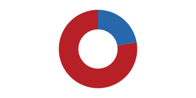

| bs03 | Tiempo mediano en minutos al recinto de educación básica más cercano | 2021 |
| --- | --- | --- |
| bs04 | Tiempo mediano en minutos al recinto de educación media más cercano | 2021 |
| bs07 | Tiempo mediano en minutos al hospital o clínica más cercana | 2021 |
| bs10 | Tiempo mediano en minutos al cuartel de Carabineros más cercano | 2018 |
| bs12 | Porcentaje de viviendas particulares no conectadas a la red de agua potable | 2017 |
| bs21 | Tiempo mediano en minutos al centro de salud primaria más cercano | 2021 |
| ci04 | Porcentaje de viviendas particulares con cobertura de radiodifusión comunitaria ciudadana | 2021 |
| ci06 | Número de espacios culturales por cada 1.000 habitantes | 2021 |
| sm03 | Cantidad de residuos eliminados con disposición final per cápita | 2022 |

### Porvenir

*Rural*

Variables presentes: 9 de 9

Porcentaje de variables presentes: 100%

| bs03 | Tiempo mediano en minutos al recinto de educación básica más cercano | 2021 |
| --- | --- | --- |
| bs04 | Tiempo mediano en minutos al recinto de educación media más cercano | 2021 |
| bs07 | Tiempo mediano en minutos al hospital o clínica más cercana | 2021 |
| bs10 | Tiempo mediano en minutos al cuartel de Carabineros más cercano | 2018 |
| bs12 | Porcentaje de viviendas particulares no conectadas a la red de agua potable | 2017 |
| bs21 | Tiempo mediano en minutos al centro de salud primaria más cercano | 2021 |
| ci04 | Porcentaje de viviendas particulares con cobertura de radiodifusión comunitaria ciudadana | 2021 |
| ci06 | Número de espacios culturales por cada 1.000 habitantes | 2021 |
| sm03 | Cantidad de residuos eliminados con disposición final per cápita | 2022 |

### Primavera

*Rural*

Variables presentes: 8 de 9

Porcentaje de variables presentes: 89%

| bs03 | Tiempo mediano en minutos al recinto de educación básica más cercano | 2021 |
| --- | --- | --- |
| bs04 | Tiempo mediano en minutos al recinto de educación media más cercano | 2021 |
| bs07 | Tiempo mediano en minutos al hospital o clínica más cercana | 2021 |
| bs10 | Tiempo mediano en minutos al cuartel de Carabineros más cercano | 2018 |
| bs12 | Porcentaje de viviendas particulares no conectadas a la red de agua potable | 2017 |
| bs21 | Tiempo mediano en minutos al centro de salud primaria más cercano | 2021 |
| ci04 | Porcentaje de viviendas particulares con cobertura de radiodifusión comunitaria ciudadana | 2021 |
| ci06 | Número de espacios culturales por cada 1.000 habitantes | 2021 |
| sm03 | Cantidad de residuos eliminados con disposición final per cápita | 2022 |

### Timaukel

*Rural*

Variables presentes: 8 de 9

Porcentaje de variables presentes: 89%

| bs03 | Tiempo mediano en minutos al recinto de educación básica más cercano | 2021 |
| --- | --- | --- |
| bs04 | Tiempo mediano en minutos al recinto de educación media más cercano | 2021 |
| bs07 | Tiempo mediano en minutos al hospital o clínica más cercana | 2021 |
| bs10 | Tiempo mediano en minutos al cuartel de Carabineros más cercano | 2018 |
| bs12 | Porcentaje de viviendas particulares no conectadas a la red de agua potable | 2017 |
| bs21 | Tiempo mediano en minutos al centro de salud primaria más cercano | 2021 |
| ci04 | Porcentaje de viviendas particulares con cobertura de radiodifusión comunitaria ciudadana | 2021 |
| ci06 | Número de espacios culturales por cada 1.000 habitantes | 2021 |
| sm03 | Cantidad de residuos eliminados con disposición final per cápita | 2022 |

### Natales

*Rural*

Variables presentes: 9 de 9

Porcentaje de variables presentes: 100%

| bs03 | Tiempo mediano en minutos al recinto de educación básica más cercano | 2021 |
| --- | --- | --- |
| bs04 | Tiempo mediano en minutos al recinto de educación media más cercano | 2021 |
| bs07 | Tiempo mediano en minutos al hospital o clínica más cercana | 2021 |
| bs10 | Tiempo mediano en minutos al cuartel de Carabineros más cercano | 2018 |
| bs12 | Porcentaje de viviendas particulares no conectadas a la red de agua potable | 2017 |
| bs21 | Tiempo mediano en minutos al centro de salud primaria más cercano | 2021 |
| ci04 | Porcentaje de viviendas particulares con cobertura de radiodifusión comunitaria ciudadana | 2021 |
| ci06 | Número de espacios culturales por cada 1.000 habitantes | 2021 |
| sm03 | Cantidad de residuos eliminados con disposición final per cápita | 2022 |

### Torres Del Paine

*Rural*

Variables presentes: 8 de 9

Porcentaje de variables presentes: 89%

| bs03 | Tiempo mediano en minutos al recinto de educación básica más cercano | 2021 |
| --- | --- | --- |
| bs04 | Tiempo mediano en minutos al recinto de educación media más cercano | 2021 |
| bs07 | Tiempo mediano en minutos al hospital o clínica más cercana | 2021 |
| bs10 | Tiempo mediano en minutos al cuartel de Carabineros más cercano | 2018 |
| bs12 | Porcentaje de viviendas particulares no conectadas a la red de agua potable | 2017 |
| bs21 | Tiempo mediano en minutos al centro de salud primaria más cercano | 2021 |
| ci04 | Porcentaje de viviendas particulares con cobertura de radiodifusión comunitaria ciudadana | 2021 |
| ci06 | Número de espacios culturales por cada 1.000 habitantes | 2021 |
| sm03 | Cantidad de residuos eliminados con disposición final per cápita | 2022 |

## Metropolitana de Santiago

### Santiago

*Urbana*

Variables presentes: 9 de 9

Porcentaje de variables presentes: 100%

| bs03 | Tiempo mediano en minutos al recinto de educación básica más cercano | 2021 |
| --- | --- | --- |
| bs04 | Tiempo mediano en minutos al recinto de educación media más cercano | 2021 |
| bs07 | Tiempo mediano en minutos al hospital o clínica más cercana | 2021 |
| bs10 | Tiempo mediano en minutos al cuartel de Carabineros más cercano | 2018 |
| bs12 | Porcentaje de viviendas particulares no conectadas a la red de agua potable | 2017 |
| bs21 | Tiempo mediano en minutos al centro de salud primaria más cercano | 2021 |
| ci04 | Porcentaje de viviendas particulares con cobertura de radiodifusión comunitaria ciudadana | 2021 |
| ci06 | Número de espacios culturales por cada 1.000 habitantes | 2021 |
| sm03 | Cantidad de residuos eliminados con disposición final per cápita | 2022 |

### Cerrillos

*Urbana*

Variables presentes: 9 de 9

Porcentaje de variables presentes: 100%

| bs03 | Tiempo mediano en minutos al recinto de educación básica más cercano | 2021 |
| --- | --- | --- |
| bs04 | Tiempo mediano en minutos al recinto de educación media más cercano | 2021 |
| bs07 | Tiempo mediano en minutos al hospital o clínica más cercana | 2021 |
| bs10 | Tiempo mediano en minutos al cuartel de Carabineros más cercano | 2018 |
| bs12 | Porcentaje de viviendas particulares no conectadas a la red de agua potable | 2017 |
| bs21 | Tiempo mediano en minutos al centro de salud primaria más cercano | 2021 |
| ci04 | Porcentaje de viviendas particulares con cobertura de radiodifusión comunitaria ciudadana | 2021 |
| ci06 | Número de espacios culturales por cada 1.000 habitantes | 2021 |
| sm03 | Cantidad de residuos eliminados con disposición final per cápita | 2022 |

### Cerro Navia

*Urbana*

Variables presentes: 9 de 9

Porcentaje de variables presentes: 100%

| bs03 | Tiempo mediano en minutos al recinto de educación básica más cercano | 2021 |
| --- | --- | --- |
| bs04 | Tiempo mediano en minutos al recinto de educación media más cercano | 2021 |
| bs07 | Tiempo mediano en minutos al hospital o clínica más cercana | 2021 |
| bs10 | Tiempo mediano en minutos al cuartel de Carabineros más cercano | 2018 |
| bs12 | Porcentaje de viviendas particulares no conectadas a la red de agua potable | 2017 |
| bs21 | Tiempo mediano en minutos al centro de salud primaria más cercano | 2021 |
| ci04 | Porcentaje de viviendas particulares con cobertura de radiodifusión comunitaria ciudadana | 2021 |
| ci06 | Número de espacios culturales por cada 1.000 habitantes | 2021 |
| sm03 | Cantidad de residuos eliminados con disposición final per cápita | 2022 |

### Conchalí

*Urbana*

Variables presentes: 8 de 9

Porcentaje de variables presentes: 89%

| bs03 | Tiempo mediano en minutos al recinto de educación básica más cercano | 2021 |
| --- | --- | --- |
| bs04 | Tiempo mediano en minutos al recinto de educación media más cercano | 2021 |
| bs07 | Tiempo mediano en minutos al hospital o clínica más cercana | 2021 |
| bs10 | Tiempo mediano en minutos al cuartel de Carabineros más cercano | 2018 |
| bs12 | Porcentaje de viviendas particulares no conectadas a la red de agua potable | 2017 |
| bs21 | Tiempo mediano en minutos al centro de salud primaria más cercano | 2021 |
| ci04 | Porcentaje de viviendas particulares con cobertura de radiodifusión comunitaria ciudadana | 2021 |
| ci06 | Número de espacios culturales por cada 1.000 habitantes | 2021 |
| sm03 | Cantidad de residuos eliminados con disposición final per cápita | 2022 |

### El Bosque

*Urbana*

Variables presentes: 9 de 9

Porcentaje de variables presentes: 100%

| bs03 | Tiempo mediano en minutos al recinto de educación básica más cercano | 2021 |
| --- | --- | --- |
| bs04 | Tiempo mediano en minutos al recinto de educación media más cercano | 2021 |
| bs07 | Tiempo mediano en minutos al hospital o clínica más cercana | 2021 |
| bs10 | Tiempo mediano en minutos al cuartel de Carabineros más cercano | 2018 |
| bs12 | Porcentaje de viviendas particulares no conectadas a la red de agua potable | 2017 |
| bs21 | Tiempo mediano en minutos al centro de salud primaria más cercano | 2021 |
| ci04 | Porcentaje de viviendas particulares con cobertura de radiodifusión comunitaria ciudadana | 2021 |
| ci06 | Número de espacios culturales por cada 1.000 habitantes | 2021 |
| sm03 | Cantidad de residuos eliminados con disposición final per cápita | 2022 |

### Estación Central

*Urbana*

Variables presentes: 9 de 9

Porcentaje de variables presentes: 100%

| bs03 | Tiempo mediano en minutos al recinto de educación básica más cercano | 2021 |
| --- | --- | --- |
| bs04 | Tiempo mediano en minutos al recinto de educación media más cercano | 2021 |
| bs07 | Tiempo mediano en minutos al hospital o clínica más cercana | 2021 |
| bs10 | Tiempo mediano en minutos al cuartel de Carabineros más cercano | 2018 |
| bs12 | Porcentaje de viviendas particulares no conectadas a la red de agua potable | 2017 |
| bs21 | Tiempo mediano en minutos al centro de salud primaria más cercano | 2021 |
| ci04 | Porcentaje de viviendas particulares con cobertura de radiodifusión comunitaria ciudadana | 2021 |
| ci06 | Número de espacios culturales por cada 1.000 habitantes | 2021 |
| sm03 | Cantidad de residuos eliminados con disposición final per cápita | 2022 |

### Huechuraba

*Urbana*

Variables presentes: 9 de 9

Porcentaje de variables presentes: 100%

| bs03 | Tiempo mediano en minutos al recinto de educación básica más cercano | 2021 |
| --- | --- | --- |
| bs04 | Tiempo mediano en minutos al recinto de educación media más cercano | 2021 |
| bs07 | Tiempo mediano en minutos al hospital o clínica más cercana | 2021 |
| bs10 | Tiempo mediano en minutos al cuartel de Carabineros más cercano | 2018 |
| bs12 | Porcentaje de viviendas particulares no conectadas a la red de agua potable | 2017 |
| bs21 | Tiempo mediano en minutos al centro de salud primaria más cercano | 2021 |
| ci04 | Porcentaje de viviendas particulares con cobertura de radiodifusión comunitaria ciudadana | 2021 |
| ci06 | Número de espacios culturales por cada 1.000 habitantes | 2021 |
| sm03 | Cantidad de residuos eliminados con disposición final per cápita | 2022 |

### Independencia

*Urbana*

Variables presentes: 9 de 9

Porcentaje de variables presentes: 100%

| bs03 | Tiempo mediano en minutos al recinto de educación básica más cercano | 2021 |
| --- | --- | --- |
| bs04 | Tiempo mediano en minutos al recinto de educación media más cercano | 2021 |
| bs07 | Tiempo mediano en minutos al hospital o clínica más cercana | 2021 |
| bs10 | Tiempo mediano en minutos al cuartel de Carabineros más cercano | 2018 |
| bs12 | Porcentaje de viviendas particulares no conectadas a la red de agua potable | 2017 |
| bs21 | Tiempo mediano en minutos al centro de salud primaria más cercano | 2021 |
| ci04 | Porcentaje de viviendas particulares con cobertura de radiodifusión comunitaria ciudadana | 2021 |
| ci06 | Número de espacios culturales por cada 1.000 habitantes | 2021 |
| sm03 | Cantidad de residuos eliminados con disposición final per cápita | 2022 |

### La Cisterna

*Urbana*

Variables presentes: 9 de 9

Porcentaje de variables presentes: 100%

| bs03 | Tiempo mediano en minutos al recinto de educación básica más cercano | 2021 |
| --- | --- | --- |
| bs04 | Tiempo mediano en minutos al recinto de educación media más cercano | 2021 |
| bs07 | Tiempo mediano en minutos al hospital o clínica más cercana | 2021 |
| bs10 | Tiempo mediano en minutos al cuartel de Carabineros más cercano | 2018 |
| bs12 | Porcentaje de viviendas particulares no conectadas a la red de agua potable | 2017 |
| bs21 | Tiempo mediano en minutos al centro de salud primaria más cercano | 2021 |
| ci04 | Porcentaje de viviendas particulares con cobertura de radiodifusión comunitaria ciudadana | 2021 |
| ci06 | Número de espacios culturales por cada 1.000 habitantes | 2021 |
| sm03 | Cantidad de residuos eliminados con disposición final per cápita | 2022 |

### La Florida

*Urbana*

Variables presentes: 9 de 9

Porcentaje de variables presentes: 100%

| bs03 | Tiempo mediano en minutos al recinto de educación básica más cercano | 2021 |
| --- | --- | --- |
| bs04 | Tiempo mediano en minutos al recinto de educación media más cercano | 2021 |
| bs07 | Tiempo mediano en minutos al hospital o clínica más cercana | 2021 |
| bs10 | Tiempo mediano en minutos al cuartel de Carabineros más cercano | 2018 |
| bs12 | Porcentaje de viviendas particulares no conectadas a la red de agua potable | 2017 |
| bs21 | Tiempo mediano en minutos al centro de salud primaria más cercano | 2021 |
| ci04 | Porcentaje de viviendas particulares con cobertura de radiodifusión comunitaria ciudadana | 2021 |
| ci06 | Número de espacios culturales por cada 1.000 habitantes | 2021 |
| sm03 | Cantidad de residuos eliminados con disposición final per cápita | 2022 |

### La Granja

*Urbana*

Variables presentes: 9 de 9

Porcentaje de variables presentes: 100%

| bs03 | Tiempo mediano en minutos al recinto de educación básica más cercano | 2021 |
| --- | --- | --- |
| bs04 | Tiempo mediano en minutos al recinto de educación media más cercano | 2021 |
| bs07 | Tiempo mediano en minutos al hospital o clínica más cercana | 2021 |
| bs10 | Tiempo mediano en minutos al cuartel de Carabineros más cercano | 2018 |
| bs12 | Porcentaje de viviendas particulares no conectadas a la red de agua potable | 2017 |
| bs21 | Tiempo mediano en minutos al centro de salud primaria más cercano | 2021 |
| ci04 | Porcentaje de viviendas particulares con cobertura de radiodifusión comunitaria ciudadana | 2021 |
| ci06 | Número de espacios culturales por cada 1.000 habitantes | 2021 |
| sm03 | Cantidad de residuos eliminados con disposición final per cápita | 2022 |

### La Pintana

*Urbana*

Variables presentes: 9 de 9

Porcentaje de variables presentes: 100%

| bs03 | Tiempo mediano en minutos al recinto de educación básica más cercano | 2021 |
| --- | --- | --- |
| bs04 | Tiempo mediano en minutos al recinto de educación media más cercano | 2021 |
| bs07 | Tiempo mediano en minutos al hospital o clínica más cercana | 2021 |
| bs10 | Tiempo mediano en minutos al cuartel de Carabineros más cercano | 2018 |
| bs12 | Porcentaje de viviendas particulares no conectadas a la red de agua potable | 2017 |
| bs21 | Tiempo mediano en minutos al centro de salud primaria más cercano | 2021 |
| ci04 | Porcentaje de viviendas particulares con cobertura de radiodifusión comunitaria ciudadana | 2021 |
| ci06 | Número de espacios culturales por cada 1.000 habitantes | 2021 |
| sm03 | Cantidad de residuos eliminados con disposición final per cápita | 2022 |

### La Reina

*Urbana*

Variables presentes: 9 de 9

Porcentaje de variables presentes: 100%

| bs03 | Tiempo mediano en minutos al recinto de educación básica más cercano | 2021 |
| --- | --- | --- |
| bs04 | Tiempo mediano en minutos al recinto de educación media más cercano | 2021 |
| bs07 | Tiempo mediano en minutos al hospital o clínica más cercana | 2021 |
| bs10 | Tiempo mediano en minutos al cuartel de Carabineros más cercano | 2018 |
| bs12 | Porcentaje de viviendas particulares no conectadas a la red de agua potable | 2017 |
| bs21 | Tiempo mediano en minutos al centro de salud primaria más cercano | 2021 |
| ci04 | Porcentaje de viviendas particulares con cobertura de radiodifusión comunitaria ciudadana | 2021 |
| ci06 | Número de espacios culturales por cada 1.000 habitantes | 2021 |
| sm03 | Cantidad de residuos eliminados con disposición final per cápita | 2022 |

### Las Condes

*Urbana*

Variables presentes: 9 de 9

Porcentaje de variables presentes: 100%

| bs03 | Tiempo mediano en minutos al recinto de educación básica más cercano | 2021 |
| --- | --- | --- |
| bs04 | Tiempo mediano en minutos al recinto de educación media más cercano | 2021 |
| bs07 | Tiempo mediano en minutos al hospital o clínica más cercana | 2021 |
| bs10 | Tiempo mediano en minutos al cuartel de Carabineros más cercano | 2018 |
| bs12 | Porcentaje de viviendas particulares no conectadas a la red de agua potable | 2017 |
| bs21 | Tiempo mediano en minutos al centro de salud primaria más cercano | 2021 |
| ci04 | Porcentaje de viviendas particulares con cobertura de radiodifusión comunitaria ciudadana | 2021 |
| ci06 | Número de espacios culturales por cada 1.000 habitantes | 2021 |
| sm03 | Cantidad de residuos eliminados con disposición final per cápita | 2022 |

### Lo Barnechea

*Urbana*

Variables presentes: 9 de 9

Porcentaje de variables presentes: 100%

| bs03 | Tiempo mediano en minutos al recinto de educación básica más cercano | 2021 |
| --- | --- | --- |
| bs04 | Tiempo mediano en minutos al recinto de educación media más cercano | 2021 |
| bs07 | Tiempo mediano en minutos al hospital o clínica más cercana | 2021 |
| bs10 | Tiempo mediano en minutos al cuartel de Carabineros más cercano | 2018 |
| bs12 | Porcentaje de viviendas particulares no conectadas a la red de agua potable | 2017 |
| bs21 | Tiempo mediano en minutos al centro de salud primaria más cercano | 2021 |
| ci04 | Porcentaje de viviendas particulares con cobertura de radiodifusión comunitaria ciudadana | 2021 |
| ci06 | Número de espacios culturales por cada 1.000 habitantes | 2021 |
| sm03 | Cantidad de residuos eliminados con disposición final per cápita | 2022 |

### Lo Espejo

*Urbana*

Variables presentes: 8 de 9

Porcentaje de variables presentes: 89%

| bs03 | Tiempo mediano en minutos al recinto de educación básica más cercano | 2021 |
| --- | --- | --- |
| bs04 | Tiempo mediano en minutos al recinto de educación media más cercano | 2021 |
| bs07 | Tiempo mediano en minutos al hospital o clínica más cercana | 2021 |
| bs10 | Tiempo mediano en minutos al cuartel de Carabineros más cercano | 2018 |
| bs12 | Porcentaje de viviendas particulares no conectadas a la red de agua potable | 2017 |
| bs21 | Tiempo mediano en minutos al centro de salud primaria más cercano | 2021 |
| ci04 | Porcentaje de viviendas particulares con cobertura de radiodifusión comunitaria ciudadana | 2021 |
| ci06 | Número de espacios culturales por cada 1.000 habitantes | 2021 |
| sm03 | Cantidad de residuos eliminados con disposición final per cápita | 2022 |

### Lo Prado

*Urbana*

Variables presentes: 9 de 9

Porcentaje de variables presentes: 100%

| bs03 | Tiempo mediano en minutos al recinto de educación básica más cercano | 2021 |
| --- | --- | --- |
| bs04 | Tiempo mediano en minutos al recinto de educación media más cercano | 2021 |
| bs07 | Tiempo mediano en minutos al hospital o clínica más cercana | 2021 |
| bs10 | Tiempo mediano en minutos al cuartel de Carabineros más cercano | 2018 |
| bs12 | Porcentaje de viviendas particulares no conectadas a la red de agua potable | 2017 |
| bs21 | Tiempo mediano en minutos al centro de salud primaria más cercano | 2021 |
| ci04 | Porcentaje de viviendas particulares con cobertura de radiodifusión comunitaria ciudadana | 2021 |
| ci06 | Número de espacios culturales por cada 1.000 habitantes | 2021 |
| sm03 | Cantidad de residuos eliminados con disposición final per cápita | 2022 |

### Macul

*Urbana*

Variables presentes: 9 de 9

Porcentaje de variables presentes: 100%

| bs03 | Tiempo mediano en minutos al recinto de educación básica más cercano | 2021 |
| --- | --- | --- |
| bs04 | Tiempo mediano en minutos al recinto de educación media más cercano | 2021 |
| bs07 | Tiempo mediano en minutos al hospital o clínica más cercana | 2021 |
| bs10 | Tiempo mediano en minutos al cuartel de Carabineros más cercano | 2018 |
| bs12 | Porcentaje de viviendas particulares no conectadas a la red de agua potable | 2017 |
| bs21 | Tiempo mediano en minutos al centro de salud primaria más cercano | 2021 |
| ci04 | Porcentaje de viviendas particulares con cobertura de radiodifusión comunitaria ciudadana | 2021 |
| ci06 | Número de espacios culturales por cada 1.000 habitantes | 2021 |
| sm03 | Cantidad de residuos eliminados con disposición final per cápita | 2022 |

### Maipú

*Urbana*

Variables presentes: 9 de 9

Porcentaje de variables presentes: 100%

| bs03 | Tiempo mediano en minutos al recinto de educación básica más cercano | 2021 |
| --- | --- | --- |
| bs04 | Tiempo mediano en minutos al recinto de educación media más cercano | 2021 |
| bs07 | Tiempo mediano en minutos al hospital o clínica más cercana | 2021 |
| bs10 | Tiempo mediano en minutos al cuartel de Carabineros más cercano | 2018 |
| bs12 | Porcentaje de viviendas particulares no conectadas a la red de agua potable | 2017 |
| bs21 | Tiempo mediano en minutos al centro de salud primaria más cercano | 2021 |
| ci04 | Porcentaje de viviendas particulares con cobertura de radiodifusión comunitaria ciudadana | 2021 |
| ci06 | Número de espacios culturales por cada 1.000 habitantes | 2021 |
| sm03 | Cantidad de residuos eliminados con disposición final per cápita | 2022 |

### Ñuñoa

*Urbana*

Variables presentes: 9 de 9

Porcentaje de variables presentes: 100%

| bs03 | Tiempo mediano en minutos al recinto de educación básica más cercano | 2021 |
| --- | --- | --- |
| bs04 | Tiempo mediano en minutos al recinto de educación media más cercano | 2021 |
| bs07 | Tiempo mediano en minutos al hospital o clínica más cercana | 2021 |
| bs10 | Tiempo mediano en minutos al cuartel de Carabineros más cercano | 2018 |
| bs12 | Porcentaje de viviendas particulares no conectadas a la red de agua potable | 2017 |
| bs21 | Tiempo mediano en minutos al centro de salud primaria más cercano | 2021 |
| ci04 | Porcentaje de viviendas particulares con cobertura de radiodifusión comunitaria ciudadana | 2021 |
| ci06 | Número de espacios culturales por cada 1.000 habitantes | 2021 |
| sm03 | Cantidad de residuos eliminados con disposición final per cápita | 2022 |

### Pedro Aguirre Cerda

*Urbana*

Variables presentes: 8 de 9

Porcentaje de variables presentes: 89%

| bs03 | Tiempo mediano en minutos al recinto de educación básica más cercano | 2021 |
| --- | --- | --- |
| bs04 | Tiempo mediano en minutos al recinto de educación media más cercano | 2021 |
| bs07 | Tiempo mediano en minutos al hospital o clínica más cercana | 2021 |
| bs10 | Tiempo mediano en minutos al cuartel de Carabineros más cercano | 2018 |
| bs12 | Porcentaje de viviendas particulares no conectadas a la red de agua potable | 2017 |
| bs21 | Tiempo mediano en minutos al centro de salud primaria más cercano | 2021 |
| ci04 | Porcentaje de viviendas particulares con cobertura de radiodifusión comunitaria ciudadana | 2021 |
| ci06 | Número de espacios culturales por cada 1.000 habitantes | 2021 |
| sm03 | Cantidad de residuos eliminados con disposición final per cápita | 2022 |

### Peñalolén

*Urbana*

Variables presentes: 9 de 9

Porcentaje de variables presentes: 100%

| bs03 | Tiempo mediano en minutos al recinto de educación básica más cercano | 2021 |
| --- | --- | --- |
| bs04 | Tiempo mediano en minutos al recinto de educación media más cercano | 2021 |
| bs07 | Tiempo mediano en minutos al hospital o clínica más cercana | 2021 |
| bs10 | Tiempo mediano en minutos al cuartel de Carabineros más cercano | 2018 |
| bs12 | Porcentaje de viviendas particulares no conectadas a la red de agua potable | 2017 |
| bs21 | Tiempo mediano en minutos al centro de salud primaria más cercano | 2021 |
| ci04 | Porcentaje de viviendas particulares con cobertura de radiodifusión comunitaria ciudadana | 2021 |
| ci06 | Número de espacios culturales por cada 1.000 habitantes | 2021 |
| sm03 | Cantidad de residuos eliminados con disposición final per cápita | 2022 |

### Providencia

*Urbana*

Variables presentes: 9 de 9

Porcentaje de variables presentes: 100%

| bs03 | Tiempo mediano en minutos al recinto de educación básica más cercano | 2021 |
| --- | --- | --- |
| bs04 | Tiempo mediano en minutos al recinto de educación media más cercano | 2021 |
| bs07 | Tiempo mediano en minutos al hospital o clínica más cercana | 2021 |
| bs10 | Tiempo mediano en minutos al cuartel de Carabineros más cercano | 2018 |
| bs12 | Porcentaje de viviendas particulares no conectadas a la red de agua potable | 2017 |
| bs21 | Tiempo mediano en minutos al centro de salud primaria más cercano | 2021 |
| ci04 | Porcentaje de viviendas particulares con cobertura de radiodifusión comunitaria ciudadana | 2021 |
| ci06 | Número de espacios culturales por cada 1.000 habitantes | 2021 |
| sm03 | Cantidad de residuos eliminados con disposición final per cápita | 2022 |

### Pudahuel

*Urbana*

Variables presentes: 8 de 9

Porcentaje de variables presentes: 89%

| bs03 | Tiempo mediano en minutos al recinto de educación básica más cercano | 2021 |
| --- | --- | --- |
| bs04 | Tiempo mediano en minutos al recinto de educación media más cercano | 2021 |
| bs07 | Tiempo mediano en minutos al hospital o clínica más cercana | 2021 |
| bs10 | Tiempo mediano en minutos al cuartel de Carabineros más cercano | 2018 |
| bs12 | Porcentaje de viviendas particulares no conectadas a la red de agua potable | 2017 |
| bs21 | Tiempo mediano en minutos al centro de salud primaria más cercano | 2021 |
| ci04 | Porcentaje de viviendas particulares con cobertura de radiodifusión comunitaria ciudadana | 2021 |
| ci06 | Número de espacios culturales por cada 1.000 habitantes | 2021 |
| sm03 | Cantidad de residuos eliminados con disposición final per cápita | 2022 |

### Quilicura

*Urbana*

Variables presentes: 9 de 9

Porcentaje de variables presentes: 100%

| bs03 | Tiempo mediano en minutos al recinto de educación básica más cercano | 2021 |
| --- | --- | --- |
| bs04 | Tiempo mediano en minutos al recinto de educación media más cercano | 2021 |
| bs07 | Tiempo mediano en minutos al hospital o clínica más cercana | 2021 |
| bs10 | Tiempo mediano en minutos al cuartel de Carabineros más cercano | 2018 |
| bs12 | Porcentaje de viviendas particulares no conectadas a la red de agua potable | 2017 |
| bs21 | Tiempo mediano en minutos al centro de salud primaria más cercano | 2021 |
| ci04 | Porcentaje de viviendas particulares con cobertura de radiodifusión comunitaria ciudadana | 2021 |
| ci06 | Número de espacios culturales por cada 1.000 habitantes | 2021 |
| sm03 | Cantidad de residuos eliminados con disposición final per cápita | 2022 |

### Quinta Normal

*Urbana*

Variables presentes: 7 de 9

Porcentaje de variables presentes: 78%

| bs03 | Tiempo mediano en minutos al recinto de educación básica más cercano | 2021 |
| --- | --- | --- |
| bs04 | Tiempo mediano en minutos al recinto de educación media más cercano | 2021 |
| bs07 | Tiempo mediano en minutos al hospital o clínica más cercana | 2021 |
| bs10 | Tiempo mediano en minutos al cuartel de Carabineros más cercano | 2018 |
| bs12 | Porcentaje de viviendas particulares no conectadas a la red de agua potable | 2017 |
| bs21 | Tiempo mediano en minutos al centro de salud primaria más cercano | 2021 |
| ci04 | Porcentaje de viviendas particulares con cobertura de radiodifusión comunitaria ciudadana | 2021 |
| ci06 | Número de espacios culturales por cada 1.000 habitantes | 2021 |
| sm03 | Cantidad de residuos eliminados con disposición final per cápita | 2022 |

### Recoleta

*Urbana*

Variables presentes: 9 de 9

Porcentaje de variables presentes: 100%

| bs03 | Tiempo mediano en minutos al recinto de educación básica más cercano | 2021 |
| --- | --- | --- |
| bs04 | Tiempo mediano en minutos al recinto de educación media más cercano | 2021 |
| bs07 | Tiempo mediano en minutos al hospital o clínica más cercana | 2021 |
| bs10 | Tiempo mediano en minutos al cuartel de Carabineros más cercano | 2018 |
| bs12 | Porcentaje de viviendas particulares no conectadas a la red de agua potable | 2017 |
| bs21 | Tiempo mediano en minutos al centro de salud primaria más cercano | 2021 |
| ci04 | Porcentaje de viviendas particulares con cobertura de radiodifusión comunitaria ciudadana | 2021 |
| ci06 | Número de espacios culturales por cada 1.000 habitantes | 2021 |
| sm03 | Cantidad de residuos eliminados con disposición final per cápita | 2022 |

### Renca

*Urbana*

Variables presentes: 9 de 9

Porcentaje de variables presentes: 100%

| bs03 | Tiempo mediano en minutos al recinto de educación básica más cercano | 2021 |
| --- | --- | --- |
| bs04 | Tiempo mediano en minutos al recinto de educación media más cercano | 2021 |
| bs07 | Tiempo mediano en minutos al hospital o clínica más cercana | 2021 |
| bs10 | Tiempo mediano en minutos al cuartel de Carabineros más cercano | 2018 |
| bs12 | Porcentaje de viviendas particulares no conectadas a la red de agua potable | 2017 |
| bs21 | Tiempo mediano en minutos al centro de salud primaria más cercano | 2021 |
| ci04 | Porcentaje de viviendas particulares con cobertura de radiodifusión comunitaria ciudadana | 2021 |
| ci06 | Número de espacios culturales por cada 1.000 habitantes | 2021 |
| sm03 | Cantidad de residuos eliminados con disposición final per cápita | 2022 |

### San Joaquín

*Urbana*

Variables presentes: 9 de 9

Porcentaje de variables presentes: 100%

| bs03 | Tiempo mediano en minutos al recinto de educación básica más cercano | 2021 |
| --- | --- | --- |
| bs04 | Tiempo mediano en minutos al recinto de educación media más cercano | 2021 |
| bs07 | Tiempo mediano en minutos al hospital o clínica más cercana | 2021 |
| bs10 | Tiempo mediano en minutos al cuartel de Carabineros más cercano | 2018 |
| bs12 | Porcentaje de viviendas particulares no conectadas a la red de agua potable | 2017 |
| bs21 | Tiempo mediano en minutos al centro de salud primaria más cercano | 2021 |
| ci04 | Porcentaje de viviendas particulares con cobertura de radiodifusión comunitaria ciudadana | 2021 |
| ci06 | Número de espacios culturales por cada 1.000 habitantes | 2021 |
| sm03 | Cantidad de residuos eliminados con disposición final per cápita | 2022 |

### San Miguel

*Urbana*

Variables presentes: 9 de 9

Porcentaje de variables presentes: 100%

| bs03 | Tiempo mediano en minutos al recinto de educación básica más cercano | 2021 |
| --- | --- | --- |
| bs04 | Tiempo mediano en minutos al recinto de educación media más cercano | 2021 |
| bs07 | Tiempo mediano en minutos al hospital o clínica más cercana | 2021 |
| bs10 | Tiempo mediano en minutos al cuartel de Carabineros más cercano | 2018 |
| bs12 | Porcentaje de viviendas particulares no conectadas a la red de agua potable | 2017 |
| bs21 | Tiempo mediano en minutos al centro de salud primaria más cercano | 2021 |
| ci04 | Porcentaje de viviendas particulares con cobertura de radiodifusión comunitaria ciudadana | 2021 |
| ci06 | Número de espacios culturales por cada 1.000 habitantes | 2021 |
| sm03 | Cantidad de residuos eliminados con disposición final per cápita | 2022 |

### San Ramón

*Urbana*

Variables presentes: 8 de 9

Porcentaje de variables presentes: 89%

| bs03 | Tiempo mediano en minutos al recinto de educación básica más cercano | 2021 |
| --- | --- | --- |
| bs04 | Tiempo mediano en minutos al recinto de educación media más cercano | 2021 |
| bs07 | Tiempo mediano en minutos al hospital o clínica más cercana | 2021 |
| bs10 | Tiempo mediano en minutos al cuartel de Carabineros más cercano | 2018 |
| bs12 | Porcentaje de viviendas particulares no conectadas a la red de agua potable | 2017 |
| bs21 | Tiempo mediano en minutos al centro de salud primaria más cercano | 2021 |
| ci04 | Porcentaje de viviendas particulares con cobertura de radiodifusión comunitaria ciudadana | 2021 |
| ci06 | Número de espacios culturales por cada 1.000 habitantes | 2021 |
| sm03 | Cantidad de residuos eliminados con disposición final per cápita | 2022 |

### Vitacura

*Urbana*

Variables presentes: 9 de 9

Porcentaje de variables presentes: 100%

| bs03 | Tiempo mediano en minutos al recinto de educación básica más cercano | 2021 |
| --- | --- | --- |
| bs04 | Tiempo mediano en minutos al recinto de educación media más cercano | 2021 |
| bs07 | Tiempo mediano en minutos al hospital o clínica más cercana | 2021 |
| bs10 | Tiempo mediano en minutos al cuartel de Carabineros más cercano | 2018 |
| bs12 | Porcentaje de viviendas particulares no conectadas a la red de agua potable | 2017 |
| bs21 | Tiempo mediano en minutos al centro de salud primaria más cercano | 2021 |
| ci04 | Porcentaje de viviendas particulares con cobertura de radiodifusión comunitaria ciudadana | 2021 |
| ci06 | Número de espacios culturales por cada 1.000 habitantes | 2021 |
| sm03 | Cantidad de residuos eliminados con disposición final per cápita | 2022 |

### Puente Alto

*Urbana*

Variables presentes: 9 de 9

Porcentaje de variables presentes: 100%

| bs03 | Tiempo mediano en minutos al recinto de educación básica más cercano | 2021 |
| --- | --- | --- |
| bs04 | Tiempo mediano en minutos al recinto de educación media más cercano | 2021 |
| bs07 | Tiempo mediano en minutos al hospital o clínica más cercana | 2021 |
| bs10 | Tiempo mediano en minutos al cuartel de Carabineros más cercano | 2018 |
| bs12 | Porcentaje de viviendas particulares no conectadas a la red de agua potable | 2017 |
| bs21 | Tiempo mediano en minutos al centro de salud primaria más cercano | 2021 |
| ci04 | Porcentaje de viviendas particulares con cobertura de radiodifusión comunitaria ciudadana | 2021 |
| ci06 | Número de espacios culturales por cada 1.000 habitantes | 2021 |
| sm03 | Cantidad de residuos eliminados con disposición final per cápita | 2022 |

### Pirque

*Rural*

Variables presentes: 9 de 9

Porcentaje de variables presentes: 100%

| bs03 | Tiempo mediano en minutos al recinto de educación básica más cercano | 2021 |
| --- | --- | --- |
| bs04 | Tiempo mediano en minutos al recinto de educación media más cercano | 2021 |
| bs07 | Tiempo mediano en minutos al hospital o clínica más cercana | 2021 |
| bs10 | Tiempo mediano en minutos al cuartel de Carabineros más cercano | 2018 |
| bs12 | Porcentaje de viviendas particulares no conectadas a la red de agua potable | 2017 |
| bs21 | Tiempo mediano en minutos al centro de salud primaria más cercano | 2021 |
| ci04 | Porcentaje de viviendas particulares con cobertura de radiodifusión comunitaria ciudadana | 2021 |
| ci06 | Número de espacios culturales por cada 1.000 habitantes | 2021 |
| sm03 | Cantidad de residuos eliminados con disposición final per cápita | 2022 |

### San José De Maipo

*Rural*

Variables presentes: 9 de 9

Porcentaje de variables presentes: 100%

| bs03 | Tiempo mediano en minutos al recinto de educación básica más cercano | 2021 |
| --- | --- | --- |
| bs04 | Tiempo mediano en minutos al recinto de educación media más cercano | 2021 |
| bs07 | Tiempo mediano en minutos al hospital o clínica más cercana | 2021 |
| bs10 | Tiempo mediano en minutos al cuartel de Carabineros más cercano | 2018 |
| bs12 | Porcentaje de viviendas particulares no conectadas a la red de agua potable | 2017 |
| bs21 | Tiempo mediano en minutos al centro de salud primaria más cercano | 2021 |
| ci04 | Porcentaje de viviendas particulares con cobertura de radiodifusión comunitaria ciudadana | 2021 |
| ci06 | Número de espacios culturales por cada 1.000 habitantes | 2021 |
| sm03 | Cantidad de residuos eliminados con disposición final per cápita | 2022 |

### Colina

*Urbana*

Variables presentes: 9 de 9

Porcentaje de variables presentes: 100%

| bs03 | Tiempo mediano en minutos al recinto de educación básica más cercano | 2021 |
| --- | --- | --- |
| bs04 | Tiempo mediano en minutos al recinto de educación media más cercano | 2021 |
| bs07 | Tiempo mediano en minutos al hospital o clínica más cercana | 2021 |
| bs10 | Tiempo mediano en minutos al cuartel de Carabineros más cercano | 2018 |
| bs12 | Porcentaje de viviendas particulares no conectadas a la red de agua potable | 2017 |
| bs21 | Tiempo mediano en minutos al centro de salud primaria más cercano | 2021 |
| ci04 | Porcentaje de viviendas particulares con cobertura de radiodifusión comunitaria ciudadana | 2021 |
| ci06 | Número de espacios culturales por cada 1.000 habitantes | 2021 |
| sm03 | Cantidad de residuos eliminados con disposición final per cápita | 2022 |

### Lampa

*Urbana*

Variables presentes: 9 de 9

Porcentaje de variables presentes: 100%

| bs03 | Tiempo mediano en minutos al recinto de educación básica más cercano | 2021 |
| --- | --- | --- |
| bs04 | Tiempo mediano en minutos al recinto de educación media más cercano | 2021 |
| bs07 | Tiempo mediano en minutos al hospital o clínica más cercana | 2021 |
| bs10 | Tiempo mediano en minutos al cuartel de Carabineros más cercano | 2018 |
| bs12 | Porcentaje de viviendas particulares no conectadas a la red de agua potable | 2017 |
| bs21 | Tiempo mediano en minutos al centro de salud primaria más cercano | 2021 |
| ci04 | Porcentaje de viviendas particulares con cobertura de radiodifusión comunitaria ciudadana | 2021 |
| ci06 | Número de espacios culturales por cada 1.000 habitantes | 2021 |
| sm03 | Cantidad de residuos eliminados con disposición final per cápita | 2022 |

### Tiltil

*Rural*

Variables presentes: 9 de 9

Porcentaje de variables presentes: 100%

| bs03 | Tiempo mediano en minutos al recinto de educación básica más cercano | 2021 |
| --- | --- | --- |
| bs04 | Tiempo mediano en minutos al recinto de educación media más cercano | 2021 |
| bs07 | Tiempo mediano en minutos al hospital o clínica más cercana | 2021 |
| bs10 | Tiempo mediano en minutos al cuartel de Carabineros más cercano | 2018 |
| bs12 | Porcentaje de viviendas particulares no conectadas a la red de agua potable | 2017 |
| bs21 | Tiempo mediano en minutos al centro de salud primaria más cercano | 2021 |
| ci04 | Porcentaje de viviendas particulares con cobertura de radiodifusión comunitaria ciudadana | 2021 |
| ci06 | Número de espacios culturales por cada 1.000 habitantes | 2021 |
| sm03 | Cantidad de residuos eliminados con disposición final per cápita | 2022 |

### San Bernardo

*Urbana*

Variables presentes: 9 de 9

Porcentaje de variables presentes: 100%

| bs03 | Tiempo mediano en minutos al recinto de educación básica más cercano | 2021 |
| --- | --- | --- |
| bs04 | Tiempo mediano en minutos al recinto de educación media más cercano | 2021 |
| bs07 | Tiempo mediano en minutos al hospital o clínica más cercana | 2021 |
| bs10 | Tiempo mediano en minutos al cuartel de Carabineros más cercano | 2018 |
| bs12 | Porcentaje de viviendas particulares no conectadas a la red de agua potable | 2017 |
| bs21 | Tiempo mediano en minutos al centro de salud primaria más cercano | 2021 |
| ci04 | Porcentaje de viviendas particulares con cobertura de radiodifusión comunitaria ciudadana | 2021 |
| ci06 | Número de espacios culturales por cada 1.000 habitantes | 2021 |
| sm03 | Cantidad de residuos eliminados con disposición final per cápita | 2022 |

### Buin

*Urbana*

Variables presentes: 9 de 9

Porcentaje de variables presentes: 100%

| bs03 | Tiempo mediano en minutos al recinto de educación básica más cercano | 2021 |
| --- | --- | --- |
| bs04 | Tiempo mediano en minutos al recinto de educación media más cercano | 2021 |
| bs07 | Tiempo mediano en minutos al hospital o clínica más cercana | 2021 |
| bs10 | Tiempo mediano en minutos al cuartel de Carabineros más cercano | 2018 |
| bs12 | Porcentaje de viviendas particulares no conectadas a la red de agua potable | 2017 |
| bs21 | Tiempo mediano en minutos al centro de salud primaria más cercano | 2021 |
| ci04 | Porcentaje de viviendas particulares con cobertura de radiodifusión comunitaria ciudadana | 2021 |
| ci06 | Número de espacios culturales por cada 1.000 habitantes | 2021 |
| sm03 | Cantidad de residuos eliminados con disposición final per cápita | 2022 |

### Calera De Tango

*Mixta*

Variables presentes: 9 de 9

Porcentaje de variables presentes: 100%

| bs03 | Tiempo mediano en minutos al recinto de educación básica más cercano | 2021 |
| --- | --- | --- |
| bs04 | Tiempo mediano en minutos al recinto de educación media más cercano | 2021 |
| bs07 | Tiempo mediano en minutos al hospital o clínica más cercana | 2021 |
| bs10 | Tiempo mediano en minutos al cuartel de Carabineros más cercano | 2018 |
| bs12 | Porcentaje de viviendas particulares no conectadas a la red de agua potable | 2017 |
| bs21 | Tiempo mediano en minutos al centro de salud primaria más cercano | 2021 |
| ci04 | Porcentaje de viviendas particulares con cobertura de radiodifusión comunitaria ciudadana | 2021 |
| ci06 | Número de espacios culturales por cada 1.000 habitantes | 2021 |
| sm03 | Cantidad de residuos eliminados con disposición final per cápita | 2022 |

### Paine

*Mixta*

Variables presentes: 9 de 9

Porcentaje de variables presentes: 100%

| bs03 | Tiempo mediano en minutos al recinto de educación básica más cercano | 2021 |
| --- | --- | --- |
| bs04 | Tiempo mediano en minutos al recinto de educación media más cercano | 2021 |
| bs07 | Tiempo mediano en minutos al hospital o clínica más cercana | 2021 |
| bs10 | Tiempo mediano en minutos al cuartel de Carabineros más cercano | 2018 |
| bs12 | Porcentaje de viviendas particulares no conectadas a la red de agua potable | 2017 |
| bs21 | Tiempo mediano en minutos al centro de salud primaria más cercano | 2021 |
| ci04 | Porcentaje de viviendas particulares con cobertura de radiodifusión comunitaria ciudadana | 2021 |
| ci06 | Número de espacios culturales por cada 1.000 habitantes | 2021 |
| sm03 | Cantidad de residuos eliminados con disposición final per cápita | 2022 |

### Melipilla

*Urbana*

Variables presentes: 9 de 9

Porcentaje de variables presentes: 100%

| bs03 | Tiempo mediano en minutos al recinto de educación básica más cercano | 2021 |
| --- | --- | --- |
| bs04 | Tiempo mediano en minutos al recinto de educación media más cercano | 2021 |
| bs07 | Tiempo mediano en minutos al hospital o clínica más cercana | 2021 |
| bs10 | Tiempo mediano en minutos al cuartel de Carabineros más cercano | 2018 |
| bs12 | Porcentaje de viviendas particulares no conectadas a la red de agua potable | 2017 |
| bs21 | Tiempo mediano en minutos al centro de salud primaria más cercano | 2021 |
| ci04 | Porcentaje de viviendas particulares con cobertura de radiodifusión comunitaria ciudadana | 2021 |
| ci06 | Número de espacios culturales por cada 1.000 habitantes | 2021 |
| sm03 | Cantidad de residuos eliminados con disposición final per cápita | 2022 |

### Alhué

*Rural*

Variables presentes: 9 de 9

Porcentaje de variables presentes: 100%

| bs03 | Tiempo mediano en minutos al recinto de educación básica más cercano | 2021 |
| --- | --- | --- |
| bs04 | Tiempo mediano en minutos al recinto de educación media más cercano | 2021 |
| bs07 | Tiempo mediano en minutos al hospital o clínica más cercana | 2021 |
| bs10 | Tiempo mediano en minutos al cuartel de Carabineros más cercano | 2018 |
| bs12 | Porcentaje de viviendas particulares no conectadas a la red de agua potable | 2017 |
| bs21 | Tiempo mediano en minutos al centro de salud primaria más cercano | 2021 |
| ci04 | Porcentaje de viviendas particulares con cobertura de radiodifusión comunitaria ciudadana | 2021 |
| ci06 | Número de espacios culturales por cada 1.000 habitantes | 2021 |
| sm03 | Cantidad de residuos eliminados con disposición final per cápita | 2022 |

### Curacaví

*Mixta*

Variables presentes: 9 de 9

Porcentaje de variables presentes: 100%

| bs03 | Tiempo mediano en minutos al recinto de educación básica más cercano | 2021 |
| --- | --- | --- |
| bs04 | Tiempo mediano en minutos al recinto de educación media más cercano | 2021 |
| bs07 | Tiempo mediano en minutos al hospital o clínica más cercana | 2021 |
| bs10 | Tiempo mediano en minutos al cuartel de Carabineros más cercano | 2018 |
| bs12 | Porcentaje de viviendas particulares no conectadas a la red de agua potable | 2017 |
| bs21 | Tiempo mediano en minutos al centro de salud primaria más cercano | 2021 |
| ci04 | Porcentaje de viviendas particulares con cobertura de radiodifusión comunitaria ciudadana | 2021 |
| ci06 | Número de espacios culturales por cada 1.000 habitantes | 2021 |
| sm03 | Cantidad de residuos eliminados con disposición final per cápita | 2022 |

### María Pinto

*Rural*

Variables presentes: 9 de 9

Porcentaje de variables presentes: 100%

| bs03 | Tiempo mediano en minutos al recinto de educación básica más cercano | 2021 |
| --- | --- | --- |
| bs04 | Tiempo mediano en minutos al recinto de educación media más cercano | 2021 |
| bs07 | Tiempo mediano en minutos al hospital o clínica más cercana | 2021 |
| bs10 | Tiempo mediano en minutos al cuartel de Carabineros más cercano | 2018 |
| bs12 | Porcentaje de viviendas particulares no conectadas a la red de agua potable | 2017 |
| bs21 | Tiempo mediano en minutos al centro de salud primaria más cercano | 2021 |
| ci04 | Porcentaje de viviendas particulares con cobertura de radiodifusión comunitaria ciudadana | 2021 |
| ci06 | Número de espacios culturales por cada 1.000 habitantes | 2021 |
| sm03 | Cantidad de residuos eliminados con disposición final per cápita | 2022 |

### San Pedro

*Rural*

Variables presentes: 9 de 9

Porcentaje de variables presentes: 100%

| bs03 | Tiempo mediano en minutos al recinto de educación básica más cercano | 2021 |
| --- | --- | --- |
| bs04 | Tiempo mediano en minutos al recinto de educación media más cercano | 2021 |
| bs07 | Tiempo mediano en minutos al hospital o clínica más cercana | 2021 |
| bs10 | Tiempo mediano en minutos al cuartel de Carabineros más cercano | 2018 |
| bs12 | Porcentaje de viviendas particulares no conectadas a la red de agua potable | 2017 |
| bs21 | Tiempo mediano en minutos al centro de salud primaria más cercano | 2021 |
| ci04 | Porcentaje de viviendas particulares con cobertura de radiodifusión comunitaria ciudadana | 2021 |
| ci06 | Número de espacios culturales por cada 1.000 habitantes | 2021 |
| sm03 | Cantidad de residuos eliminados con disposición final per cápita | 2022 |

### Talagante

*Urbana*

Variables presentes: 9 de 9

Porcentaje de variables presentes: 100%

| bs03 | Tiempo mediano en minutos al recinto de educación básica más cercano | 2021 |
| --- | --- | --- |
| bs04 | Tiempo mediano en minutos al recinto de educación media más cercano | 2021 |
| bs07 | Tiempo mediano en minutos al hospital o clínica más cercana | 2021 |
| bs10 | Tiempo mediano en minutos al cuartel de Carabineros más cercano | 2018 |
| bs12 | Porcentaje de viviendas particulares no conectadas a la red de agua potable | 2017 |
| bs21 | Tiempo mediano en minutos al centro de salud primaria más cercano | 2021 |
| ci04 | Porcentaje de viviendas particulares con cobertura de radiodifusión comunitaria ciudadana | 2021 |
| ci06 | Número de espacios culturales por cada 1.000 habitantes | 2021 |
| sm03 | Cantidad de residuos eliminados con disposición final per cápita | 2022 |

### El Monte

*Mixta*

Variables presentes: 9 de 9

Porcentaje de variables presentes: 100%

| bs03 | Tiempo mediano en minutos al recinto de educación básica más cercano | 2021 |
| --- | --- | --- |
| bs04 | Tiempo mediano en minutos al recinto de educación media más cercano | 2021 |
| bs07 | Tiempo mediano en minutos al hospital o clínica más cercana | 2021 |
| bs10 | Tiempo mediano en minutos al cuartel de Carabineros más cercano | 2018 |
| bs12 | Porcentaje de viviendas particulares no conectadas a la red de agua potable | 2017 |
| bs21 | Tiempo mediano en minutos al centro de salud primaria más cercano | 2021 |
| ci04 | Porcentaje de viviendas particulares con cobertura de radiodifusión comunitaria ciudadana | 2021 |
| ci06 | Número de espacios culturales por cada 1.000 habitantes | 2021 |
| sm03 | Cantidad de residuos eliminados con disposición final per cápita | 2022 |

### Isla De Maipo

*Mixta*

Variables presentes: 9 de 9

Porcentaje de variables presentes: 100%

| bs03 | Tiempo mediano en minutos al recinto de educación básica más cercano | 2021 |
| --- | --- | --- |
| bs04 | Tiempo mediano en minutos al recinto de educación media más cercano | 2021 |
| bs07 | Tiempo mediano en minutos al hospital o clínica más cercana | 2021 |
| bs10 | Tiempo mediano en minutos al cuartel de Carabineros más cercano | 2018 |
| bs12 | Porcentaje de viviendas particulares no conectadas a la red de agua potable | 2017 |
| bs21 | Tiempo mediano en minutos al centro de salud primaria más cercano | 2021 |
| ci04 | Porcentaje de viviendas particulares con cobertura de radiodifusión comunitaria ciudadana | 2021 |
| ci06 | Número de espacios culturales por cada 1.000 habitantes | 2021 |
| sm03 | Cantidad de residuos eliminados con disposición final per cápita | 2022 |

### Padre Hurtado

*Urbana*

| bs03 | Tiempo mediano en minutos al recinto de educación básica más cercano | 2021 |
| --- | --- | --- |
| bs04 | Tiempo mediano en minutos al recinto de educación media más cercano | 2021 |
| bs07 | Tiempo mediano en minutos al hospital o clínica más cercana | 2021 |
| bs10 | Tiempo mediano en minutos al cuartel de Carabineros más cercano | 2018 |
| bs12 | Porcentaje de viviendas particulares no conectadas a la red de agua potable | 2017 |
| bs21 | Tiempo mediano en minutos al centro de salud primaria más cercano | 2021 |
| ci04 | Porcentaje de viviendas particulares con cobertura de radiodifusión comunitaria ciudadana | 2021 |
| ci06 | Número de espacios culturales por cada 1.000 habitantes | 2021 |
| sm03 | Cantidad de residuos eliminados con disposición final per cápita | 2022 |

### Peñaflor

*Urbana*

Variables presentes: 9 de 9

Porcentaje de variables presentes: 100%

| bs03 | Tiempo mediano en minutos al recinto de educación básica más cercano | 2021 |
| --- | --- | --- |
| bs04 | Tiempo mediano en minutos al recinto de educación media más cercano | 2021 |
| bs07 | Tiempo mediano en minutos al hospital o clínica más cercana | 2021 |
| bs10 | Tiempo mediano en minutos al cuartel de Carabineros más cercano | 2018 |
| bs12 | Porcentaje de viviendas particulares no conectadas a la red de agua potable | 2017 |
| bs21 | Tiempo mediano en minutos al centro de salud primaria más cercano | 2021 |
| ci04 | Porcentaje de viviendas particulares con cobertura de radiodifusión comunitaria ciudadana | 2021 |
| ci06 | Número de espacios culturales por cada 1.000 habitantes | 2021 |
| sm03 | Cantidad de residuos eliminados con disposición final per cápita | 2022 |

## Los Ríos

### Valdivia

*Urbana*

Variables presentes: 9 de 9

Porcentaje de variables presentes: 100%

| bs03 | Tiempo mediano en minutos al recinto de educación básica más cercano | 2021 |
| --- | --- | --- |
| bs04 | Tiempo mediano en minutos al recinto de educación media más cercano | 2021 |
| bs07 | Tiempo mediano en minutos al hospital o clínica más cercana | 2021 |
| bs10 | Tiempo mediano en minutos al cuartel de Carabineros más cercano | 2018 |
| bs12 | Porcentaje de viviendas particulares no conectadas a la red de agua potable | 2017 |
| bs21 | Tiempo mediano en minutos al centro de salud primaria más cercano | 2021 |
| ci04 | Porcentaje de viviendas particulares con cobertura de radiodifusión comunitaria ciudadana | 2021 |
| ci06 | Número de espacios culturales por cada 1.000 habitantes | 2021 |
| sm03 | Cantidad de residuos eliminados con disposición final per cápita | 2022 |

### Corral

*Rural*

Variables presentes: 9 de 9

Porcentaje de variables presentes: 100%

| bs03 | Tiempo mediano en minutos al recinto de educación básica más cercano | 2021 |
| --- | --- | --- |
| bs04 | Tiempo mediano en minutos al recinto de educación media más cercano | 2021 |
| bs07 | Tiempo mediano en minutos al hospital o clínica más cercana | 2021 |
| bs10 | Tiempo mediano en minutos al cuartel de Carabineros más cercano | 2018 |
| bs12 | Porcentaje de viviendas particulares no conectadas a la red de agua potable | 2017 |
| bs21 | Tiempo mediano en minutos al centro de salud primaria más cercano | 2021 |
| ci04 | Porcentaje de viviendas particulares con cobertura de radiodifusión comunitaria ciudadana | 2021 |
| ci06 | Número de espacios culturales por cada 1.000 habitantes | 2021 |
| sm03 | Cantidad de residuos eliminados con disposición final per cápita | 2022 |

### Lanco

*Mixta*

Variables presentes: 9 de 9

Porcentaje de variables presentes: 100%

| bs03 | Tiempo mediano en minutos al recinto de educación básica más cercano | 2021 |
| --- | --- | --- |
| bs04 | Tiempo mediano en minutos al recinto de educación media más cercano | 2021 |
| bs07 | Tiempo mediano en minutos al hospital o clínica más cercana | 2021 |
| bs10 | Tiempo mediano en minutos al cuartel de Carabineros más cercano | 2018 |
| bs12 | Porcentaje de viviendas particulares no conectadas a la red de agua potable | 2017 |
| bs21 | Tiempo mediano en minutos al centro de salud primaria más cercano | 2021 |
| ci04 | Porcentaje de viviendas particulares con cobertura de radiodifusión comunitaria ciudadana | 2021 |
| ci06 | Número de espacios culturales por cada 1.000 habitantes | 2021 |
| sm03 | Cantidad de residuos eliminados con disposición final per cápita | 2022 |

### Los Lagos

*Rural*

Variables presentes: 9 de 9

Porcentaje de variables presentes: 100%

| bs03 | Tiempo mediano en minutos al recinto de educación básica más cercano | 2021 |
| --- | --- | --- |
| bs04 | Tiempo mediano en minutos al recinto de educación media más cercano | 2021 |
| bs07 | Tiempo mediano en minutos al hospital o clínica más cercana | 2021 |
| bs10 | Tiempo mediano en minutos al cuartel de Carabineros más cercano | 2018 |
| bs12 | Porcentaje de viviendas particulares no conectadas a la red de agua potable | 2017 |
| bs21 | Tiempo mediano en minutos al centro de salud primaria más cercano | 2021 |
| ci04 | Porcentaje de viviendas particulares con cobertura de radiodifusión comunitaria ciudadana | 2021 |
| ci06 | Número de espacios culturales por cada 1.000 habitantes | 2021 |
| sm03 | Cantidad de residuos eliminados con disposición final per cápita | 2022 |

### Máfil

*Mixta*

| bs03 | Tiempo mediano en minutos al recinto de educación básica más cercano | 2021 |
| --- | --- | --- |
| bs04 | Tiempo mediano en minutos al recinto de educación media más cercano | 2021 |
| bs07 | Tiempo mediano en minutos al hospital o clínica más cercana | 2021 |
| bs10 | Tiempo mediano en minutos al cuartel de Carabineros más cercano | 2018 |
| bs12 | Porcentaje de viviendas particulares no conectadas a la red de agua potable | 2017 |
| bs21 | Tiempo mediano en minutos al centro de salud primaria más cercano | 2021 |
| ci04 | Porcentaje de viviendas particulares con cobertura de radiodifusión comunitaria ciudadana | 2021 |
| ci06 | Número de espacios culturales por cada 1.000 habitantes | 2021 |
| sm03 | Cantidad de residuos eliminados con disposición final per cápita | 2022 |

### Mariquina

*Rural*

| bs03 | Tiempo mediano en minutos al recinto de educación básica más cercano | 2021 |
| --- | --- | --- |
| bs04 | Tiempo mediano en minutos al recinto de educación media más cercano | 2021 |
| bs07 | Tiempo mediano en minutos al hospital o clínica más cercana | 2021 |
| bs10 | Tiempo mediano en minutos al cuartel de Carabineros más cercano | 2018 |
| bs12 | Porcentaje de viviendas particulares no conectadas a la red de agua potable | 2017 |
| bs21 | Tiempo mediano en minutos al centro de salud primaria más cercano | 2021 |
| ci04 | Porcentaje de viviendas particulares con cobertura de radiodifusión comunitaria ciudadana | 2021 |
| ci06 | Número de espacios culturales por cada 1.000 habitantes | 2021 |
| sm03 | Cantidad de residuos eliminados con disposición final per cápita | 2022 |

### Paillaco

*Rural*

Variables presentes: 9 de 9

Porcentaje de variables presentes: 100%

| bs03 | Tiempo mediano en minutos al recinto de educación básica más cercano | 2021 |
| --- | --- | --- |
| bs04 | Tiempo mediano en minutos al recinto de educación media más cercano | 2021 |
| bs07 | Tiempo mediano en minutos al hospital o clínica más cercana | 2021 |
| bs10 | Tiempo mediano en minutos al cuartel de Carabineros más cercano | 2018 |
| bs12 | Porcentaje de viviendas particulares no conectadas a la red de agua potable | 2017 |
| bs21 | Tiempo mediano en minutos al centro de salud primaria más cercano | 2021 |
| ci04 | Porcentaje de viviendas particulares con cobertura de radiodifusión comunitaria ciudadana | 2021 |
| ci06 | Número de espacios culturales por cada 1.000 habitantes | 2021 |
| sm03 | Cantidad de residuos eliminados con disposición final per cápita | 2022 |

### Panguipulli

*Rural*

Variables presentes: 9 de 9

Porcentaje de variables presentes: 100%

| bs03 | Tiempo mediano en minutos al recinto de educación básica más cercano | 2021 |
| --- | --- | --- |
| bs04 | Tiempo mediano en minutos al recinto de educación media más cercano | 2021 |
| bs07 | Tiempo mediano en minutos al hospital o clínica más cercana | 2021 |
| bs10 | Tiempo mediano en minutos al cuartel de Carabineros más cercano | 2018 |
| bs12 | Porcentaje de viviendas particulares no conectadas a la red de agua potable | 2017 |
| bs21 | Tiempo mediano en minutos al centro de salud primaria más cercano | 2021 |
| ci04 | Porcentaje de viviendas particulares con cobertura de radiodifusión comunitaria ciudadana | 2021 |
| ci06 | Número de espacios culturales por cada 1.000 habitantes | 2021 |
| sm03 | Cantidad de residuos eliminados con disposición final per cápita | 2022 |

### La Unión

*Rural*

Variables presentes: 9 de 9

Porcentaje de variables presentes: 100%

| bs03 | Tiempo mediano en minutos al recinto de educación básica más cercano | 2021 |
| --- | --- | --- |
| bs04 | Tiempo mediano en minutos al recinto de educación media más cercano | 2021 |
| bs07 | Tiempo mediano en minutos al hospital o clínica más cercana | 2021 |
| bs10 | Tiempo mediano en minutos al cuartel de Carabineros más cercano | 2018 |
| bs12 | Porcentaje de viviendas particulares no conectadas a la red de agua potable | 2017 |
| bs21 | Tiempo mediano en minutos al centro de salud primaria más cercano | 2021 |
| ci04 | Porcentaje de viviendas particulares con cobertura de radiodifusión comunitaria ciudadana | 2021 |
| ci06 | Número de espacios culturales por cada 1.000 habitantes | 2021 |
| sm03 | Cantidad de residuos eliminados con disposición final per cápita | 2022 |

### Futrono

*Rural*

| bs03 | Tiempo mediano en minutos al recinto de educación básica más cercano | 2021 |
| --- | --- | --- |
| bs04 | Tiempo mediano en minutos al recinto de educación media más cercano | 2021 |
| bs07 | Tiempo mediano en minutos al hospital o clínica más cercana | 2021 |
| bs10 | Tiempo mediano en minutos al cuartel de Carabineros más cercano | 2018 |
| bs12 | Porcentaje de viviendas particulares no conectadas a la red de agua potable | 2017 |
| bs21 | Tiempo mediano en minutos al centro de salud primaria más cercano | 2021 |
| ci04 | Porcentaje de viviendas particulares con cobertura de radiodifusión comunitaria ciudadana | 2021 |
| ci06 | Número de espacios culturales por cada 1.000 habitantes | 2021 |
| sm03 | Cantidad de residuos eliminados con disposición final per cápita | 2022 |

### Lago Ranco

*Rural*

Variables presentes: 9 de 9

Porcentaje de variables presentes: 100%

| bs03 | Tiempo mediano en minutos al recinto de educación básica más cercano | 2021 |
| --- | --- | --- |
| bs04 | Tiempo mediano en minutos al recinto de educación media más cercano | 2021 |
| bs07 | Tiempo mediano en minutos al hospital o clínica más cercana | 2021 |
| bs10 | Tiempo mediano en minutos al cuartel de Carabineros más cercano | 2018 |
| bs12 | Porcentaje de viviendas particulares no conectadas a la red de agua potable | 2017 |
| bs21 | Tiempo mediano en minutos al centro de salud primaria más cercano | 2021 |
| ci04 | Porcentaje de viviendas particulares con cobertura de radiodifusión comunitaria ciudadana | 2021 |
| ci06 | Número de espacios culturales por cada 1.000 habitantes | 2021 |
| sm03 | Cantidad de residuos eliminados con disposición final per cápita | 2022 |

### Río Bueno

*Mixta*

Variables presentes: 9 de 9

Porcentaje de variables presentes: 100%

| bs03 | Tiempo mediano en minutos al recinto de educación básica más cercano | 2021 |
| --- | --- | --- |
| bs04 | Tiempo mediano en minutos al recinto de educación media más cercano | 2021 |
| bs07 | Tiempo mediano en minutos al hospital o clínica más cercana | 2021 |
| bs10 | Tiempo mediano en minutos al cuartel de Carabineros más cercano | 2018 |
| bs12 | Porcentaje de viviendas particulares no conectadas a la red de agua potable | 2017 |
| bs21 | Tiempo mediano en minutos al centro de salud primaria más cercano | 2021 |
| ci04 | Porcentaje de viviendas particulares con cobertura de radiodifusión comunitaria ciudadana | 2021 |
| ci06 | Número de espacios culturales por cada 1.000 habitantes | 2021 |
| sm03 | Cantidad de residuos eliminados con disposición final per cápita | 2022 |

## Arica y Parinacota

### Arica

*Urbana*

Variables presentes: 9 de 9

Porcentaje de variables presentes: 100%

| bs03 | Tiempo mediano en minutos al recinto de educación básica más cercano | 2021 |
| --- | --- | --- |
| bs04 | Tiempo mediano en minutos al recinto de educación media más cercano | 2021 |
| bs07 | Tiempo mediano en minutos al hospital o clínica más cercana | 2021 |
| bs10 | Tiempo mediano en minutos al cuartel de Carabineros más cercano | 2018 |
| bs12 | Porcentaje de viviendas particulares no conectadas a la red de agua potable | 2017 |
| bs21 | Tiempo mediano en minutos al centro de salud primaria más cercano | 2021 |
| ci04 | Porcentaje de viviendas particulares con cobertura de radiodifusión comunitaria ciudadana | 2021 |
| ci06 | Número de espacios culturales por cada 1.000 habitantes | 2021 |
| sm03 | Cantidad de residuos eliminados con disposición final per cápita | 2022 |

### Camarones

*Rural*

Variables presentes: 9 de 9

Porcentaje de variables presentes: 100%

| bs03 | Tiempo mediano en minutos al recinto de educación básica más cercano | 2021 |
| --- | --- | --- |
| bs04 | Tiempo mediano en minutos al recinto de educación media más cercano | 2021 |
| bs07 | Tiempo mediano en minutos al hospital o clínica más cercana | 2021 |
| bs10 | Tiempo mediano en minutos al cuartel de Carabineros más cercano | 2018 |
| bs12 | Porcentaje de viviendas particulares no conectadas a la red de agua potable | 2017 |
| bs21 | Tiempo mediano en minutos al centro de salud primaria más cercano | 2021 |
| ci04 | Porcentaje de viviendas particulares con cobertura de radiodifusión comunitaria ciudadana | 2021 |
| ci06 | Número de espacios culturales por cada 1.000 habitantes | 2021 |
| sm03 | Cantidad de residuos eliminados con disposición final per cápita | 2022 |

### Putre

*Rural*

| bs03 | Tiempo mediano en minutos al recinto de educación básica más cercano | 2021 |
| --- | --- | --- |
| bs04 | Tiempo mediano en minutos al recinto de educación media más cercano | 2021 |
| bs07 | Tiempo mediano en minutos al hospital o clínica más cercana | 2021 |
| bs10 | Tiempo mediano en minutos al cuartel de Carabineros más cercano | 2018 |
| bs12 | Porcentaje de viviendas particulares no conectadas a la red de agua potable | 2017 |
| bs21 | Tiempo mediano en minutos al centro de salud primaria más cercano | 2021 |
| ci04 | Porcentaje de viviendas particulares con cobertura de radiodifusión comunitaria ciudadana | 2021 |
| ci06 | Número de espacios culturales por cada 1.000 habitantes | 2021 |
| sm03 | Cantidad de residuos eliminados con disposición final per cápita | 2022 |

### General Lagos

*Rural*

| bs03 | Tiempo mediano en minutos al recinto de educación básica más cercano | 2021 |
| --- | --- | --- |
| bs04 | Tiempo mediano en minutos al recinto de educación media más cercano | 2021 |
| bs07 | Tiempo mediano en minutos al hospital o clínica más cercana | 2021 |
| bs10 | Tiempo mediano en minutos al cuartel de Carabineros más cercano | 2018 |
| bs12 | Porcentaje de viviendas particulares no conectadas a la red de agua potable | 2017 |
| bs21 | Tiempo mediano en minutos al centro de salud primaria más cercano | 2021 |
| ci04 | Porcentaje de viviendas particulares con cobertura de radiodifusión comunitaria ciudadana | 2021 |
| ci06 | Número de espacios culturales por cada 1.000 habitantes | 2021 |
| sm03 | Cantidad de residuos eliminados con disposición final per cápita | 2022 |

## Ñuble

### Chillán

*Urbana*

Variables presentes: 9 de 9

Porcentaje de variables presentes: 100%

| bs03 | Tiempo mediano en minutos al recinto de educación básica más cercano | 2021 |
| --- | --- | --- |
| bs04 | Tiempo mediano en minutos al recinto de educación media más cercano | 2021 |
| bs07 | Tiempo mediano en minutos al hospital o clínica más cercana | 2021 |
| bs10 | Tiempo mediano en minutos al cuartel de Carabineros más cercano | 2018 |
| bs12 | Porcentaje de viviendas particulares no conectadas a la red de agua potable | 2017 |
| bs21 | Tiempo mediano en minutos al centro de salud primaria más cercano | 2021 |
| ci04 | Porcentaje de viviendas particulares con cobertura de radiodifusión comunitaria ciudadana | 2021 |
| ci06 | Número de espacios culturales por cada 1.000 habitantes | 2021 |
| sm03 | Cantidad de residuos eliminados con disposición final per cápita | 2022 |

### Bulnes

*Rural*

Variables presentes: 9 de 9

Porcentaje de variables presentes: 100%

| bs03 | Tiempo mediano en minutos al recinto de educación básica más cercano | 2021 |
| --- | --- | --- |
| bs04 | Tiempo mediano en minutos al recinto de educación media más cercano | 2021 |
| bs07 | Tiempo mediano en minutos al hospital o clínica más cercana | 2021 |
| bs10 | Tiempo mediano en minutos al cuartel de Carabineros más cercano | 2018 |
| bs12 | Porcentaje de viviendas particulares no conectadas a la red de agua potable | 2017 |
| bs21 | Tiempo mediano en minutos al centro de salud primaria más cercano | 2021 |
| ci04 | Porcentaje de viviendas particulares con cobertura de radiodifusión comunitaria ciudadana | 2021 |
| ci06 | Número de espacios culturales por cada 1.000 habitantes | 2021 |
| sm03 | Cantidad de residuos eliminados con disposición final per cápita | 2022 |

### Chillán Viejo

*Mixta*

Variables presentes: 9 de 9

Porcentaje de variables presentes: 100%

| bs03 | Tiempo mediano en minutos al recinto de educación básica más cercano | 2021 |
| --- | --- | --- |
| bs04 | Tiempo mediano en minutos al recinto de educación media más cercano | 2021 |
| bs07 | Tiempo mediano en minutos al hospital o clínica más cercana | 2021 |
| bs10 | Tiempo mediano en minutos al cuartel de Carabineros más cercano | 2018 |
| bs12 | Porcentaje de viviendas particulares no conectadas a la red de agua potable | 2017 |
| bs21 | Tiempo mediano en minutos al centro de salud primaria más cercano | 2021 |
| ci04 | Porcentaje de viviendas particulares con cobertura de radiodifusión comunitaria ciudadana | 2021 |
| ci06 | Número de espacios culturales por cada 1.000 habitantes | 2021 |
| sm03 | Cantidad de residuos eliminados con disposición final per cápita | 2022 |

### El Carmen

*Rural*

| bs03 | Tiempo mediano en minutos al recinto de educación básica más cercano | 2021 |
| --- | --- | --- |
| bs04 | Tiempo mediano en minutos al recinto de educación media más cercano | 2021 |
| bs07 | Tiempo mediano en minutos al hospital o clínica más cercana | 2021 |
| bs10 | Tiempo mediano en minutos al cuartel de Carabineros más cercano | 2018 |
| bs12 | Porcentaje de viviendas particulares no conectadas a la red de agua potable | 2017 |
| bs21 | Tiempo mediano en minutos al centro de salud primaria más cercano | 2021 |
| ci04 | Porcentaje de viviendas particulares con cobertura de radiodifusión comunitaria ciudadana | 2021 |
| ci06 | Número de espacios culturales por cada 1.000 habitantes | 2021 |
| sm03 | Cantidad de residuos eliminados con disposición final per cápita | 2022 |

### Pemuco

*Rural*

Variables presentes: 9 de 9

Porcentaje de variables presentes: 100%

| bs03 | Tiempo mediano en minutos al recinto de educación básica más cercano | 2021 |
| --- | --- | --- |
| bs04 | Tiempo mediano en minutos al recinto de educación media más cercano | 2021 |
| bs07 | Tiempo mediano en minutos al hospital o clínica más cercana | 2021 |
| bs10 | Tiempo mediano en minutos al cuartel de Carabineros más cercano | 2018 |
| bs12 | Porcentaje de viviendas particulares no conectadas a la red de agua potable | 2017 |
| bs21 | Tiempo mediano en minutos al centro de salud primaria más cercano | 2021 |
| ci04 | Porcentaje de viviendas particulares con cobertura de radiodifusión comunitaria ciudadana | 2021 |
| ci06 | Número de espacios culturales por cada 1.000 habitantes | 2021 |
| sm03 | Cantidad de residuos eliminados con disposición final per cápita | 2022 |

### Pinto

*Rural*

| bs03 | Tiempo mediano en minutos al recinto de educación básica más cercano | 2021 |
| --- | --- | --- |
| bs04 | Tiempo mediano en minutos al recinto de educación media más cercano | 2021 |
| bs07 | Tiempo mediano en minutos al hospital o clínica más cercana | 2021 |
| bs10 | Tiempo mediano en minutos al cuartel de Carabineros más cercano | 2018 |
| bs12 | Porcentaje de viviendas particulares no conectadas a la red de agua potable | 2017 |
| bs21 | Tiempo mediano en minutos al centro de salud primaria más cercano | 2021 |
| ci04 | Porcentaje de viviendas particulares con cobertura de radiodifusión comunitaria ciudadana | 2021 |
| ci06 | Número de espacios culturales por cada 1.000 habitantes | 2021 |
| sm03 | Cantidad de residuos eliminados con disposición final per cápita | 2022 |

### Quillón

*Mixta*

| bs03 | Tiempo mediano en minutos al recinto de educación básica más cercano | 2021 |
| --- | --- | --- |
| bs04 | Tiempo mediano en minutos al recinto de educación media más cercano | 2021 |
| bs07 | Tiempo mediano en minutos al hospital o clínica más cercana | 2021 |
| bs10 | Tiempo mediano en minutos al cuartel de Carabineros más cercano | 2018 |
| bs12 | Porcentaje de viviendas particulares no conectadas a la red de agua potable | 2017 |
| bs21 | Tiempo mediano en minutos al centro de salud primaria más cercano | 2021 |
| ci04 | Porcentaje de viviendas particulares con cobertura de radiodifusión comunitaria ciudadana | 2021 |
| ci06 | Número de espacios culturales por cada 1.000 habitantes | 2021 |
| sm03 | Cantidad de residuos eliminados con disposición final per cápita | 2022 |

### San Ignacio

*Rural*

| bs03 | Tiempo mediano en minutos al recinto de educación básica más cercano | 2021 |
| --- | --- | --- |
| bs04 | Tiempo mediano en minutos al recinto de educación media más cercano | 2021 |
| bs07 | Tiempo mediano en minutos al hospital o clínica más cercana | 2021 |
| bs10 | Tiempo mediano en minutos al cuartel de Carabineros más cercano | 2018 |
| bs12 | Porcentaje de viviendas particulares no conectadas a la red de agua potable | 2017 |
| bs21 | Tiempo mediano en minutos al centro de salud primaria más cercano | 2021 |
| ci04 | Porcentaje de viviendas particulares con cobertura de radiodifusión comunitaria ciudadana | 2021 |
| ci06 | Número de espacios culturales por cada 1.000 habitantes | 2021 |
| sm03 | Cantidad de residuos eliminados con disposición final per cápita | 2022 |

### Yungay

*Mixta*

Variables presentes: 9 de 9

Porcentaje de variables presentes: 100%

| bs03 | Tiempo mediano en minutos al recinto de educación básica más cercano | 2021 |
| --- | --- | --- |
| bs04 | Tiempo mediano en minutos al recinto de educación media más cercano | 2021 |
| bs07 | Tiempo mediano en minutos al hospital o clínica más cercana | 2021 |
| bs10 | Tiempo mediano en minutos al cuartel de Carabineros más cercano | 2018 |
| bs12 | Porcentaje de viviendas particulares no conectadas a la red de agua potable | 2017 |
| bs21 | Tiempo mediano en minutos al centro de salud primaria más cercano | 2021 |
| ci04 | Porcentaje de viviendas particulares con cobertura de radiodifusión comunitaria ciudadana | 2021 |
| ci06 | Número de espacios culturales por cada 1.000 habitantes | 2021 |
| sm03 | Cantidad de residuos eliminados con disposición final per cápita | 2022 |

### Quirihue

*Mixta*

| bs03 | Tiempo mediano en minutos al recinto de educación básica más cercano | 2021 |
| --- | --- | --- |
| bs04 | Tiempo mediano en minutos al recinto de educación media más cercano | 2021 |
| bs07 | Tiempo mediano en minutos al hospital o clínica más cercana | 2021 |
| bs10 | Tiempo mediano en minutos al cuartel de Carabineros más cercano | 2018 |
| bs12 | Porcentaje de viviendas particulares no conectadas a la red de agua potable | 2017 |
| bs21 | Tiempo mediano en minutos al centro de salud primaria más cercano | 2021 |
| ci04 | Porcentaje de viviendas particulares con cobertura de radiodifusión comunitaria ciudadana | 2021 |
| ci06 | Número de espacios culturales por cada 1.000 habitantes | 2021 |
| sm03 | Cantidad de residuos eliminados con disposición final per cápita | 2022 |

### Cobquecura

*Rural*

| bs03 | Tiempo mediano en minutos al recinto de educación básica más cercano | 2021 |
| --- | --- | --- |
| bs04 | Tiempo mediano en minutos al recinto de educación media más cercano | 2021 |
| bs07 | Tiempo mediano en minutos al hospital o clínica más cercana | 2021 |
| bs10 | Tiempo mediano en minutos al cuartel de Carabineros más cercano | 2018 |
| bs12 | Porcentaje de viviendas particulares no conectadas a la red de agua potable | 2017 |
| bs21 | Tiempo mediano en minutos al centro de salud primaria más cercano | 2021 |
| ci04 | Porcentaje de viviendas particulares con cobertura de radiodifusión comunitaria ciudadana | 2021 |
| ci06 | Número de espacios culturales por cada 1.000 habitantes | 2021 |
| sm03 | Cantidad de residuos eliminados con disposición final per cápita | 2022 |

### Coelemu

*Rural*

| bs03 | Tiempo mediano en minutos al recinto de educación básica más cercano | 2021 |
| --- | --- | --- |
| bs04 | Tiempo mediano en minutos al recinto de educación media más cercano | 2021 |
| bs07 | Tiempo mediano en minutos al hospital o clínica más cercana | 2021 |
| bs10 | Tiempo mediano en minutos al cuartel de Carabineros más cercano | 2018 |
| bs12 | Porcentaje de viviendas particulares no conectadas a la red de agua potable | 2017 |
| bs21 | Tiempo mediano en minutos al centro de salud primaria más cercano | 2021 |
| ci04 | Porcentaje de viviendas particulares con cobertura de radiodifusión comunitaria ciudadana | 2021 |
| ci06 | Número de espacios culturales por cada 1.000 habitantes | 2021 |
| sm03 | Cantidad de residuos eliminados con disposición final per cápita | 2022 |

### Ninhue

*Rural*

| bs03 | Tiempo mediano en minutos al recinto de educación básica más cercano | 2021 |
| --- | --- | --- |
| bs04 | Tiempo mediano en minutos al recinto de educación media más cercano | 2021 |
| bs07 | Tiempo mediano en minutos al hospital o clínica más cercana | 2021 |
| bs10 | Tiempo mediano en minutos al cuartel de Carabineros más cercano | 2018 |
| bs12 | Porcentaje de viviendas particulares no conectadas a la red de agua potable | 2017 |
| bs21 | Tiempo mediano en minutos al centro de salud primaria más cercano | 2021 |
| ci04 | Porcentaje de viviendas particulares con cobertura de radiodifusión comunitaria ciudadana | 2021 |
| ci06 | Número de espacios culturales por cada 1.000 habitantes | 2021 |
| sm03 | Cantidad de residuos eliminados con disposición final per cápita | 2022 |

### Portezuelo

*Rural*

Variables presentes: 9 de 9

Porcentaje de variables presentes: 100%

| bs03 | Tiempo mediano en minutos al recinto de educación básica más cercano | 2021 |
| --- | --- | --- |
| bs04 | Tiempo mediano en minutos al recinto de educación media más cercano | 2021 |
| bs07 | Tiempo mediano en minutos al hospital o clínica más cercana | 2021 |
| bs10 | Tiempo mediano en minutos al cuartel de Carabineros más cercano | 2018 |
| bs12 | Porcentaje de viviendas particulares no conectadas a la red de agua potable | 2017 |
| bs21 | Tiempo mediano en minutos al centro de salud primaria más cercano | 2021 |
| ci04 | Porcentaje de viviendas particulares con cobertura de radiodifusión comunitaria ciudadana | 2021 |
| ci06 | Número de espacios culturales por cada 1.000 habitantes | 2021 |
| sm03 | Cantidad de residuos eliminados con disposición final per cápita | 2022 |

### Ranquil

*Rural*

| bs03 | Tiempo mediano en minutos al recinto de educación básica más cercano | 2021 |
| --- | --- | --- |
| bs04 | Tiempo mediano en minutos al recinto de educación media más cercano | 2021 |
| bs07 | Tiempo mediano en minutos al hospital o clínica más cercana | 2021 |
| bs10 | Tiempo mediano en minutos al cuartel de Carabineros más cercano | 2018 |
| bs12 | Porcentaje de viviendas particulares no conectadas a la red de agua potable | 2017 |
| bs21 | Tiempo mediano en minutos al centro de salud primaria más cercano | 2021 |
| ci04 | Porcentaje de viviendas particulares con cobertura de radiodifusión comunitaria ciudadana | 2021 |
| ci06 | Número de espacios culturales por cada 1.000 habitantes | 2021 |
| sm03 | Cantidad de residuos eliminados con disposición final per cápita | 2022 |

### Treguaco

*Rural*

| bs03 | Tiempo mediano en minutos al recinto de educación básica más cercano | 2021 |
| --- | --- | --- |
| bs04 | Tiempo mediano en minutos al recinto de educación media más cercano | 2021 |
| bs07 | Tiempo mediano en minutos al hospital o clínica más cercana | 2021 |
| bs10 | Tiempo mediano en minutos al cuartel de Carabineros más cercano | 2018 |
| bs12 | Porcentaje de viviendas particulares no conectadas a la red de agua potable | 2017 |
| bs21 | Tiempo mediano en minutos al centro de salud primaria más cercano | 2021 |
| ci04 | Porcentaje de viviendas particulares con cobertura de radiodifusión comunitaria ciudadana | 2021 |
| ci06 | Número de espacios culturales por cada 1.000 habitantes | 2021 |
| sm03 | Cantidad de residuos eliminados con disposición final per cápita | 2022 |

### San Carlos

*Mixta*

Variables presentes: 9 de 9

Porcentaje de variables presentes: 100%

| bs03 | Tiempo mediano en minutos al recinto de educación básica más cercano | 2021 |
| --- | --- | --- |
| bs04 | Tiempo mediano en minutos al recinto de educación media más cercano | 2021 |
| bs07 | Tiempo mediano en minutos al hospital o clínica más cercana | 2021 |
| bs10 | Tiempo mediano en minutos al cuartel de Carabineros más cercano | 2018 |
| bs12 | Porcentaje de viviendas particulares no conectadas a la red de agua potable | 2017 |
| bs21 | Tiempo mediano en minutos al centro de salud primaria más cercano | 2021 |
| ci04 | Porcentaje de viviendas particulares con cobertura de radiodifusión comunitaria ciudadana | 2021 |
| ci06 | Número de espacios culturales por cada 1.000 habitantes | 2021 |
| sm03 | Cantidad de residuos eliminados con disposición final per cápita | 2022 |

### Coihueco

*Rural*

Variables presentes: 9 de 9

Porcentaje de variables presentes: 100%

| bs03 | Tiempo mediano en minutos al recinto de educación básica más cercano | 2021 |
| --- | --- | --- |
| bs04 | Tiempo mediano en minutos al recinto de educación media más cercano | 2021 |
| bs07 | Tiempo mediano en minutos al hospital o clínica más cercana | 2021 |
| bs10 | Tiempo mediano en minutos al cuartel de Carabineros más cercano | 2018 |
| bs12 | Porcentaje de viviendas particulares no conectadas a la red de agua potable | 2017 |
| bs21 | Tiempo mediano en minutos al centro de salud primaria más cercano | 2021 |
| ci04 | Porcentaje de viviendas particulares con cobertura de radiodifusión comunitaria ciudadana | 2021 |
| ci06 | Número de espacios culturales por cada 1.000 habitantes | 2021 |
| sm03 | Cantidad de residuos eliminados con disposición final per cápita | 2022 |

### Ñiquén

*Rural*

| bs03 | Tiempo mediano en minutos al recinto de educación básica más cercano | 2021 |
| --- | --- | --- |
| bs04 | Tiempo mediano en minutos al recinto de educación media más cercano | 2021 |
| bs07 | Tiempo mediano en minutos al hospital o clínica más cercana | 2021 |
| bs10 | Tiempo mediano en minutos al cuartel de Carabineros más cercano | 2018 |
| bs12 | Porcentaje de viviendas particulares no conectadas a la red de agua potable | 2017 |
| bs21 | Tiempo mediano en minutos al centro de salud primaria más cercano | 2021 |
| ci04 | Porcentaje de viviendas particulares con cobertura de radiodifusión comunitaria ciudadana | 2021 |
| ci06 | Número de espacios culturales por cada 1.000 habitantes | 2021 |
| sm03 | Cantidad de residuos eliminados con disposición final per cápita | 2022 |

### San Fabián

*Rural*

Variables presentes: 9 de 9

Porcentaje de variables presentes: 100%

| bs03 | Tiempo mediano en minutos al recinto de educación básica más cercano | 2021 |
| --- | --- | --- |
| bs04 | Tiempo mediano en minutos al recinto de educación media más cercano | 2021 |
| bs07 | Tiempo mediano en minutos al hospital o clínica más cercana | 2021 |
| bs10 | Tiempo mediano en minutos al cuartel de Carabineros más cercano | 2018 |
| bs12 | Porcentaje de viviendas particulares no conectadas a la red de agua potable | 2017 |
| bs21 | Tiempo mediano en minutos al centro de salud primaria más cercano | 2021 |
| ci04 | Porcentaje de viviendas particulares con cobertura de radiodifusión comunitaria ciudadana | 2021 |
| ci06 | Número de espacios culturales por cada 1.000 habitantes | 2021 |
| sm03 | Cantidad de residuos eliminados con disposición final per cápita | 2022 |

### San Nicolás

*Rural*

Variables presentes: 9 de 9

Porcentaje de variables presentes: 100%

| bs03 | Tiempo mediano en minutos al recinto de educación básica más cercano | 2021 |
| --- | --- | --- |
| bs04 | Tiempo mediano en minutos al recinto de educación media más cercano | 2021 |
| bs07 | Tiempo mediano en minutos al hospital o clínica más cercana | 2021 |
| bs10 | Tiempo mediano en minutos al cuartel de Carabineros más cercano | 2018 |
| bs12 | Porcentaje de viviendas particulares no conectadas a la red de agua potable | 2017 |
| bs21 | Tiempo mediano en minutos al centro de salud primaria más cercano | 2021 |
| ci04 | Porcentaje de viviendas particulares con cobertura de radiodifusión comunitaria ciudadana | 2021 |
| ci06 | Número de espacios culturales por cada 1.000 habitantes | 2021 |
| sm03 | Cantidad de residuos eliminados con disposición final per cápita | 2022 |